# Ch. 15 Compressible Flow — fluidpy

#### 🧮 Derivation — The entropy jump of a weak shock `D17` ★★★ (Eq. 15.44a: $\dfrac{S_2-S_1}{C_v}\cong\dfrac{2\gamma(\gamma-1)}{3(\gamma+1)^2}\left(M_1^2-1\right)^3$)

**What we want to show.** Show that a weak shock makes almost no entropy — only at third order in its strength — and that the sign of the entropy change is the sign of $M_1^2-1$.

**Assumptions.** $\lvert\varepsilon\rvert\ll1$ (steps 5–9).

**The plan.**

1. Call the small number ε = $M_1^2-1$.
2. Write both brackets as 1 + small.
3. Expand the logarithms to third order.
4. Watch the first two orders cancel.
5. Convert ε to the pressure jump.

**Tools we use** (each explained before this point): the series of ln(1 + x) to third order (primer P364) · orders of smallness (P68 reminder) · sympy `series` (P117 reminder)

**We start from**

$$ \dfrac{S_2-S_1}{C_v}=\ln\left[\dfrac{p_2}{p_1}\left(\dfrac{\rho_1}{\rho_2}\right)^{\gamma}\right]\ \text{(15.43) in terms of}\ M_1\ \text{(D16 step 5).} $$

**Step 1 of 11 — Name the small quantity.**

$$ \varepsilon\equiv M_1^2-1 $$

- *Why we can do this:* Near Mach 1 this is small, and both brackets of the entropy formula become "one plus something small".
- *In words:* ε measures how far above (or below) Mach 1 the upstream flow is.

**Step 2 of 11 — Rewrite the pressure bracket.**

$$ \dfrac{p_2}{p_1}=1+a\,\varepsilon,\qquad a\equiv\dfrac{2\gamma}{\gamma+1} $$

- *Why we can do this:* $\dfrac{p_2}{p_1}=1+\dfrac{2\gamma}{\gamma+1}\left(M_1^2-1\right)$ (15.39) is already of this form.
- *In words:* The pressure jump is proportional to ε.

**Step 3 of 11 — Rewrite the density bracket.**

$$ \dfrac{\rho_1}{\rho_2}=\dfrac{(\gamma-1)(1+\varepsilon)+2}{(\gamma+1)(1+\varepsilon)}=\dfrac{1+b\,\varepsilon}{1+\varepsilon},\qquad b\equiv\dfrac{\gamma-1}{\gamma+1} $$

- *Why we can do this:* Put $M_1^2=1+\varepsilon$ in the inverse of $\dfrac{\rho_2}{\rho_1}=\dfrac{u_1}{u_2}=\dfrac{(\gamma+1)M_1^2}{(\gamma-1)M_1^2+2}$ (15.41) and divide top and bottom by γ + 1.
- *In words:* The inverse density ratio as a quotient of two "one plus small" factors.

**Step 4 of 11 — Take the logarithm of the product.**

$$ \dfrac{S_2-S_1}{C_v}=\ln(1+a\varepsilon)+\gamma\ln(1+b\varepsilon)-\gamma\ln(1+\varepsilon) $$

- *Why we can do this:* ln of a product and of a power; exact so far.
- *In words:* Three logarithms of "one plus small".

**Step 5 of 11 — Expand each to third order.**

$$ \ln(1+k\varepsilon)=k\varepsilon-\tfrac12k^2\varepsilon^2+\tfrac13k^3\varepsilon^3-\dots\quad(k=a,\,b,\,1) $$

- *Why we can do this:* The series of primer P364, valid for $\lvert k\varepsilon\rvert<1$. We keep three terms because the first two will cancel.
- *In words:* Each logarithm as a short polynomial in ε.

**Step 6 of 11 — Collect the first-order terms.**

$$ a+\gamma b-\gamma=\dfrac{2\gamma+\gamma(\gamma-1)-\gamma(\gamma+1)}{\gamma+1}=0 $$

- *Why we can do this:* Common denominator γ + 1; the numerator is $2\gamma+\gamma^2-\gamma-\gamma^2-\gamma$.
- *In words:* To first order a weak shock makes no entropy.

**Step 7 of 11 — Collect the second-order terms.**

$$ a^2+\gamma b^2-\gamma=\dfrac{4\gamma^2+\gamma(\gamma-1)^2-\gamma(\gamma+1)^2}{(\gamma+1)^2}=0 $$

- *Why we can do this:* $(\gamma-1)^2-(\gamma+1)^2=-4\gamma$, so the numerator is $4\gamma^2-4\gamma^2$.
- *In words:* Nor to second order.

**Step 8 of 11 — Collect the third-order terms.**

$$ \dfrac13\left(a^3+\gamma b^3-\gamma\right)=\dfrac{8\gamma^3+\gamma(\gamma-1)^3-\gamma(\gamma+1)^3}{3(\gamma+1)^3}=\dfrac{2\gamma(\gamma-1)}{3(\gamma+1)^2} $$

- *Why we can do this:* $(\gamma-1)^3-(\gamma+1)^3=-(6\gamma^2+2)$, so the numerator is $2\gamma^3-2\gamma=2\gamma(\gamma-1)(\gamma+1)$.
- *In words:* The first term that survives is the cubic one — and its coefficient is positive.

**Step 9 of 11 — Write the result in ε.**

$$ \dfrac{S_2-S_1}{C_v}\cong\dfrac{2\gamma(\gamma-1)}{3(\gamma+1)^2}\left(M_1^2-1\right)^3\ \text{(15.44a)} $$

- *Why we can do this:* Steps 6–8 in step 4; ≅ because fourth and higher orders are dropped.
- *In words:* The entropy jump is proportional to the cube of $M_1^2-1$: positive above Mach 1, negative below.

**Step 10 of 11 — Express ε by the pressure jump.**

$$ \varepsilon=\dfrac{\gamma+1}{2\gamma}\,\dfrac{p_2-p_1}{p_1} $$

- *Why we can do this:* Step 2 solved for ε — exact.
- *In words:* Shock strength measured by its pressure rise.

**Step 11 of 11 — Substitute.**

$$ \dfrac{S_2-S_1}{C_v}\cong\dfrac{\gamma^2-1}{12\gamma^2}\left(\dfrac{p_2-p_1}{p_1}\right)^3\ \text{(15.44b)} $$

- *Why we can do this:* $\dfrac{2\gamma(\gamma-1)}{3(\gamma+1)^2}\cdot\dfrac{(\gamma+1)^3}{8\gamma^3}=\dfrac{(\gamma-1)(\gamma+1)}{12\gamma^2}$. Substituting the exact relation of step 10 into the cubic changes nothing to the order kept; it writes the result with the measurable pressure jump.
- *In words:* A 10 % pressure jump makes an entropy change of a few times 10⁻⁵ $C_v$.

**Result**

$$ \begin{array}{l}\dfrac{S_2-S_1}{C_v}\cong\dfrac{2\gamma(\gamma-1)}{3(\gamma+1)^2}\left(M_1^2-1\right)^3\ \text{(15.44a) and}\ \dfrac{S_2-S_1}{C_v}\cong\dfrac{\gamma^2-1}{12\gamma^2}\left(\dfrac{p_2-p_1}{p_1}\right)^3 \\ \text{(15.44b).}\end{array} $$

**What it means.** Weak compressions are nearly reversible — which is why loud sound is still acoustics (C01), why the weak-wave rule holds for expansions too (N103), and why thin-airfoil theory may ignore losses (C16). And the odd power makes the second law's verdict visible: only $M_1>1$. **Fails when:** the shock is not weak — at $M_1$ = 1.5 the cubic is four times too large.

**Check it.** Units — numbers ✓. Sign — odd in ε: $M_1<1$ would give ΔS < 0. Number — γ = 1.4: coefficient 1.12/17.28 = 0.0648; at $M_1$ = 1.1 (ε = 0.21): 6.0 × 10⁻⁴ against the exact 4.3 × 10⁻⁴ — the next term, −2γ²(γ − 1)ε⁴/(γ + 1)³, is not small yet; at $M_1$ = 1.05: 7.0 × 10⁻⁵ against 5.9 × 10⁻⁵.

```python
import sympy as sp                                   # symbolic algebra
g, e = sp.symbols("gamma epsilon", positive=True)    # gamma and the small number epsilon = M1^2 - 1
a = 2*g/(g+1); b = (g-1)/(g+1)                       # steps 2-3: the two coefficients
M1sq = 1 + e                                         # M1^2 written with epsilon
br1 = 1 + 2*g/(g+1)*(M1sq - 1)                       # first bracket of (15.43): p2/p1
br2 = ((g-1)*M1sq + 2)/((g+1)*M1sq)                  # second bracket: rho1/rho2
assert sp.simplify(br1 - (1 + a*e)) == 0             # step 2: first bracket = 1 + a*eps
assert sp.simplify(br2 - (1 + b*e)/(1 + e)) == 0     # step 3: second bracket = (1 + b*eps)/(1 + eps)
c1 = sp.simplify(a + g*b - g)                        # step 6: coefficient of eps
c2 = sp.simplify(a**2 + g*b**2 - g)                  # step 7: coefficient of -eps^2/2
c3 = sp.factor(sp.simplify((a**3 + g*b**3 - g)/3))   # step 8: coefficient of eps^3
assert c1 == 0 and c2 == 0                           # first and second order cancel identically
assert sp.simplify(c3 - 2*g*(g-1)/(3*(g+1)**2)) == 0 # Eq. (15.44a)
S = sp.log(br1) + g*sp.log(br2)                      # the exact entropy jump (15.43) / Cv
ser = sp.series(S, e, 0, 5).removeO()                # independent route: let sympy expand the logarithm
assert sp.simplify(ser.coeff(e, 1)) == 0 and sp.simplify(ser.coeff(e, 2)) == 0   # sympy's own series: no eps, no eps^2 term
assert sp.simplify(ser.coeff(e, 3) - c3) == 0             # and its eps^3 coefficient is the one of step 8
x = sp.symbols("x", positive=True)                   # x = (p2 - p1)/p1 = a*eps  (steps 10-11)
assert sp.simplify(c3*(x/a)**3 - (g**2 - 1)/(12*g**2)*x**3) == 0        # Eq. (15.44b)
print(c3, "|", sp.factor(sp.simplify(ser.coeff(e, 4))))                # the cubic coefficient and the next term
```

```
2*gamma*(gamma - 1)/(3*(gamma + 1)**2) | -2*gamma**2*(gamma - 1)/(gamma + 1)**3
```

📝 **Notes taught inside `D17`:** **N60 [B]** $\dfrac{S_2-S_1}{C_v}\cong\dfrac{2\gamma(\gamma-1)}{3(\gamma+1)^2}\left(M_1^2-1\right)^3$ (15.44a) and $\dfrac{S_2-S_1}{C_v}\cong\dfrac{\gamma^2-1}{12\gamma^2}\left(\dfrac{p_2-p_1}{p_1}\right)^3$ (15.44b)

> ⚠️ **Common confusion (traps in `D17`):** Stopping at second order gives exactly zero; dropping any third-order piece gives a wrong coefficient; both brackets must be written as 1 + small *before* expanding; the cubic is a local statement.

```python
x = 0.1                                                      # a 10 % pressure jump, (p2 - p1)/p1
M1x = np.sqrt(1 + x * 2.4 / 2.8)                             # its Mach number from (15.39)
cub, ex = GD.weak_shock_entropy(x, form="pressure"), GD.normal_shock_entropy(M1x)   # (15.44b) and the exact (15.43)
print(f"10 % jump: cubic {cub:.2e}, exact {ex:.2e} (units of C_v); p0 lost {1 - np.exp(-ex / 0.4):.1e}")   # 4.1e-5, 3.5e-5, 8.8e-5
rows = [(M, GD.normal_shock_entropy(M), GD.weak_shock_entropy(M, form="mach")) for M in (1.05, 1.1, 1.2, 1.5)]
print(pd.DataFrame(rows, columns=["M1", "exact (15.43)", "cubic (15.44a)"]).to_string(index=False, float_format="%.2e"))
wss = functools.lru_cache(maxsize=None)(ch15.weak_shock_series)   # cache the slow series (runs once)
print(wss()["coefficients"])                                 # sympy's coefficients of eps, eps², eps³, eps⁴
```

```
10 % jump: cubic 4.08e-05, exact 3.53e-05 (units of C_v); p0 lost 8.8e-05
      M1  exact (15.43)  cubic (15.44a)
1.05e+00       5.88e-05        6.98e-05
1.10e+00       4.29e-04        6.00e-04
1.20e+00       2.89e-03        5.52e-03
1.50e+00       2.91e-02        1.27e-01
```

```
[0, 0, 2*gamma*(gamma - 1)/(3*(gamma**2 + 2*gamma + 1)), 2*gamma**2*(1 - gamma)/(gamma**3 + 3*gamma**2 + 3*gamma + 1)]
```

**What does the code above do?**

1. A 10 % pressure jump makes $3.5\times10^{-5}C_v$ of entropy (the cubic says $4.1\times10^{-5}$) and costs $8.8\times10^{-5}$ of the stagnation pressure — nine parts in a hundred thousand.
2. The table compares exact and cubic: at $M_1$ = 1.05, $5.9\times10^{-5}$ against $7.0\times10^{-5}$; at 1.1, $4.3\times10^{-4}$ against $6.0\times10^{-4}$; at 1.5 the cubic is four times too large. **The cubic is a local statement.**
3. `ch15.weak_shock_series()` lets sympy expand $\dfrac{S_2-S_1}{C_v}=\ln\left[\dfrac{p_2}{p_1}\left(\dfrac{\rho_1}{\rho_2}\right)^{\gamma}\right]$ (15.43) in ε: the coefficients of ε and ε² are exactly zero.

#### 🧮 Derivation — The stagnation-pressure ratio across a shock `D18` ★★ (Eq. ours: $\dfrac{p_{02}}{p_{01}}=\left[\dfrac{(\gamma+1)M_1^2}{(\gamma-1)M_1^2+2}\right]^{\gamma/(\gamma-1)}\left[\dfrac{\gamma+1}{2\gamma M_1^2-(\gamma-1)}\right]^{1/(\gamma-1)}$)

**What we want to show.** Find what a shock costs: the fraction of the stagnation pressure that survives it.

**Assumptions.** Adiabatic shock, perfect gas.

**The plan.**

1. Chain three pressure ratios.
2. Use $T_{02}=T_{01}$ to remove $M_2$.
3. Insert the jumps.
4. Compare with the entropy jump.
5. Read off the sonic area.

**Tools we use** (each explained before this point): a chain of ratios · D09 · D11

**We start from**

$$ \begin{array}{l}\dfrac{p_0}{p}=\left[1+\dfrac{\gamma-1}{2}M^2\right]^{\gamma/(\gamma-1)}\ \text{(15.29) on each side of the shock,} \\ \dfrac{p_2}{p_1}=1+\dfrac{2\gamma}{\gamma+1}\left(M_1^2-1\right)\ \text{(15.39),}\ \dfrac{\rho_2}{\rho_1}=\dfrac{u_1}{u_2}=\dfrac{(\gamma+1)M_1^2}{(\gamma-1)M_1^2+2}\ \text{(15.41).}\end{array} $$

**Step 1 of 7 — Chain the ratios.**

$$ \dfrac{p_{02}}{p_{01}}=\dfrac{p_{02}}{p_2}\,\dfrac{p_2}{p_1}\,\dfrac{p_1}{p_{01}} $$

- *Why we can do this:* Multiply and divide by the static pressures.
- *In words:* Stagnation over static behind, static jump, static over stagnation ahead.

**Step 2 of 7 — Use the isentropic relation on each side.**

$$ \dfrac{p_{02}}{p_{01}}=\dfrac{p_2}{p_1}\left(\dfrac{T_{02}/T_2}{T_{01}/T_1}\right)^{\gamma/(\gamma-1)} $$

- *Why we can do this:* $p_0/p=(T_0/T)^{\gamma/(\gamma-1)}$ holds at each station separately (D08 step 4).
- *In words:* The static jump, corrected by the two stagnation ratios.

**Step 3 of 7 — Use the energy law.**

$$ \dfrac{p_{02}}{p_{01}}=\dfrac{p_2}{p_1}\left(\dfrac{T_1}{T_2}\right)^{\gamma/(\gamma-1)} $$

- *Why we can do this:* $T_{02}=T_{01}$ across a shock ($h_1+\tfrac12u_1^2=h_2+\tfrac12u_2^2$ (15.37)), so the stagnation temperatures cancel. No $M_2$ is needed.
- *In words:* Only the static pressure and temperature jumps matter.

**Step 4 of 7 — Replace the temperature ratio.**

$$ \dfrac{p_{02}}{p_{01}}=\left(\dfrac{\rho_2}{\rho_1}\right)^{\gamma/(\gamma-1)}\left(\dfrac{p_1}{p_2}\right)^{1/(\gamma-1)} $$

- *Why we can do this:* $T_1/T_2=(p_1/p_2)(\rho_2/\rho_1)$; the pressure exponents combine as $1-\dfrac{\gamma}{\gamma-1}=-\dfrac1{\gamma-1}$.
- *In words:* A power of the density jump times a power of the inverse pressure jump.

**Step 5 of 7 — Insert the jumps.**

$$ \dfrac{p_{02}}{p_{01}}=\left[\dfrac{(\gamma+1)M_1^2}{(\gamma-1)M_1^2+2}\right]^{\gamma/(\gamma-1)}\left[\dfrac{\gamma+1}{2\gamma M_1^2-(\gamma-1)}\right]^{1/(\gamma-1)}\ \text{(ours)} $$

- *Why we can do this:* $\dfrac{\rho_2}{\rho_1}=\dfrac{u_1}{u_2}=\dfrac{(\gamma+1)M_1^2}{(\gamma-1)M_1^2+2}$ (15.41), and $\dfrac{p_2}{p_1}=1+\dfrac{2\gamma}{\gamma+1}\left(M_1^2-1\right)$ (15.39) on one denominator: $p_1/p_2=(\gamma+1)/(2\gamma M_1^2-(\gamma-1))$.
- *In words:* The surviving fraction as a function of $M_1$.

**Step 6 of 7 — Compare with the entropy jump.**

$$ \dfrac{p_{02}}{p_{01}}=e^{-(S_2-S_1)/R} $$

- *Why we can do this:* The logarithm of step 4 is $-\dfrac1{\gamma-1}\ln\left[\dfrac{p_2}{p_1}\left(\dfrac{\rho_1}{\rho_2}\right)^\gamma\right]=-\dfrac{S_2-S_1}{(\gamma-1)C_v}$ by $\dfrac{S_2-S_1}{C_v}=\ln\left[\dfrac{p_2}{p_1}\left(\dfrac{\rho_1}{\rho_2}\right)^{\gamma}\right]$ (15.43), and $(\gamma-1)C_v=R$. The same as D09 step 5.
- *In words:* The loss of stagnation pressure *is* the entropy made.

**Step 7 of 7 — Read off the sonic area.**

$$ p_{01}A_1^*=p_{02}A_2^*\ \Rightarrow\ \dfrac{A_1^*}{A_2^*}=\dfrac{p_{02}}{p_{01}} $$

- *Why we can do this:* By $\dot m_{\max}=p_0A^*\sqrt{\dfrac{\gamma}{RT_0}}\left(\dfrac{2}{\gamma+1}\right)^{(\gamma+1)/(2(\gamma-1))}$ (ours) the mass flow is a constant times $p_0A^*/\sqrt{T_0}$; mass flow and $T_0$ are the same on both sides.
- *In words:* Behind a shock the flow needs a larger throat to pass the same mass.

**Result**

$$ \dfrac{p_{02}}{p_{01}}=\left[\dfrac{(\gamma+1)M_1^2}{(\gamma-1)M_1^2+2}\right]^{\gamma/(\gamma-1)}\left[\dfrac{\gamma+1}{2\gamma M_1^2-(\gamma-1)}\right]^{1/(\gamma-1)}\ \text{(ours)}\ =e^{-(S_2-S_1)/R}=A_1^*/A_2^*\ \text{.} $$

**What it means.** Energy is conserved across a shock; what is lost is the pressure the flow could recover. In a nozzle it shows up as a larger sonic area downstream (C10). **Fails when:** the frame changes — stagnation quantities are frame-dependent (trap T7).

**Check it.** Units — numbers ✓. Limit — $M_1=1$: 1. Number — $M_1$ = 2: 2.667^3.5 × (2.4/10.8)^2.5 = 30.97 × 0.02328 = 0.7209 = exp(−0.1309/0.4) (the public NACA Report 1135 row). Three routes agree in the C08 from-scratch cell.

📝 **Notes taught inside `D18`:** **N62 [B]** $\dfrac{p_{02}}{p_{01}}=\left[\dfrac{(\gamma+1)M_1^2}{(\gamma-1)M_1^2+2}\right]^{\gamma/(\gamma-1)}\left[\dfrac{\gamma+1}{2\gamma M_1^2-(\gamma-1)}\right]^{1/(\gamma-1)}$ (ours) and the growth of $A^*$ (step 7)

> ⚠️ **Common confusion (traps in `D18`):** The middle ratio of step 1 is evaluated at $M_2$ if you do not use step 3; $A^*$ grows across a shock (trap T8); the ratio is downstream over upstream.

> ⚠️ **Common confusion:** (trap T8, second half) $A^*$ is not conserved across a shock — it grows by $p_{01}/p_{02}$.

📝 **Note.** **N58 [B]** The relations $\dfrac{p_2}{p_1}=1+\dfrac{2\gamma}{\gamma+1}\left(M_1^2-1\right)$ (15.39)–$\dfrac{T_2}{T_1}=1+\dfrac{2(\gamma-1)}{(\gamma+1)^2}\dfrac{\gamma M_1^2+1}{M_1^2}\left(M_1^2-1\right)$ (15.42) are the **Rankine–Hugoniot relations**. (Ours:) eliminate $M_1$ between $\dfrac{p_2}{p_1}=1+\dfrac{2\gamma}{\gamma+1}\left(M_1^2-1\right)$ (15.39) and $\dfrac{\rho_2}{\rho_1}=\dfrac{u_1}{u_2}=\dfrac{(\gamma+1)M_1^2}{(\gamma-1)M_1^2+2}$ (15.41) to get the Hugoniot curve $\dfrac{p_2}{p_1}=\dfrac{(\gamma+1)\rho_2/\rho_1-(\gamma-1)}{(\gamma+1)-(\gamma-1)\rho_2/\rho_1}$ (ours).

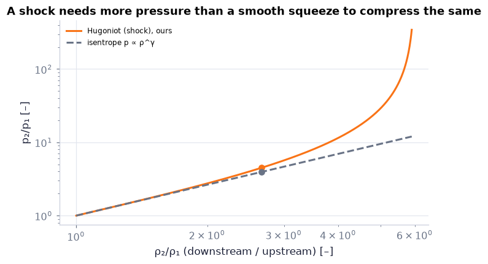

```
4.5010501050105 3.9485007238561804
```

```python
R = np.linspace(1.0, 5.9, 300)                               # density ratios rho2/rho1 up to just below the limit 6
fig, ax = plt.subplots(figsize=(6.2, 3.8))                   # one panel
ax.loglog(R, GD.hugoniot_pressure_ratio(R), color=COLORS["orange"], lw=2, label="Hugoniot (shock), ours")   # pressure after a shock
ax.loglog(R, R**1.4, color=COLORS["muted"], ls="--", label="isentrope p ∝ ρ^γ")   # pressure after a smooth squeeze
ax.plot(2.667, GD.hugoniot_pressure_ratio(2.667), "o", color=COLORS["orange"])   # the Mach 2 shock
ax.plot(2.667, 2.667**1.4, "o", color=COLORS["muted"])       # the same squeeze, isentropic
ax.set(xlabel="ρ₂/ρ₁ (downstream / upstream) [–]", ylabel="p₂/p₁ [–]",
       title="A shock needs more pressure than a smooth squeeze to compress the same")
ax.legend(fontsize=8); savefig(fig, "ch15", "c08_hugoniot"); plt.show()
print(GD.hugoniot_pressure_ratio(2.667), 2.667**1.4)         # 4.50 against 3.95
```

**What you see.** The pressure ratio needed for a given density ratio: by a shock (orange) and by a smooth isentropic squeeze (grey dashed), on logarithmic axes (each tick a factor 10). The dots are the Mach 2 shock: 4.50 against 3.95.

**How to read it.** The two curves touch at (1, 1) and stay together for weak compressions — they share value, slope and curvature there, so they agree through second order and part only at third order in the jump; that third-order gap is the entropy of D17 seen from another side. For strong ones the Hugoniot climbs steeply and runs to infinity at ρ₂/ρ₁ = 6.

**What would change if…** …γ were 5/3? The vertical asymptote would move to ρ₂/ρ₁ = 4.

```python
gs, ms, Rs = sp.symbols("gamma m R", positive=True)          # gamma; m = M1²; R = rho2/rho1
m_of_R = sp.solve(sp.Eq(Rs, (gs + 1) * ms / ((gs - 1) * ms + 2)), ms)[0]   # (15.41) solved for M1²
p_of_R = 1 + 2 * gs / (gs + 1) * (m_of_R - 1)                # put into (15.39)
print(sp.simplify(p_of_R - ((gs + 1) * Rs - (gs - 1)) / ((gs + 1) - (gs - 1) * Rs)))   # 0: the Hugoniot curve
```

```
0
```

📝 **Note.** **N63 [B]** The book's shock table is not reproduced; `GD.normal_shock_table` generates ours (a DataFrame, primer P361 in C05), checked against the public NACA Report 1135 rows. (Slip #10 concerns the last digit of one entry of the book's shock table.)

```python
print(GD.normal_shock_table(np.arange(1.0, 5.01, 0.5)).round(4).to_string(index=False))   # our table; row M1 = 2: 0.5774, 4.5, …, 0.7209
```

```
 M1     M2   p2/p1  rho2/rho1  T2/T1  p02/p01
1.0 1.0000  1.0000     1.0000 1.0000   1.0000
1.5 0.7011  2.4583     1.8621 1.3202   0.9298
2.0 0.5774  4.5000     2.6667 1.6875   0.7209
2.5 0.5130  7.1250     3.3333 2.1375   0.4990
3.0 0.4752 10.3333     3.8571 2.6790   0.3283
3.5 0.4512 14.1250     4.2609 3.3151   0.2129
4.0 0.4350 18.5000     4.5714 4.0469   0.1388
4.5 0.4236 23.4583     4.8119 4.8751   0.0917
5.0 0.4152 29.0000     5.0000 5.8000   0.0617
```

> 🔁 **Recap — The hydraulic jump `R16`** (Ch. 7 §7.6 (C11–C12)). $H_2/H_1=\tfrac12\left(-1+\sqrt{1+8Fr_1^2}\right)$ (7.81) — supercritical ($Fr_1>1$) water jumps to subcritical.

| Hydraulic jump (Ch. 7) | Normal shock |
| --- | --- |
| Froude number Fr | Mach number M |
| supercritical → subcritical | supersonic → subsonic |
| depth rises | density rises |
| mechanical energy lost | stagnation pressure lost |

```python
print(ch07.hydraulic_jump(1.0, Fr1=2.0)["ratio"])            # (7.81): H2/H1 = 2.372 for Fr1 = 2
```

```
2.3722813232690143
```

> ⚠️ **Common confusion:** (trap T21) The analogy is partial — the jump loses mechanical energy to heat; the shock conserves energy and loses $p_0$.

#### ✏️ Tiny example: what a Mach 2 shock costs

From C07: $p_2/p_1$ = 4.5, $\rho_2/\rho_1$ = 2.667.

1. $\dfrac{S_2-S_1}{C_v}=\ln\left[\dfrac{p_2}{p_1}\left(\dfrac{\rho_1}{\rho_2}\right)^{\gamma}\right]$ (15.43): $(S_2-S_1)/C_v=\ln[4.5\times(1/2.667)^{1.4}]=\ln(4.5\times0.2533)=\ln1.140$ = **0.131**.
2. In units of R: 0.131/(γ − 1) = 0.327.
3. Stagnation pressure kept: $e^{-0.327}$ = **0.721** — 28 % lost.
4. Cross-check with $\dfrac{p_{02}}{p_{01}}=\left[\dfrac{(\gamma+1)M_1^2}{(\gamma-1)M_1^2+2}\right]^{\gamma/(\gamma-1)}\left[\dfrac{\gamma+1}{2\gamma M_1^2-(\gamma-1)}\right]^{1/(\gamma-1)}$ (ours): (2.667)^3.5 × (2.4/10.8)^2.5 = 30.97 × 0.02328 = 0.721 ✓.
5. $A^*$ behind the shock is 1/0.721 = 1.387 times larger.

```python
print(GD.normal_shock_entropy(2.0), GD.normal_shock_stagnation_pressure_ratio(2.0), np.exp(-0.13091 / 0.4))   # 0.1309, 0.7209, 0.7209
```

```
0.13091644255985757 0.7208738614847449 0.7208854722607545
```

**What does the code above do?**

Three numbers: the entropy jump, the stagnation-pressure ratio from $\dfrac{p_{02}}{p_{01}}=\left[\dfrac{(\gamma+1)M_1^2}{(\gamma-1)M_1^2+2}\right]^{\gamma/(\gamma-1)}\left[\dfrac{\gamma+1}{2\gamma M_1^2-(\gamma-1)}\right]^{1/(\gamma-1)}$ (ours), and $e^{-\Delta S/R}$ — the last two agree, as D18 step 6 says they must.

```python
T1, p1 = 288.15, 101325.0                                    # an upstream state [K, Pa]
dS = TH.perfect_gas_entropy_change_p(T1, p1, T1 * s["T_ratio"], p1 * s["p_ratio"], cp=air.cp, R=air.R)   # (15.1, entropy line) [J/(kg K)]
p0_ratio = s["p_ratio"] * GD.stagnation_pressure_ratio(s["M2"]) / GD.stagnation_pressure_ratio(2.0)   # D18 step 1: chain of three ratios
assert np.allclose(dS / air.cv, GD.normal_shock_entropy(2.0))                     # route 1: entropy from the Ch. 1 formula
assert np.allclose([p0_ratio, np.exp(-dS / air.R)], GD.normal_shock_stagnation_pressure_ratio(2.0))   # routes 2 and 3
print(f"dS = {dS:.2f} J/(kg K); p02/p01 = {p0_ratio:.4f} = exp(-dS/R) = {np.exp(-dS/air.R):.4f}")
```

```
dS = 93.95 J/(kg K); p02/p01 = 0.7209 = exp(-dS/R) = 0.7209
```

**From scratch — three routes, one number.** The entropy change from the Ch. 1 formula (`TH`), the stagnation-pressure ratio as a chain of three static/stagnation ratios, and $e^{-\Delta S/R}$: all equal the library's.

```python
M1 = np.linspace(0.6, 5.0, 150)                              # upstream Mach numbers
gammas = [1.1, 1.15, 1.2, 1.25, 1.3, 1.35, 1.4, 1.45, 1.5, 1.55, 1.6, 5 / 3]                         # gamma slider
fig = slider_figure(lambda g: {"(S₂ − S₁)/C_v, (15.43)": (M1, GD.normal_shock_entropy(M1, g)),   # entropy jump
                               "p₀₂/p₀₁ (ours)": (M1, GD.normal_shock_stagnation_pressure_ratio(M1, g)),   # surviving stagnation pressure
                               "T₀₂/T₀₁ = 1 (conserved)": (M1, np.ones_like(M1)),   # flat: energy is conserved
                               "M₁ = 1 (left: forbidden)": ([1.0, 1.0], [-0.3, 1.6])},   # a vertical marker
                    "γ", gammas, xlabel="upstream Mach number M₁ [–]", ylabel="[–]",   # slider over gamma
                    title="What a shock costs: entropy up, stagnation pressure down, T₀ untouched", yrange=[-0.3, 1.6],   # the message
                    active=gammas.index(1.4))                # open on air, gamma = 1.4
fig.show()   # display
```

[interactive chart not shown]

**Figure F5b.** Slider: γ. The flat line is the conserved stagnation temperature.

**What you see.** The entropy jump, the surviving fraction of stagnation pressure and the (flat) stagnation-temperature ratio against $M_1$, with the line $M_1=1$.

**How to read it.** Right of the line the entropy rises and the stagnation pressure falls together: at $M_1$ = 2 for air, 28 % lost; at 3, 67 %. Left of it the "shock" would *gain* stagnation pressure — forbidden. $T_0$ never moves: energy is conserved.

**What would change if…** …you wanted to slow a Mach 3 stream with small losses? Do it in steps (oblique shocks, C14): several weak shocks lose far less than one strong one, because the loss starts at third order.

#### 🎮 Interactive: Why can a shock only compress?

**Why interactive rather than a static figure:** you drag the upstream Mach number below 1: the three flux bars stay perfectly balanced while the entropy bar goes negative — you find the second law's veto by experiment rather than by reading it.

Start with the **Walkthrough**; the **Explain** tab works every number out with your settings, and the **Derivation** tab (where there is one) steps through the same derivation as above. Station 1 is upstream (ahead of the shock), station 2 downstream; every jump is written downstream over upstream.

**What to try:**

- Drag $M_1$ from 2 down to 0.7: which bar breaks?
- Sit at $M_1$ = 1.1: how much stagnation pressure is lost?
- Switch to the frame of the still gas: which numbers changed, which did not?

```python
show_viz("ch15", "normal_shock_jump")   # full-width explainer; ⤢ Full screen for more room
```

🎮 Interactive 3/9 Why can a shock only compress? Open alone ↗

[interactive chart not shown]

> 🔁 **Recap — Viscosity sets the thickness, not the loss `R18`** (Ch. 12 §12.7 (C07)). In turbulence the dissipation rate is set by the large scales, not by the viscosity. Likewise the entropy rise of a shock is fixed by the jump conditions; viscosity and conduction only set how thick the layer is (N65, N69 below).

📝 **Note.** **N65 [B]** **Thickness estimate:** a Reynolds number of order one on the velocity jump, $(u_1-u_2)\,\delta_{\text{sh}}/\nu_{\text{visc}}\sim1$ (δ is a thickness here, a deflection angle in §15.9 — trap T5).

```python
lam = ch01.mean_free_path_air(288.15)                        # mean free path of sea-level air [m]
for M in (2.0, 1.2):                                         # a strong and a weak shock
    u1 = M * c0; u2 = u1 / GD.normal_shock_density_ratio(M)  # speeds before and after [m/s]
    d = ch15.shock_thickness_estimate(u1 - u2, 1.46e-5)      # delta ~ nu/(u1 - u2) [m]
    print(f"M1 = {M}: du = {u1-u2:.0f} m/s, thickness ~ {d:.1e} m = {d/lam:.2f} mean free paths")
```

```
M1 = 2.0: du = 425 m/s, thickness ~ 3.4e-08 m = 0.54 mean free paths
M1 = 1.2: du = 104 m/s, thickness ~ 1.4e-07 m = 2.20 mean free paths
```

**What does the code above do?**

At $M_1$ = 2 the estimate is 3.4 × 10⁻⁸ m, at 1.2 about 1.4 × 10⁻⁷ m — of the order of the mean free path (≈ 7 × 10⁻⁸ m). The continuum model is at its limit (the Knudsen number of Ch. 1 C06 is of order one). Our numbers, not the book's.

> 🔁 **Recap — The equations inside a shock `R19`** (Ch. 4 (C08, C10; N51 bulk viscosity)). Steady, one-dimensional mass, momentum and energy with viscosity and conduction: $\dfrac{d(\rho u)}{dx}=0$, $\rho u\dfrac{du}{dx}+\dfrac{dp}{dx}=\dfrac{d}{dx}\left(\mu''\dfrac{du}{dx}\right)$, $\rho u\dfrac{dh}{dx}-u\dfrac{dp}{dx}=\mu''\left(\dfrac{du}{dx}\right)^2+\dfrac{d}{dx}\left(k\dfrac{dT}{dx}\right)$ with $\mu''=\tfrac43\mu+\mu_v$ (reductions of the Ch. 4 equations).

📝 **Note.** **N66 [B]** Each equation integrates once (result given, not derived): $\rho u=m$, $mu+p=\mu''\dfrac{du}{dx}+mV$, $m\left(h+\tfrac12u^2\right)=\mu''u\dfrac{du}{dx}+k\dfrac{dT}{dx}+mI$. The three constants of integration are fixed by the upstream state: **m** $=\rho_1u_1$ is the mass flux [kg/(m² s)], **V** $=u_1+p_1/m$ is a speed [m/s] (momentum flux over mass flux), and **I** $=C_pT_1+\tfrac12u_1^2$ is the total enthalpy [J/kg]. Far upstream and downstream the gradients vanish and these *are* $\rho_1u_1=\rho_2u_2$ (15.35), $p_1-p_2=-\rho_1u_1^2+\rho_2u_2^2$ (15.36), $h_1+\tfrac12u_1^2=h_2+\tfrac12u_2^2$ (15.37): the jump conditions do not care what happens inside.

📝 **Note.** **N67 [B]** With $Pr''\equiv\mu''C_p/k=1$ the total enthalpy $C_pT+\tfrac12u^2=I$ at every point inside the shock (Becker; result given). Trap T20: $Pr''$ is built on $\mu''$ — about 0.95 for air with $\mu_v=0$.

📝 **Note.** **N68 [B]** One first-order equation remains for $U=u/V$; its two rest points are the end states, (ours) $U_1=\gamma M_1^2/(\gamma M_1^2+1)$ and the same with $M_2$; $U_1+U_2=2\gamma/(\gamma+1)$. (Slip #7: the book factorises before dividing by $V^2$.)

```python
sss = ch15.shock_structure_sympy()                           # the reductions and their first integrals, by sympy
print(sss["structure_equation"])                             # residual of the reduction to one equation for U = u/V: 0 = exact
sc = ch15.shock_structure_constants(2.0, 288.15, 101325.0, air)   # the integration constants for a Mach 2 shock in sea-level air
print({k: round(float(sc[k]), 4) for k in ("m", "V", "I", "U1", "U2")})   # m [kg/(m² s)], V [m/s], I [J/kg], U1, U2 [–]
```

```
0
{'m': 833.7245, 'V': 802.1175, 'I': 521094.7823, 'U1': 0.8485, 'U2': 0.3182}
```

**What does the code above do?**

1. `ch15.shock_structure_sympy()` redoes the reductions of N66–N68 symbolically and returns each as an expression that must vanish. The printed **0** is the residual of the last one — the single first-order equation for $U=u/V$: sympy confirms the reduction leaves exactly nothing over.
2. `ch15.shock_structure_constants` evaluates the three constants of N66 for a Mach 2 shock in sea-level air: m = 833.7 kg/(m² s), V = 802.1 m/s, I = 521 095 J/kg, and the two end states of N68, $U_1$ = 0.8485 and $U_2$ = 0.3182 (28/33 and 7/22).

```python
U1, U2 = ch15.becker_shock_roots(2.0)                        # the two end states of the scaled speed for M1 = 2
print(f"U1 = {U1:.4f}, U2 = {U2:.4f}, U1 + U2 = {U1 + U2:.4f}")   # 4 decimals are plenty to read the roots
assert abs(U1 - 28 / 33) < 1e-12 and abs(U2 - 7 / 22) < 1e-12   # the exact roots 28/33 and 7/22
assert abs(U1 + U2 - 2 * 1.4 / 2.4) < 1e-12                       # their sum is 2 gamma/(gamma + 1) = 1.1667
```

```
U1 = 0.8485, U2 = 0.3182, U1 + U2 = 1.1667
```

📝 **Note.** **N69 [B]** The profile $\dfrac{U_1\ln(U_1-U)-U_2\ln(U-U_2)}{U_1-U_2}=\dfrac{\gamma+1}{2\gamma}\,\eta$ (unnumbered, §15.6), inverted numerically, for three shock strengths. **N70 [B]** Our figure uses our own Mach numbers; for γ = 1.4, $M_1$ = 2 the plateaus are 28/33 and 7/22 (slip #8 concerns a caption of the book's figure; the comparison is a private test).

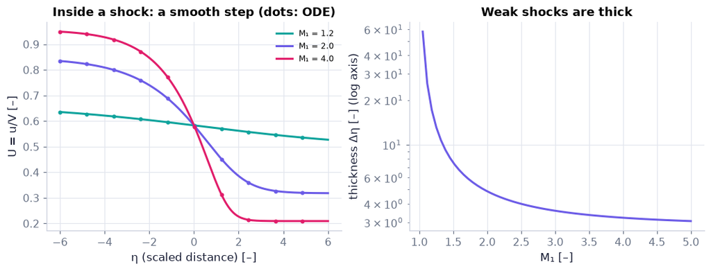

```python
eta = np.linspace(-6.0, 6.0, 200)                            # shock coordinate (scaled distance; origin arbitrary — trap T20)
fig, (a, b) = plt.subplots(1, 2, figsize=(9.6, 3.6))         # profiles; thickness
for M, col in ((1.2, COLORS["teal"]), (2.0, COLORS["accent"]), (4.0, COLORS["rose"])):
    U = ch15.becker_shock_profile(eta, M)                     # the implicit profile solved for U at each eta (brentq per point)
    a.plot(eta, U, color=col, label=f"M₁ = {M}")              # scaled speed through the shock
    sol = solve_ivp(lambda e, y: ch15.becker_shock_ode(e, y, M), (eta[0], eta[-1]), [U[0]],
                    t_eval=eta[::20], rtol=1e-9, atol=1e-12)  # the same profile by integrating the ODE (independent check)
    a.plot(sol.t, sol.y[0], "o", ms=3, color=col)             # dots on the curve
a.set(xlabel="η (scaled distance) [–]", ylabel="U = u/V [–]", title="Inside a shock: a smooth step (dots: ODE)")
a.legend(fontsize=8)
Ms = np.linspace(1.05, 5.0, 60)                              # Mach numbers
b.semilogy(Ms, ch15.becker_shock_thickness(Ms), color=COLORS["accent"])   # maximum-slope thickness (ours)
b.set(xlabel="M₁ [–]", ylabel="thickness Δη [–] (log axis)", title="Weak shocks are thick")
savefig(fig, "ch15", "c08_becker"); plt.show()
```

**What you see.** Left: the scaled speed $U=u/V$ through a shock for $M_1$ = 1.2, 2 and 4 (curves from the implicit relation $\dfrac{U_1\ln(U_1-U)-U_2\ln(U-U_2)}{U_1-U_2}=\dfrac{\gamma+1}{2\gamma}\,\eta$ (unnumbered, §15.6), dots from integrating the differential equation with `solve_ivp`). Right: the thickness of the step against $M_1$ on a logarithmic axis.

**How to read it.** Each profile goes smoothly from the upstream plateau $U_1$ to the downstream plateau $U_2$ (for $M_1$ = 1.2 the step is wider than the window); for $M_1$ = 2 the plateaus are 28/33 = 0.848 and 7/22 = 0.318. The dots lie on the curves: two routes, one profile. The thickness grows without bound as $M_1\to1$ — a weak shock is a gentle ramp.

**What would change if…** …$Pr''$ were not 1? The energy integral would no longer be exact and the profile would need a second equation; for $Pr''\to0$ a thinner shock appears inside the first (N71).

📝 **Note.** **N71 [C]** For $Pr''\to0$ a second, thinner shock sits inside the first; see the literature the book cites — not developed in the book or here.

**What would change if…** …you put this jump inside a nozzle? Then the back pressure decides where it stands. First the simpler nozzle — C09.

## 15.7 Operation of Nozzles at Different Back Pressures

**What is this section about?** A reservoir, a nozzle and a tank whose pressure you lower. The book describes what happens in words and figures; the section has no numbered equation, so **every formula here is ours**, built from the earlier sections.

### 🧩 Choking: $\dfrac{p^*}{p_0}=\left(\dfrac{2}{\gamma+1}\right)^{\gamma/(\gamma-1)}$ (ours) `C09`

*The question:* If you keep lowering the pressure downstream of a nozzle, does more and more gas flow?

#### The problem in plain words

Let the air out of a bicycle tyre. Open the valve a little into a room at lower pressure and air flows; lower the room pressure and more flows. Intuition says: lower it to vacuum and the flow keeps growing. It does not. Once the pressure outside is about half the pressure inside, the air at the exit moves at exactly the speed of sound — and news of any further drop outside cannot travel upstream against it. The nozzle is **choked**.

#### The idea

```
reservoir p₀, T₀ ══⟩ exit │ tank p_B
  exit subsonic:  exit pressure = p_B        (news of p_B gets in)
  exit sonic:     exit pressure = p* ≥ p_B   (news cannot get in)
```

📝 **Note.** **N72 [B]** Three pressures: the supply (stagnation) pressure $p_0$, the back pressure $p_B$ in the tank, and the exit-plane pressure. **The exit pressure equals the back pressure if and only if the exit flow is subsonic** — the range of influence of C02 (N20) put to work.

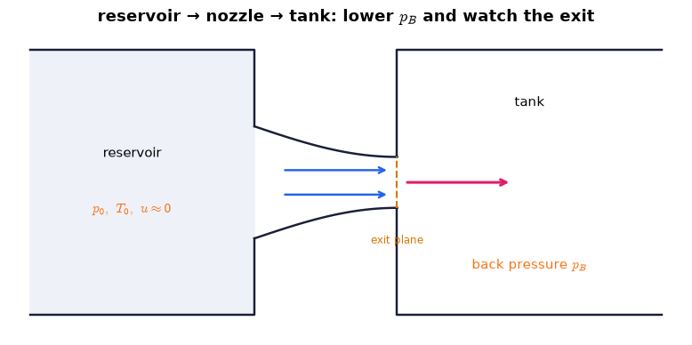

```python
fig = draw_reservoir_nozzle_tank()                           # our sketch: reservoir (p0, T0), convergent nozzle, tank at p_B
plt.show()                                                   # display it
```

**What you see.** A large reservoir at the stagnation state, a convergent nozzle, and a tank held at the back pressure $p_B$.

**How to read it.** The reservoir is so large that the gas in it is at rest: it *is* the stagnation state (N34). Everything about the nozzle flow is a ratio to $p_0$ and $T_0$; the only thing you control is $p_B$.

**What would change if…** …the reservoir were small? Its pressure would fall as it emptied; each instant would still look like this picture with a lower $p_0$ (a quasi-steady emptying).

#### 🧮 Derivation — Mass flow through a convergent nozzle against back pressure `D19` ★★ (Eq. ours: $\dfrac{\dot m\sqrt{RT_0}}{p_0A}=\sqrt\gamma\,M\left(1+\dfrac{\gamma-1}{2}M^2\right)^{-(\gamma+1)/(2(\gamma-1))}$)

**What we want to show.** Compute how much gas a convergent nozzle passes as the back pressure is lowered — and show where it stops rising.

**Assumptions.** Isentropic from the reservoir to the exit; quasi-one-dimensional.

**The plan.**

1. Write the exit mass flux with the exit Mach number.
2. Get that Mach number from the back pressure while the exit is subsonic.
3. Find where it reaches 1.
4. Argue what happens below.

**Tools we use** (each explained before this point): D08, D11 · piecewise functions (P46 reminder)

**We start from**

$$ \begin{array}{l}\rho uA=\dot m=\text{const.}\ \text{(15.18) at the exit plane, with}\ \dfrac{T_0}{T}=1+\dfrac{\gamma-1}{2}M^2\ \text{(15.28),} \\ \dfrac{p_0}{p}=\left[1+\dfrac{\gamma-1}{2}M^2\right]^{\gamma/(\gamma-1)}\ \text{(15.29) and the range of influence (N20).}\end{array} $$

**Step 1 of 7 — Write the exit mass flow.**

$$ \dot m=\rho_eu_eA_e $$

- *Why we can do this:* $\rho uA=\dot m=\text{const.}$ (15.18) at the exit plane.
- *In words:* Mass flow = exit density × exit speed × exit area.

**Step 2 of 7 — Express ρu with pressure, Mach number and temperature.**

$$ \rho u=\dfrac{p}{RT}\,M\sqrt{\gamma RT}=pM\sqrt{\dfrac{\gamma}{RT}} $$

- *Why we can do this:* Gas law and $u=Mc$ with $c=\sqrt{\gamma RT}$.
- *In words:* Mass flux is pressure times Mach number over the square root of temperature.

**Step 3 of 7 — Insert the stagnation ratios.**

$$ \dfrac{\dot m\sqrt{RT_0}}{p_0A_e}=\sqrt\gamma\,M_e\left(1+\dfrac{\gamma-1}{2}M_e^2\right)^{-(\gamma+1)/(2(\gamma-1))}\ \text{(ours)} $$

- *Why we can do this:* $p=p_0\Theta^{-\gamma/(\gamma-1)}$ and $T=T_0/\Theta$: the exponent is $-\dfrac{\gamma}{\gamma-1}+\dfrac12$.
- *In words:* A dimensionless mass flow that depends only on the exit Mach number.

**Step 4 of 7 — Tie the exit Mach number to the back pressure.**

$$ M_e^2=\dfrac{2}{\gamma-1}\left[\left(\dfrac{p_B}{p_0}\right)^{-(\gamma-1)/\gamma}-1\right]\quad(\text{exit subsonic}) $$

- *Why we can do this:* A subsonic exit can hear the tank, so its pressure equals $p_B$; then invert $\dfrac{p_0}{p}=\left[1+\dfrac{\gamma-1}{2}M^2\right]^{\gamma/(\gamma-1)}$ (15.29).
- *In words:* Lower back pressure, faster exit.

**Step 5 of 7 — Find where the exit turns sonic.**

$$ \dfrac{p_B}{p_0}=\dfrac{p^*}{p_0}=\left(\dfrac{2}{\gamma+1}\right)^{\gamma/(\gamma-1)}\ \text{(ours)} $$

- *Why we can do this:* Put $M_e=1$ in $\dfrac{p_0}{p}=\left[1+\dfrac{\gamma-1}{2}M^2\right]^{\gamma/(\gamma-1)}$ (15.29): the sonic ratio of D11.
- *In words:* For air, when the back pressure is 52.8 % of the supply.

**Step 6 of 7 — Below that, freeze the exit.**

$$ M_e=1,\quad p_e=p^*>p_B,\quad\dot m=\dot m_{\max} $$

- *Why we can do this:* A converging duct cannot take the flow beyond Mach 1 (D12), and with the exit sonic no pressure signal travels upstream (N20): nothing inside can change.
- *In words:* The nozzle is choked: the exit pressure stays at $p^*$ and the mass flow at its maximum.

**Step 7 of 7 — Check how the curve meets its plateau.**

$$ \left.\dfrac{d\dot m}{dp_B}\right\rvert_{M_e=1}=0 $$

- *Why we can do this:* By D11 step 7 the flux function has its maximum at M = 1, so its slope with respect to $M_e$ — and hence $p_B$ — vanishes there.
- *In words:* The mass-flow curve flattens smoothly into the plateau; there is no corner.

**Result**

$$ \begin{array}{l}\dfrac{\dot m\sqrt{RT_0}}{p_0A}=\sqrt\gamma\,M\left(1+\dfrac{\gamma-1}{2}M^2\right)^{-(\gamma+1)/(2(\gamma-1))}\ \text{(ours) at the exit with}\ M_e\ \text{from step 4} \\ \text{for}\ p_B/p_0\ge\ \dfrac{p^*}{p_0}=\left(\dfrac{2}{\gamma+1}\right)^{\gamma/(\gamma-1)}\ \text{(ours), and} \\ \dot m_{\max}=p_0A^*\sqrt{\dfrac{\gamma}{RT_0}}\left(\dfrac{2}{\gamma+1}\right)^{(\gamma+1)/(2(\gamma-1))}\ \text{(ours) below.}\end{array} $$

**What it means.** The back pressure controls the flow only while news of it can reach the throat. **Fails when:** the nozzle has a diverging part (C10) or losses.

**Check it.** Units — the left side of step 3 is a number ✓. Limits — $p_B=p_0$: no flow; $p_B\to0$: still $\dot m_{\max}$. Number — $p_B/p_0$ = 0.8: $M_e$ = 0.574, flux 0.561 (82 % of 0.685). Code — `GD.mass_flow_vs_back_pressure`.

> ⚠️ **Common confusion (traps in `D19`):** The exit pressure equals $p_B$ only while the exit is subsonic; "choked" is a ceiling the supply can still raise (trap T10).

#### ✏️ Tiny example: our nozzle, three back pressures

$p_0$ = 500 kPa, $T_0$ = 400 K, exit area 10 cm², γ = 1.4; critical ratio $\dfrac{p^*}{p_0}=\left(\dfrac{2}{\gamma+1}\right)^{\gamma/(\gamma-1)}$ (ours) = 0.528.

1. $p_B$ = 400 kPa (ratio 0.8 > 0.528: not choked): invert $\dfrac{p_0}{p}=\left[1+\dfrac{\gamma-1}{2}M^2\right]^{\gamma/(\gamma-1)}$ (15.29): $M_e^2$ = 5 × (0.8^(−0.2857) − 1) = 5 × 0.0658 = 0.329, $M_e$ = 0.574.
2. Flux function $\dfrac{\dot m\sqrt{RT_0}}{p_0A}=\sqrt\gamma\,M\left(1+\dfrac{\gamma-1}{2}M^2\right)^{-(\gamma+1)/(2(\gamma-1))}$ (ours) at 0.574: 1.183 × 0.574/1.0658³ = 0.561 — that is 82 % of its maximum 0.685.
3. ṁ = 0.561 × 500 000 × 0.001/√(287 × 400) = 0.83 kg/s.
4. $p_B$ = 264 kPa (ratio 0.528): $M_e$ = 1, ṁ = 1.01 kg/s.
5. $p_B$ = 100 kPa: still $M_e$ = 1 and ṁ = 1.01 kg/s; the exit pressure stays at 264 kPa and the jet finishes expanding outside.

```python
print(GD.critical_pressure_ratio())                          # p*/p0 = 0.5283 for gamma = 1.4
pBs = (4.75e5, 4.0e5, 3.0e5, 2.6414e5, 1.0e5)                # five back pressures [Pa]
rows = [GD.convergent_nozzle(noz["p0"], noz["T0"], pB, noz["A_t"], air) for pB in pBs]   # D19 for each
tab = pd.DataFrame(rows, index=[f"p_B = {pB/1e3:.0f} kPa" for pB in pBs])[["M_exit", "p_exit", "mdot", "choked"]]
print(tab.round(3))                                          # M_exit 0.272 … 1; mdot 0.454 … 1.010 kg/s; choked from 264 kPa down
print(GD.mass_flow_vs_back_pressure(0.8))                    # dimensionless: mdot sqrt(R T0)/(p0 A) = 0.5607, 82 % of the choked value
```

```
0.5282817877171742
               M_exit      p_exit   mdot  choked
p_B = 475 kPa   0.272  475000.000  0.454   False
p_B = 400 kPa   0.574  400000.000  0.827   False
p_B = 300 kPa   0.886  300000.000  0.999   False
p_B = 264 kPa   1.000  264140.894  1.010    True
p_B = 100 kPa   1.000  264140.894  1.010    True
{'mdot': 0.5606610191923972, 'M_exit': 0.573722747792524, 'p_exit_over_p0': 0.8, 'choked': False, 'mdot_over_choked': 0.8188042391957623}
```

**What does the code above do?**

1. The critical ratio $\dfrac{p^*}{p_0}=\left(\dfrac{2}{\gamma+1}\right)^{\gamma/(\gamma-1)}$ (ours) is 0.5283: for our 5 bar supply, 264 kPa.
2. For each back pressure `GD.convergent_nozzle` returns the exit Mach number, exit pressure, mass flow and whether the nozzle is choked. Above 264 kPa the exit pressure *is* the back pressure; below it the exit pressure sticks at 264 kPa.
3. The mass flow rises from 0.45 kg/s (475 kPa) to 1.010 kg/s at 264 kPa — and not a gram more at 100 kPa.
4. `GD.mass_flow_vs_back_pressure` gives the same in dimensionless form: 0.5607 at $p_B/p_0$ = 0.8.

> 🔁 **Tools from earlier chapters used in this block** (one line each; the full primers are in the chapters named)
- **piecewise functions with `np.where` / `if`** — a quantity given by different formulas in different ranges is computed with an `if` (one value) or `np.where` (arrays); here the exit of a convergent nozzle is subsonic above the critical back pressure and sonic below it. *(Ch. 1, P46)*

```python
g, R, p0, T0, A = 1.4, air.R, noz["p0"], noz["T0"], noz["A_t"]   # gas and nozzle
crit = (2 / (g + 1))**(g / (g - 1))                         # p*/p0 (ours)
pB_list = np.linspace(0.05, 0.99, 50) * p0                  # 50 back pressures [Pa]
mdot_mine = []                                               # filled in the loop
for pB in pB_list:                                           # the piecewise law of D19
    if pB / p0 > crit:                                       # subsonic exit: it feels the tank
        M = np.sqrt(2 / (g - 1) * ((pB / p0)**(-(g - 1) / g) - 1))   # D19 step 4: invert (15.29)
    else:                                                    # choked: the exit is sonic
        M = 1.0                                              # D19 step 6
    mdot_mine.append(np.sqrt(g) * M * (1 + 0.5 * (g - 1) * M * M)**(-(g + 1) / (2 * (g - 1))) * p0 * A / np.sqrt(R * T0))   # D19 step 3
assert np.allclose(mdot_mine, [GD.convergent_nozzle(p0, T0, pB, A, air)["mdot"] for pB in pB_list])   # same as the library
print(f"{len(pB_list)} back pressures: from scratch = GD.convergent_nozzle; plateau {max(mdot_mine):.4f} kg/s")
```

```
50 back pressures: from scratch = GD.convergent_nozzle; plateau 1.0104 kg/s
```

**From scratch.** An `if` decides the regime (subsonic exit or choked); then D19 step 3 gives the mass flow. Fifty back pressures, the same numbers as the library.

📝 **Note.** **N73 [B]** The pressure along the nozzle for six back pressures, and the mass flow against the back pressure.

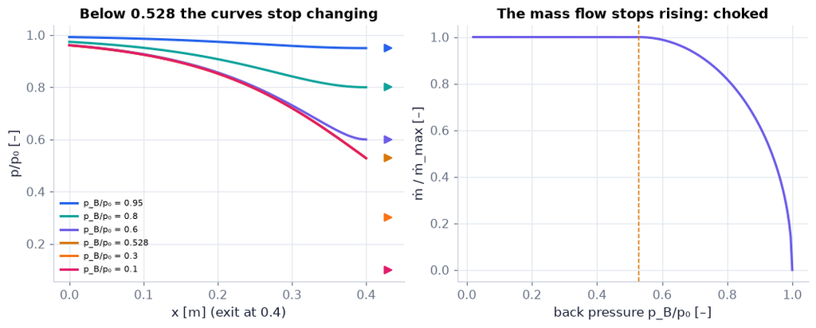

```python
x = np.linspace(0.0, 0.4, 81)                                # the converging half of laval_area: inlet at 0, exit (throat) at 0.4
fig, (a, b) = plt.subplots(1, 2, figsize=(9.6, 3.8))         # pressure along the nozzle; mass flow against back pressure
for r_, col in zip((0.95, 0.8, 0.6, 0.528, 0.3, 0.1), (COLORS["blue"], COLORS["teal"], COLORS["accent"], COLORS["amber"], COLORS["orange"], COLORS["rose"])):
    Me = GD.convergent_nozzle(1.0, 300.0, r_, 1.0, air)["M_exit"]   # exit Mach number for this back pressure (dimensionless supply)
    if Me < 0.9999:                                          # subsonic exit: sonic area below the exit area
        sol = GD.nozzle_isentropic(x, GD.laval_area, branch="subsonic", A_star=1.0 / GD.area_ratio(Me))
    else:                                                    # choked: sonic at the exit
        sol = GD.nozzle_isentropic(x, GD.laval_area, branch="transonic")
    a.plot(x, sol["p_over_p0"], color=col, label=f"p_B/p₀ = {r_}")   # pressure along the nozzle
    a.plot(0.43, r_, ">", color=col)                         # the tank pressure, just outside the exit
a.set(xlabel="x [m] (exit at 0.4)", ylabel="p/p₀ [–]", title="Below 0.528 the curves stop changing")
a.legend(fontsize=7)
rr = np.linspace(0.02, 1.0, 200)                             # back-pressure ratios
b.plot(rr, [GD.mass_flow_vs_back_pressure(v)["mdot_over_choked"] for v in rr], color=COLORS["accent"])   # mdot / mdot_max
b.axvline(GD.critical_pressure_ratio(), color=COLORS["amber"], ls="--", lw=1)   # the critical ratio
b.set(xlabel="back pressure p_B/p₀ [–]", ylabel="ṁ / ṁ_max [–]", title="The mass flow stops rising: choked")
savefig(fig, "ch15", "c09_convergent"); plt.show()
```

**What you see.** Left: the pressure along a convergent nozzle for six back-pressure ratios (triangles: the tank pressure just outside the exit). Right: the mass flow, as a fraction of its maximum, against the back-pressure ratio.

**How to read it.** For 0.95, 0.8 and 0.6 each curve ends exactly at its triangle: the exit pressure is the back pressure. For 0.528, 0.3 and 0.1 the three curves lie on top of one another and end at 0.528 — above the triangles: the gas leaves at a higher pressure than the tank's and finishes expanding outside. On the right the curve meets its plateau smoothly (D19 step 7).

**What would change if…** …the gas were monatomic (γ = 5/3)? The critical ratio would be 0.487: it chokes a little later.

📝 **Note.** **N74 [B]** **Choking:** with the exit sonic the flow upstream no longer responds to $p_B$, and $\dot m=\dot m_{\max}$ of $\dot m_{\max}=p_0A^*\sqrt{\dfrac{\gamma}{RT_0}}\left(\dfrac{2}{\gamma+1}\right)^{(\gamma+1)/(2(\gamma-1))}$ (ours).

> ⚠️ **Common confusion** (trap T10): "choked" does not mean the flow cannot be raised — it is the most the throat passes *for this supply*. Raise $p_0$ or lower $T_0$ and it rises ($\dot m\propto p_0/\sqrt{T_0}$).

```python
def by_p0(p0):                                               # mass flow against back pressure for one supply pressure
    pB = np.linspace(0.01, 1.0, 60) * p0                     # back pressures up to the supply [Pa]
    m = [GD.convergent_nozzle(p0, noz["T0"], v, noz["A_t"], air)["mdot"] for v in pB]   # D19 at each back pressure
    return {"ṁ [kg/s]": (pB / 1e3, m)}                       # x in kPa
fig_a = slider_figure(by_p0, "p₀", np.linspace(2e5, 1e6, 17), unit="Pa", xlabel="back pressure p_B [kPa]",   # slider over the supply pressure
                      ylabel="mass flow ṁ [kg/s]", title="Raise the supply: the plateau rises (choked ≠ capped)")   # the message
fig_a.show()   # display
def by_T0(T0):                                               # the same for one supply temperature
    pB = np.linspace(0.01, 1.0, 60) * noz["p0"]
    m = [GD.convergent_nozzle(noz["p0"], T0, v, noz["A_t"], air)["mdot"] for v in pB]   # D19 at each back pressure
    return {"ṁ [kg/s]": (pB / 1e3, m)}   # x in kPa
fig_b = slider_figure(by_T0, "T₀", np.linspace(300.0, 1200.0, 19), unit="K", xlabel="back pressure p_B [kPa]",   # slider over the supply temperature
                      ylabel="mass flow ṁ [kg/s]", title="Heat the supply: the plateau falls like 1/√T₀")   # the message
fig_b.show()   # display
```

[interactive chart not shown]

**Figures F6.** Two slider figures with dimensional axes: the supply pressure (200 … 1000 kPa) and the supply temperature (300 … 1200 K).

**What you see.** The mass flow of our 10 cm² nozzle against the back pressure, for the supply pressure (top) and temperature (bottom) on the sliders.

**How to read it.** Each curve rises from zero at $p_B=p_0$ and flattens at $p_B=0.528\,p_0$. Doubling $p_0$ doubles the plateau and moves the kink to the right; quadrupling $T_0$ halves the plateau. The throat is a flow meter that reads the supply.

**What would change if…** …the throat area were doubled? Every curve would double: ṁ ∝ $p_0A^*/\sqrt{T_0}$.

**What would change if…** …you added a diverging part after the throat? Then below the choking pressure the flow has somewhere to go: supersonic. And the back pressure gets a new job. C10.

### 🧩 The Laval nozzle: three dividing back pressures $\dfrac{p_b}{p_0}=\left.\dfrac{p}{p_0}\right\rvert_{M_{\text{sub}}(A_e/A_t)},\ \dfrac{p_f}{p_0}=\left.\dfrac{p}{p_0}\right\rvert_{M_{\text{sup}}(A_e/A_t)},\ \dfrac{p_d}{p_0}=\dfrac{p_f}{p_0}\left.\dfrac{p_2}{p_1}\right\rvert_{M_{\text{sup}}}$ (ours) `C10`

*The question:* Once the throat is sonic, what is left for the back pressure to decide?

#### The problem in plain words

A rocket nozzle on the test stand at sea level, then the same nozzle at altitude. The chamber is the same, the throat is the same, the mass flow is the same — but the exhaust looks different, and at start-up a sharp front can be seen standing inside the bell. With the throat sonic the back pressure cannot change the mass flow. All it can do is place a normal shock somewhere in the diverging part — or, when it is low enough, leave the inside of the nozzle alone and reshape the jet outside.

#### The idea

The ladder of seven conditions for our nozzle ($A_e/A_t$ = 2):

| Name | $p_B/p_0$ | What you see |
| --- | --- | --- |
| subsonic throughout | > 0.937 | a venturi; the mass flow still depends on $p_B$ |
| just choked | = 0.937 = $p_b$ | sonic at the throat only |
| shock in the diverging part | 0.513 … 0.937 | a normal shock inside the bell; subsonic exit |
| shock at the exit | = 0.513 = $p_d$ | the shock sits in the exit plane |
| over-expanded | 0.094 … 0.513 | supersonic exit; oblique shocks outside |
| design | = 0.094 = $p_f$ | supersonic exit at the back pressure: a clean jet |
| under-expanded | < 0.094 | supersonic exit; expansion fans outside |

> 📎 **Primer — nested root finding.** `P365` · Sometimes the function you want a root of itself needs a root-finder to evaluate. Here: "exit pressure for a shock at Mach $M_1$" needs the subsonic inverse of the area ratio; then we search $M_1$ so that this exit pressure equals the back pressure. One `brentq` inside another.

```python
from scipy.optimize import brentq
inner = lambda y: brentq(lambda x: x**3 + x - y, 0.0, 10.0)   # inner: solve x^3 + x = y for x
outer = brentq(lambda y: inner(y) - 1.5, 0.0, 100.0)          # outer: which y makes that x equal 1.5?
print(outer, 1.5**3 + 1.5)                                     # 4.875 both
```

```
4.875000000000001 4.875
```

#### 🧮 Derivation — The Laval nozzle: dividing back pressures and the place of the shock `D20` ★★ (Eq. ours: $\dfrac{p_B}{p_0}=\dfrac{p_{02}}{p_{01}}(M_1)\left.\dfrac{p}{p_0}\right\rvert_{M_{\text{sub}}\left(\frac{A_e}{A_t}\frac{p_{02}}{p_{01}}\right)}$)

**What we want to show.** For a convergent–divergent nozzle of given exit-to-throat area ratio, find the back pressures that separate its regimes, and where a shock stands for a back pressure in between.

**Assumptions.** Isentropic except across the shock; quasi-one-dimensional; a normal shock.

**The plan.**

1. Two isentropic solutions give $p_b$ and $p_f$.
2. a shock at the exit gives $p_d$.
3. For a shock inside: isentropic before, jump, isentropic after with a new sonic area, exit pressure = back pressure.

**Tools we use** (each explained before this point): a function with two inverses (primer P360) · nested root finding (primer P365) · D10, D13, D18

**We start from**

$$ \begin{array}{l}\dfrac{A}{A^*}=\dfrac1M\left[\dfrac{2}{\gamma+1}\left(1+\dfrac{\gamma-1}{2}M^2\right)\right]^{(1/2)(\gamma+1)/(\gamma-1)}\ \text{(15.31) (two roots),} \\ \dfrac{p_0}{p}=\left[1+\dfrac{\gamma-1}{2}M^2\right]^{\gamma/(\gamma-1)}\ \text{(15.29),}\ \dfrac{p_2}{p_1}=1+\dfrac{2\gamma}{\gamma+1}\left(M_1^2-1\right)\ \text{(15.39),} \\ \dfrac{p_{02}}{p_{01}}=\left[\dfrac{(\gamma+1)M_1^2}{(\gamma-1)M_1^2+2}\right]^{\gamma/(\gamma-1)}\left[\dfrac{\gamma+1}{2\gamma M_1^2-(\gamma-1)}\right]^{1/(\gamma-1)}\ \text{(ours).}\end{array} $$

**Step 1 of 9 — Solve the area relation at the exit.**

$$ \dfrac{A_e}{A_t}=\left.\dfrac{A}{A^*}\right\rvert_{M}\ \Rightarrow\ M=M_{\text{sub}}\ \text{or}\ M_{\text{sup}} $$

- *Why we can do this:* With a sonic throat $A^*=A_t$; $\dfrac{A}{A^*}=\dfrac1M\left[\dfrac{2}{\gamma+1}\left(1+\dfrac{\gamma-1}{2}M^2\right)\right]^{(1/2)(\gamma+1)/(\gamma-1)}$ (15.31) then has one root on each side of 1 (primer P360).
- *In words:* The exit can be subsonic or supersonic for the same shape.

**Step 2 of 9 — The subsonic root gives the first dividing pressure.**

$$ \dfrac{p_b}{p_0}=\left.\dfrac{p}{p_0}\right\rvert_{M_{\text{sub}}} $$

- *Why we can do this:* $\dfrac{p_0}{p}=\left[1+\dfrac{\gamma-1}{2}M^2\right]^{\gamma/(\gamma-1)}$ (15.29) at $M_{\text{sub}}$: sonic at the throat only, subsonic everywhere else, exit pressure = back pressure.
- *In words:* Above $p_b$ the nozzle is a venturi; at $p_b$ it has just choked.

**Step 3 of 9 — The supersonic root gives the design pressure.**

$$ \dfrac{p_f}{p_0}=\left.\dfrac{p}{p_0}\right\rvert_{M_{\text{sup}}} $$

- *Why we can do this:* $\dfrac{p_0}{p}=\left[1+\dfrac{\gamma-1}{2}M^2\right]^{\gamma/(\gamma-1)}$ (15.29) at $M_{\text{sup}}$: shock-free supersonic flow to the exit.
- *In words:* The one back pressure the nozzle was shaped for.

**Step 4 of 9 — Put a normal shock in the exit plane.**

$$ \dfrac{p_d}{p_0}=\dfrac{p_f}{p_0}\left.\dfrac{p_2}{p_1}\right\rvert_{M_{\text{sup}}} $$

- *Why we can do this:* Just ahead of the exit the pressure is $p_f$, and the jump $\dfrac{p_2}{p_1}=1+\dfrac{2\gamma}{\gamma+1}\left(M_1^2-1\right)$ (15.39) exceeds 1 for $M_1>1$, so $p_d>p_f$. And $p_d<p_b$: write $p_d/p_0=(p_{02}/p_{01})\,(p/p_{02})$ at the exit. Behind the shock $p_{02}<p_{01}$ (D18), and the sonic area grows to $A_2^*=A_t\,p_{01}/p_{02}$ (step 6), so the exit area ratio $A_e/A_2^*$ is smaller than $A_e/A_t$ and the subsonic exit Mach number is larger than $M_{\text{sub}}(A_e/A_t)$, which makes $p/p_{02}$ smaller. Both factors are below those of $p_b/p_0$.
- *In words:* Between $p_d$ and $p_b$ the shock must stand inside.

**Step 5 of 9 — For a shock inside, the flow ahead of it.**

$$ \dfrac{A_{\text{shock}}}{A_t}=\left.\dfrac{A}{A^*}\right\rvert_{M_1} $$

- *Why we can do this:* From the throat to the shock the flow is isentropic and supersonic with $A^*=A_t$.
- *In words:* The Mach number just ahead of the shock fixes where it stands (and the other way round).

**Step 6 of 9 — Across the shock.**

$$ p_{02}=p_{01}\,\dfrac{p_{02}}{p_{01}}(M_1),\qquad A_2^*=A_t\,\dfrac{p_{01}}{p_{02}} $$

- *Why we can do this:* D18: the shock lowers the stagnation pressure and enlarges the sonic area by the same factor.
- *In words:* Behind the shock the "throat the flow would need" is bigger than the real one.

**Step 7 of 9 — Behind the shock, to the exit.**

$$ M_e=M_{\text{sub}}\!\left(\dfrac{A_e}{A_2^*}\right)=M_{\text{sub}}\!\left(\dfrac{A_e}{A_t}\dfrac{p_{02}}{p_{01}}\right) $$

- *Why we can do this:* The flow behind a normal shock is subsonic and, in a widening duct, stays so (D12): the subsonic branch with the *new* sonic area.
- *In words:* The diverging part now works as a diffuser.

**Step 8 of 9 — Match the exit to the tank.**

$$ \dfrac{p_B}{p_0}=\dfrac{p_{02}}{p_{01}}(M_1)\left.\dfrac{p}{p_0}\right\rvert_{M_e}\ \text{(ours)} $$

- *Why we can do this:* The exit is subsonic, so its pressure is $p_B$; $\dfrac{p_0}{p}=\left[1+\dfrac{\gamma-1}{2}M^2\right]^{\gamma/(\gamma-1)}$ (15.29) with the *downstream* stagnation pressure, and $p_0\equiv p_{01}$. One equation for $M_1$.
- *In words:* Only one shock strength lets the outflow end exactly at the back pressure.

**Step 9 of 9 — Solve for $M_1$, then place the shock.**

$$ M_1\in(1,M_{\text{sup}}):\ \text{step 8}\ \Rightarrow\ \text{step 5} $$

- *Why we can do this:* The right side of step 8 falls steadily from $p_b/p_0$ at $M_1=1$ to $p_d/p_0$ at $M_1=M_{\text{sup}}$, so a bracketed root-finder finds the one root (primer P365).
- *In words:* Lower back pressure, stronger shock, further down the bell.

**Result**

$$ \begin{array}{l}\dfrac{p_b}{p_0}=\left.\dfrac{p}{p_0}\right\rvert_{M_{\text{sub}}(A_e/A_t)},\ \dfrac{p_f}{p_0}=\left.\dfrac{p}{p_0}\right\rvert_{M_{\text{sup}}(A_e/A_t)},\ \dfrac{p_d}{p_0}=\dfrac{p_f}{p_0}\left.\dfrac{p_2}{p_1}\right\rvert_{M_{\text{sup}}} \\ \text{(ours) and, for}\ p_d<p_B<p_b\ \text{,}\ \dfrac{p_B}{p_0}=\dfrac{p_{02}}{p_{01}}(M_1)\left.\dfrac{p}{p_0}\right\rvert_{M_{\text{sub}}\left(\frac{A_e}{A_t}\frac{p_{02}}{p_{01}}\right)}\ \text{(ours)} \\ \text{with}\ A_{\text{shock}}/A_t\ \text{from}\ \dfrac{A}{A^*}=\dfrac1M\left[\dfrac{2}{\gamma+1}\left(1+\dfrac{\gamma-1}{2}M^2\right)\right]^{(1/2)(\gamma+1)/(\gamma-1)}\ \text{(15.31) at}\ M_1\ \text{.}\end{array} $$

**What it means.** Below $p_b$ the back pressure no longer sets the flow rate; it sets the *losses*. Below $p_d$ it does nothing inside at all. **Fails when:** the boundary layer separates behind the shock (real nozzles: the shock is not a clean normal one), or the jet outside matters.

**Check it.** Units — ratios ✓. Order — $p_f<p_d<p_b$ for every area ratio above 1. Limits — $M_1\to1$: no shock, $p_B\to p_b$; $M_1\to M_{\text{sup}}$: $p_B\to p_d$. Number — $A_e/A_t$ = 2: 0.0939 < 0.5134 < 0.9372; $p_B/p_0$ = 0.7 → $M_1$ = 1.863 at $A/A_t$ = 1.510. Mass flow — equal to $\dot m_{\max}=p_0A^*\sqrt{\dfrac{\gamma}{RT_0}}\left(\dfrac{2}{\gamma+1}\right)^{(\gamma+1)/(2(\gamma-1))}$ for every $p_B\le p_b$.

📝 **Notes taught inside `D20`:** **N75 [B]** a normal shock inside the diverging part, placed by the back pressure (steps 5–9)

> ⚠️ **Common confusion (traps in `D20`):** Behind the shock use the subsonic branch and the new $A^*$ (trap T8); the ratios $p/p_0$ behind the shock are to the *downstream* stagnation pressure; the order of the three pressures.

📝 **Note.** **N78 [B]** A worked shock with our inputs. (Slip #6 concerns the book's own example — lower-case m for a Mach number and a ratio written as an equality of temperatures; ours uses our notation.)

#### ✏️ Tiny example: a shock where the area is 1.5 throats (our inputs)

$A_e/A_t$ = 2, $T_0$ = 400 K, a normal shock at $A/A_t$ = 1.5.

1. Ahead of the shock the flow is isentropic and supersonic with $A^*=A_t$: invert $\dfrac{A}{A^*}=\dfrac1M\left[\dfrac{2}{\gamma+1}\left(1+\dfrac{\gamma-1}{2}M^2\right)\right]^{(1/2)(\gamma+1)/(\gamma-1)}$ (15.31) → $M_1$ = 1.854.
2. Across the shock $M_2^2=\dfrac{(\gamma-1)M_1^2+2}{2\gamma M_1^2+1-\gamma}$ (15.40): $M_2$ = 0.605; $\dfrac{p_{02}}{p_{01}}=\left[\dfrac{(\gamma+1)M_1^2}{(\gamma-1)M_1^2+2}\right]^{\gamma/(\gamma-1)}\left[\dfrac{\gamma+1}{2\gamma M_1^2-(\gamma-1)}\right]^{1/(\gamma-1)}$ (ours): $p_{02}/p_{01}$ = 0.788.
3. **The sonic area grows:** $A_2^*=A_t/0.788=1.268A_t$ (trap T8).
4. Exit: $A_e/A_2^*$ = 2/1.268 = 1.577 → **subsonic** inverse → $M_e$ = 0.404.
5. $\dfrac{T_0}{T}=1+\dfrac{\gamma-1}{2}M^2$ (15.28): $T_e/T_0$ = 0.968 → $T_e$ = 387 K ($T_0$ is unchanged by the shock).
6. Exit pressure: $p_e/p_{01}$ = 0.788 × 0.894 = 0.704 — and since the exit is subsonic, that *is* the back pressure this shock position belongs to.

```python
M1 = GD.mach_from_area_ratio(1.5, branch="supersonic")      # Mach number just ahead of a shock at A = 1.5 A_t -> 1.8541
w = ch15.nozzle_with_shock(M1, noz["A_t"], 2 * noz["A_t"], noz["p0"], noz["T0"], air)   # the whole chain of the example
print(round(M1, 4), {k: float(f"{w[k]:.4g}") for k in ("A_shock", "M2", "p02", "A_star2", "M3", "T3", "p3", "mdot")})
print("p02/p01 =", w["p02"] / noz["p0"], " p_exit/p01 =", w["p3"] / noz["p0"])   # 0.7884 and 0.7045
```

```
1.8541 {'A_shock': 0.0015, 'M2': 0.6048, 'p02': 394200.0, 'A_star2': 0.001268, 'M3': 0.4042, 'T3': 387.3, 'p3': 352200.0, 'mdot': 1.01}
p02/p01 = 0.7883594290779653  p_exit/p01 = 0.7044519779223284
```

**What does the code above do?**

`ch15.nozzle_with_shock` runs the six steps above: $M_2$ = 0.6048, $p_{02}$ = 394.2 kPa, $A_2^*$ = 1.268 × 10⁻³ m², exit Mach 0.4042, $T_3$ = 387.3 K, exit pressure 352.2 kPa = 0.7045 $p_{01}$, and the mass flow is still the choked 1.010 kg/s.

```python
th = GD.laval_critical_pressures(2.0)                        # the three dividing back pressures for A_e/A_t = 2
print({k: round(float(th[k]), 4) for k in ("p_b", "p_d", "p_f", "M_sub", "M_sup")})   # 0.9372, 0.5134, 0.0939; 0.306, 2.197
for pB in (0.97, th["p_b"], 0.7, th["p_d"], 0.3, th["p_f"], 0.05):   # one back pressure per rung of the ladder
    print(f"p_B/p0 = {pB:.4f}: {GD.laval_regime(pB, 2.0)}")  # the three equalities need the exact thresholds
loc = GD.laval_shock_location(0.7, 2.0)                      # D20 steps 5-9 for p_B/p0 = 0.7
print({k: round(float(loc[k]), 4) for k in ("M1", "A_shock_over_At", "p02_over_p01", "M_exit", "p_exit_over_p0")})
print({k: v for k, v in GD.laval_exit_state(0.7, 2.0).items() if k in ("regime", "mdot_over_choked", "choked")})
print(GD.laval_shock_location(0.7045, 2.0)["A_shock_over_At"])   # feeding the worked example's exit pressure back: 1.5
```

```
{'p_b': 0.9372, 'p_d': 0.5134, 'p_f': 0.0939, 'M_sub': 0.3059, 'M_sup': 2.1972}
p_B/p0 = 0.9700: subsonic
p_B/p0 = 0.9372: sonic throat
p_B/p0 = 0.7000: shock in nozzle
p_B/p0 = 0.5134: shock at exit
p_B/p0 = 0.3000: overexpanded
p_B/p0 = 0.0939: design
p_B/p0 = 0.0500: underexpanded
{'M1': 1.8627, 'A_shock_over_At': 1.5101, 'p02_over_p01': 0.7845, 'M_exit': 0.4067, 'p_exit_over_p0': 0.7}
{'regime': 'shock in nozzle', 'mdot_over_choked': 1.0, 'choked': True}
1.4998914686844853
```

**What does the code above do?**

1. `GD.laval_critical_pressures(2.0)` gives the three dividing ratios of D20: $p_b$ = 0.9372, $p_d$ = 0.5134, $p_f$ = 0.0939.
2. `GD.laval_regime` names the regime of each back pressure — the seven rungs of the ladder.
3. For $p_B/p_0$ = 0.7, `GD.laval_shock_location` solves the nested problem: the shock stands where $M_1$ = 1.8627, at 1.5101 throat areas; the flow keeps 78.45 % of its stagnation pressure and leaves at Mach 0.4067.
4. `GD.laval_exit_state` adds that the throat is choked and the mass flow is the maximum.
5. Feeding back the worked example's exit pressure, 0.7045, returns its shock at 1.5 throat areas.

```python
def area_inv_sub(AR, n=80):                                  # subsonic inverse of (15.31) by bisection on [1e-6, 1]
    a, b = 1e-6, 1.0
    for _ in range(n):                                       # halve the bracket n times
        m = 0.5 * (a + b)
        if GD.area_ratio(m) > AR: a = m                      # A/A* too large: M too small
        else: b = m
    return 0.5 * (a + b)
def exit_p(M1):                                              # D20 steps 6-8: exit pressure for a shock at Mach M1
    r = GD.normal_shock_stagnation_pressure_ratio(M1)        # p02/p01
    Me = area_inv_sub(2.0 * r)                               # A_e/A2* = (A_e/A_t)(p02/p01)
    return r * (1 + 0.2 * Me * Me)**-3.5                     # p_e/p01 = (p02/p01)(p/p02 at Me)
lo, hi = 1.0 + 1e-9, GD.mach_from_area_ratio(2.0, branch="supersonic")   # M1 between 1 and M_sup
for _ in range(60):                                          # outer bisection: exit_p falls as M1 rises
    mid = 0.5 * (lo + hi)
    if exit_p(mid) > 0.7: lo = mid                           # shock too weak: move it downstream
    else: hi = mid
M1_mine = 0.5 * (lo + hi)                                    # the shock's upstream Mach number
assert np.allclose([M1_mine, GD.area_ratio(M1_mine)], [loc["M1"], loc["A_shock_over_At"]], atol=1e-8)   # same as the library
print(M1_mine, GD.area_ratio(M1_mine))                       # 1.8627, 1.5101
```

```
1.8627125267658449 1.5100946975161593
```

**From scratch.** A bisection inside a bisection (primer P365): the inner one inverts the area ratio on the subsonic branch with the *enlarged* sonic area; the outer one moves the shock until the exit pressure is the back pressure.

📝 **Note.** **N77 [B]** The pressure along the nozzle for nine back pressures, each labelled with its regime.

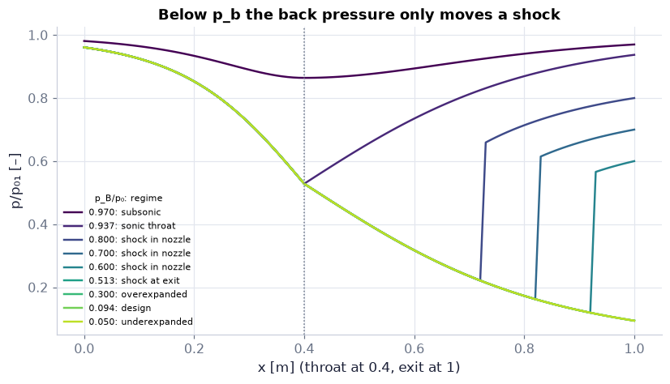

```python
x = np.linspace(0.0, 1.0, 101)                               # 101 stations; the throat x = 0.4 is a grid point
fig, ax = plt.subplots(figsize=(7.4, 4.2))                   # one panel
cols = plt.cm.viridis(np.linspace(0.0, 0.9, 9))              # nine colours
for pB, col in zip((0.97, th["p_b"], 0.8, 0.7, 0.6, th["p_d"], 0.3, th["p_f"], 0.05), cols):
    sol = GD.laval_nozzle(x, GD.laval_area, pB)              # the flow for this back pressure (shock included)
    ax.plot(x, sol["p_over_p0"], color=col, lw=1.6, label=f"{pB:.3f}: {sol['regime']}")   # the shock shows as a vertical jump
ax.axvline(0.4, color=COLORS["muted"], ls=":", lw=1)         # the throat
ax.set(xlabel="x [m] (throat at 0.4, exit at 1)", ylabel="p/p₀₁ [–]",
       title="Below p_b the back pressure only moves a shock")
ax.legend(fontsize=7, title="p_B/p₀: regime", title_fontsize=7, loc="lower left")
savefig(fig, "ch15", "c10_laval_family"); plt.show()
```

**What you see.** The pressure along our Laval nozzle ($A_e/A_t$ = 2) for nine back pressures, each labelled with its regime; shocks appear as vertical jumps.

**How to read it.** Upstream of the throat all choked curves coincide: the mass flow is fixed. Lowering $p_B$ below 0.937 starts a shock at the throat that walks down the bell (0.8, 0.7, 0.6) and reaches the exit at 0.513. Below that the inside of the nozzle no longer changes: the curves for 0.3, 0.094 and 0.05 are the same supersonic curve.

**What would change if…** …the exit-to-throat area ratio were 4? The design pressure would fall to 0.0298 and the shock would need a lower back pressure to reach the exit (0.295 instead of 0.513).

```python
pBs = np.array([0.99, 0.96, th["p_b"], 0.85, 0.75, 0.65, 0.58, th["p_d"], 0.4, 0.25, 0.15, th["p_f"], 0.05])   # back pressures, with the three exact dividing ones
n_frames = len(pBs)                                          # 13 frames: every one of the seven named conditions appears
x = np.linspace(0.0, 1.0, 41 if FAST else 61)                # stations (the throat x = 0.4 is a grid point)
ghost_sub = GD.nozzle_isentropic(x, GD.laval_area, branch="subsonic", A_star=1.0)   # sonic throat, subsonic after (p_b curve)
ghost_sup = GD.nozzle_isentropic(x, GD.laval_area, branch="transonic")              # supersonic after the throat (p_f curve)
fig, ax = plt.subplots(figsize=(6.8, 3.8))                   # one panel
ax.plot(x, ghost_sub["p_over_p0"], color=COLORS["muted"], ls="--", lw=1)   # ghosts: the two isentropic curves
ax.plot(x, ghost_sup["p_over_p0"], color=COLORS["muted"], ls="--", lw=1)
(line,) = ax.plot(x, ghost_sub["p_over_p0"], color=COLORS["accent"], lw=2.2)   # the current flow
(tank,) = ax.plot([1.04], [1.0], ">", color=COLORS["orange"], ms=8)            # the back pressure, just outside the exit
ax.set(xlim=(0, 1.08), ylim=(0, 1.05), xlabel="x [m] (throat 0.4, exit 1)", ylabel="p/p₀₁ [–]")
def update(i):                                               # frame i: one back pressure
    sol = GD.laval_nozzle(x, GD.laval_area, pBs[i])          # the flow, shock included
    line.set_ydata(sol["p_over_p0"]); tank.set_ydata([pBs[i]])   # move the curve and the tank marker
    ax.set_title(f"p_B/p₀ = {pBs[i]:.3f}: {sol['regime']} — ṁ/ṁ_max = {sol['mdot_over_choked']:.3f}", fontsize=9)
    return line, tank
show_animation(animate(update, frames=n_frames, fig=fig, interval=150), player="frames")   # step to stop at each regime
```

[figure not shown]

Once Loop Reflect

**Animation A3.** The back pressure falls from almost $p_0$ to 0.05 $p_0$; step frame by frame to stop at each of the seven named conditions (the title names the regime and the mass flow as a fraction of its maximum).

**What you see.** The pressure along the nozzle (purple) as the back pressure (orange triangle) falls; the two isentropic curves are grey ghosts.

**How to read it.** Above 0.937 the curve and the mass flow both change. Then ṁ/ṁ_max sticks at 1.000, a shock is born at the throat, walks down the bell and leaves at 0.513; after that the inside follows the lower ghost and only the gap between the exit pressure and the triangle changes — that gap is settled outside, by oblique shocks or fans.

**What would change if…** …the walls had friction? The shock would not be a clean normal one: real nozzles show the boundary layer separating behind it (D20, "fails when").

> ▶️ **Live cell.** The widget below needs a running Python kernel. On the web page it is frozen — open this notebook in Colab (button at the top) or run it locally to drag the sliders.

```python
def show(pB_over_p0=0.7, Ae_over_At=2.0):                     # draw one case
    x = np.linspace(0.0, 1.0, 101)                            # stations, throat at 0.4
    A_fn = lambda xx: GD.laval_area(xx, A_exit=Ae_over_At)    # the nozzle with this exit area
    sol = GD.laval_nozzle(x, A_fn, pB_over_p0)                # its flow
    fig, ax = plt.subplots(figsize=(6.4, 3.4))                # one panel
    ax.plot(x, sol["p_over_p0"], color=COLORS["accent"])      # pressure along the nozzle
    ax.plot([1.04], [pB_over_p0], ">", color=COLORS["orange"])   # the tank
    ax.set(ylim=(0, 1.05), xlabel="x [m]", ylabel="p/p₀₁ [–]", title=f"{sol['regime']}; shock at x = {sol['x_shock']:.3f} m")
    plt.show()
live(show, pB_over_p0=(0.05, 1.0, 0.01), Ae_over_At=(1.2, 4.0, 0.1))   # two sliders (need a running kernel)
```

▶️ **Live cell.** These sliders need a running Python kernel, so they are frozen on this page. Press **Open in Colab** at the top (or run the notebook locally) to use them.

#### 🎮 Interactive: Why does a nozzle stop listening?

**Why interactive rather than a static figure:** you open the valve on a transport: the mass-flow needle rises and stops dead while the pressure curve keeps reshaping — a shock is born at the throat, walks down the bell and leaves; one figure per regime cannot show that sequence.

Start with the **Walkthrough**; the **Explain** tab works every number out with your settings, and the **Derivation** tab (where there is one) steps through the same derivation as above. Pressures are fractions of the supply (stagnation) pressure p₀; the back pressure p_B is the pressure in the tank outside the exit.

**What to try:**

- Play the valve from closed to wide open and watch the needle stop.
- Stop when the shock is half-way down the bell: read the stagnation pressure it costs.
- Raise the supply pressure: does the plateau move?

```python
show_viz("ch15", "nozzle_back_pressure")   # full-width explainer; ⤢ Full screen for more room
```

🎮 Interactive 4/9 Why does a nozzle stop listening? Open alone ↗

[interactive chart not shown]

📝 **Note.** **N76 [C]** Outside the exit the jet meets the back pressure through oblique shocks when over-expanded and through expansion fans when under-expanded; C14 and C15 (§15.9) compute the first wave angle at the lip of our nozzle.

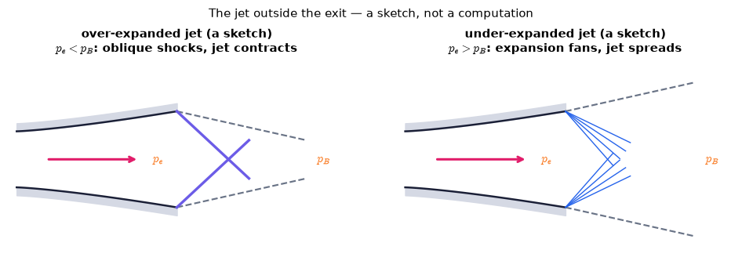

```python
fig, (a, b) = plt.subplots(1, 2, figsize=(9.0, 3.0))         # two sketches side by side
draw_jet_sketch("overexpanded", ax=a)                        # oblique shocks at the lip
draw_jet_sketch("underexpanded", ax=b)                       # expansion fans at the lip
fig.suptitle("The jet outside the exit — a sketch, not a computation", fontsize=10)
plt.show()
```

**What you see.** Two sketches of the jet just outside a supersonic exit: over-expanded (left) and under-expanded (right).

**How to read it.** Over-expanded: the exit pressure is below the back pressure, so the jet is squeezed by oblique shocks from the lip. Under-expanded: the exit pressure is above it, so the jet spreads through expansion fans.

**What would change if…** …the back pressure equalled the design pressure? Neither: the jet would leave parallel and clean.

**What would change if…** …the duct had constant area but rough walls, or a flame inside? The same factor $1-M^2$ does the same work without any throat. C11.

## 15.8 Effects of Friction and Heating in Constant-Area Ducts

**What is this section about?** A straight pipe of constant area, with wall friction and with heat added or removed. One closed formula gives the outlet Mach number; its consequences are the last two of the chapter's three surprises.

### 🧩 Friction and heat in one formula: $M_2^2=\dfrac{-(1-2A\gamma)\pm\left[1-2A(\gamma+1)\right]^{1/2}}{(\gamma-1)-2A\gamma^2}$ (15.46) `C11`

*The question:* A gas enters a straight pipe at a known Mach number, rubs on the wall and is heated. What is its Mach number at the outlet?

#### The problem in plain words

A long gas pipeline; the tail pipe of an engine; the combustion chamber of a jet. No area change at all — yet the flow speeds up or slows down, because the wall drags on it and heat goes in. The same three duct laws apply, now with a wall force and a heat input switched on. They collapse into a single number A that the inlet, the friction and the heat fix, and a quadratic for the outlet Mach number.

#### The idea

```
inlet M₁ ──[ friction f · heat q ]──► outlet M₂
(M₁, f, q) → one number A → a quadratic in M₂² → two roots: one continuous with M₁, one through a shock
```

📝 **Note.** **N79 [B]** We start from $\rho_1u_1=\rho_2u_2,\ \ p_1+\rho_1u_1^2=p_2+\rho_2u_2^2+p_1f,\ \ h_1+\tfrac12u_1^2+h_1q=h_2+\tfrac12u_2^2$ (15.45, with $f=F/(p_1A)$, $q=Q/h_1$): C03's three laws at constant area with a retarding wall force F and a heat input Q, made dimensionless with inlet values.

> ⚠️ **Common confusion** (traps T5, T11): f is **not** a friction factor and q is not a heat flux; F here is the *retarding* force (the opposite sign to F in $-\dot mu_1+\dot mu_2=(pA)_1-(pA)_2+F$ (15.24)). The book's lumped f is not the friction length $4f_FL/D$ of the usual "Fanno flow" tables ($f_F$ the Fanning friction factor, L the duct length, D the hydraulic diameter — conventions cell (a)) — both are shown side by side, with the bridge between them, in N86 (C12).

> 🔁 **Tools from earlier chapters used in this block** (one line each; the full primers are in the chapters named)
- **the quadratic formula** — aX² + bX + c = 0 has the roots X = [−b ± √(b² − 4ac)]/(2a); here X is the square of the outlet Mach number. *(Ch. 6, P159)*

> 📎 **Primer — a quadratic in M squared and its discriminant.** `P366` · A quadratic $aX^2+bX+c=0$ (reminder: P159) has two roots when its discriminant $b^2-4ac$ is positive, one double root when it is zero and none when it is negative. Here $X=M_2^2$: two roots = two possible outlets; a double root = the two outlets merge (choking); none = no steady flow with this inlet.

```python
disc = lambda A, g=1.4: 1 - 2*A*(g + 1)       # the discriminant of (15.46)
for A in (0.144, 0.168, 1/4.8, 0.22):         # A grows with friction or heat
    print(A, disc(A))                         # 0.309, 0.194, 0.0 (choked), -0.056 (no solution)
```

```
0.144 0.3088000000000001
0.168 0.1936
0.20833333333333334 0.0
0.22 -0.05600000000000005
```

#### 🧮 Derivation — The outlet Mach number of a duct with friction and heat `D21` ★★★ (Eq. 15.46: $M_2^2=\dfrac{-(1-2A\gamma)\pm\left[1-2A(\gamma+1)\right]^{1/2}}{(\gamma-1)-2A\gamma^2}$)

**What we want to show.** Find the Mach number at the outlet of a constant-area duct from the inlet Mach number, a lumped friction f and a lumped heat q.

**Assumptions.** Constant area; steady; perfect gas; f and q are totals between the stations.

**The plan.**

1. Write momentum and energy with Mach numbers.
2. Write mass with p, M and T.
3. Eliminate pressure and temperature.
4. Everything about the inlet collects into one number A.
5. Solve a quadratic for $M_2^2$.
6. Check it against the normal shock.

**Tools we use** (each explained before this point): dynamic pressure in a gas (primer P359) · a quadratic in M squared and its discriminant (primer P366) · the quadratic formula (P159 reminder)

**We start from**

$$ \rho_1u_1=\rho_2u_2,\ \ p_1+\rho_1u_1^2=p_2+\rho_2u_2^2+p_1f,\ \ h_1+\tfrac12u_1^2+h_1q=h_2+\tfrac12u_2^2\ \text{(15.45, with}\ f=F/(p_1A)\ \text{,}\ q=Q/h_1\ \text{)} $$

*In words:* Mass, momentum with a retarding wall force, energy with heat added

**Step 1 of 13 — Momentum with Mach numbers.**

$$ p_1\left(1+\gamma M_1^2-f\right)=p_2\left(1+\gamma M_2^2\right) $$

- *Why we can do this:* $\rho u^2=\gamma pM^2$ on each side (primer P359); the friction term $p_1f$ joins the inlet side.
- *In words:* The momentum balance in pressures and Mach numbers.

**Step 2 of 13 — Energy with Mach numbers.**

$$ h_1\left(1+\tfrac{\gamma-1}{2}M_1^2+q\right)=h_2\left(1+\tfrac{\gamma-1}{2}M_2^2\right) $$

- *Why we can do this:* $\tfrac12u^2=\tfrac12M^2\gamma RT=\tfrac{\gamma-1}{2}M^2h$, because $h=C_pT=\gamma RT/(\gamma-1)$. This trades the kinetic energy for the Mach number, as P359 does for the momentum flux, so that energy too is written in M.
- *In words:* The energy balance in enthalpies and Mach numbers.

**Step 3 of 13 — Mass with pressure, Mach number and temperature.**

$$ \dfrac{p_1M_1}{\sqrt{T_1}}=\dfrac{p_2M_2}{\sqrt{T_2}} $$

- *Why we can do this:* $\rho u=\dfrac{p}{RT}M\sqrt{\gamma RT}=pM\sqrt{\gamma/(RT)}$ (as in D19 step 2); the constants cancel.
- *In words:* Mass flux is pressure × Mach number over √temperature — this ties the three laws together.

**Step 4 of 13 — Solve mass for the Mach-number ratio.**

$$ \dfrac{M_2}{M_1}=\dfrac{p_1}{p_2}\sqrt{\dfrac{T_2}{T_1}} $$

- *Why we can do this:* Divide both sides of step 3 by $p_2M_1/\sqrt{T_2}$ (none of these is zero), which solves the mass law for the Mach-number ratio $M_2/M_1$; the pressure ratio and the temperature ratio left on the right are exactly what steps 1 and 2 supply.
- *In words:* The Mach number changes through the pressure ratio and the temperature ratio.

**Step 5 of 13 — Insert the pressure ratio.**

$$ \dfrac{p_1}{p_2}=\dfrac{1+\gamma M_2^2}{1+\gamma M_1^2-f} $$

- *Why we can do this:* Divide step 1 by $p_2\left(1+\gamma M_1^2-f\right)$ (both factors positive); the result is the pressure ratio that step 4 needs, supplied by the momentum law.
- *In words:* From momentum.

**Step 6 of 13 — Insert the temperature ratio.**

$$ \dfrac{M_2}{M_1}=\dfrac{1+\gamma M_2^2}{1+\gamma M_1^2-f}\left[\dfrac{1+\frac{\gamma-1}{2}M_1^2+q}{1+\frac{\gamma-1}{2}M_2^2}\right]^{1/2} $$

- *Why we can do this:* Step 2 with $h_2/h_1=T_2/T_1$. For a perfect gas h = C_pT, so the enthalpy ratio is the temperature ratio; substituting step 2 leaves only Mach numbers, f and q.
- *In words:* One equation with $M_2$ on both sides.

**Step 7 of 13 — Square and put each station on its own side.**

$$ A\equiv\dfrac{M_1^2\left(1+\frac12(\gamma-1)M_1^2+q\right)}{\left(1+\gamma M_1^2-f\right)^2}=\dfrac{M_2^2\left(1+\frac12(\gamma-1)M_2^2\right)}{\left(1+\gamma M_2^2\right)^2}\ \text{(unnumbered, §15.8)} $$

- *Why we can do this:* Squaring removes the root (both sides are positive); then divide by $\left(1+\gamma M_2^2\right)^2$ and multiply by $M_1^2$ times the inlet bracket. Everything known is on one side: call it A.
- *In words:* One pure number A — fixed by the inlet, the friction and the heat — determines the outlet. (A is not an area.)

**Step 8 of 13 — Write the outlet side as an equation for $X\equiv M_2^2$.**

$$ X\left(1+\tfrac{\gamma-1}{2}X\right)=A\left(1+\gamma X\right)^2 $$

- *Why we can do this:* Multiply step 7 by the denominator.
- *In words:* A quadratic for the square of the outlet Mach number.

**Step 9 of 13 — Bring it to standard form.**

$$ \left[\tfrac{\gamma-1}{2}-A\gamma^2\right]X^2+\left(1-2A\gamma\right)X-A=0 $$

- *Why we can do this:* Expand $(1+\gamma X)^2=1+2\gamma X+\gamma^2X^2$ and collect powers of X.
- *In words:* Standard quadratic form.

**Step 10 of 13 — Apply the quadratic formula.**

$$ X=\dfrac{-(1-2A\gamma)\pm\sqrt{(1-2A\gamma)^2+4A\left[\tfrac{\gamma-1}{2}-A\gamma^2\right]}}{2\left[\tfrac{\gamma-1}{2}-A\gamma^2\right]} $$

- *Why we can do this:* The formula for $aX^2+bX+c=0$ with $c=-A$.
- *In words:* Two candidate outlets.

**Step 11 of 13 — Simplify the discriminant.**

$$ (1-2A\gamma)^2+2A(\gamma-1)-4A^2\gamma^2=1-2A(\gamma+1) $$

- *Why we can do this:* $1-4A\gamma+4A^2\gamma^2+2A\gamma-2A-4A^2\gamma^2$: the $A^2$ terms cancel. Expanding the square and collecting like terms is ordinary algebra; the cancellation is what makes the root simple.
- *In words:* The discriminant is linear in A.

**Step 12 of 13 — Write the result.**

$$ M_2^2=\dfrac{-(1-2A\gamma)\pm\left[1-2A(\gamma+1)\right]^{1/2}}{(\gamma-1)-2A\gamma^2}\ \text{(15.46)} $$

- *Why we can do this:* Step 11 in step 10; the 2 of the denominator is multiplied in.
- *In words:* The outlet Mach number in closed form: two roots while $A<1/(2(\gamma+1))$, one when equal, none beyond.

**Step 13 of 13 — Test it with no friction and no heat.**

$$ f=q=0:\quad M_2^2=M_1^2\quad\text{or}\quad M_2^2=\dfrac{(\gamma-1)M_1^2+2}{2\gamma M_1^2+1-\gamma} $$

- *Why we can do this:* Then $1-2A(\gamma+1)=\left(\dfrac{M_1^2-1}{1+\gamma M_1^2}\right)^2$, a perfect square; its root is $\lvert M_1^2-1\rvert/(1+\gamma M_1^2)$, which is why the sign that gives $M_2=M_1$ is + for $M_1<1$ and − for $M_1>1$.
- *In words:* With nothing acting, the duct either does nothing or holds a normal shock — exactly $M_2^2=\dfrac{(\gamma-1)M_1^2+2}{2\gamma M_1^2+1-\gamma}$ (15.40).

**Result**

$$ \begin{array}{l}M_2^2=\dfrac{-(1-2A\gamma)\pm\left[1-2A(\gamma+1)\right]^{1/2}}{(\gamma-1)-2A\gamma^2}\ \text{(15.46) with} \\ A\equiv\dfrac{M_1^2\left(1+\frac12(\gamma-1)M_1^2+q\right)}{\left(1+\gamma M_1^2-f\right)^2}=\dfrac{M_2^2\left(1+\frac12(\gamma-1)M_2^2\right)}{\left(1+\gamma M_2^2\right)^2}\ \text{(unnumbered,} \\ \text{§15.8).}\end{array} $$

**What it means.** The duct with friction and heat is the normal shock's bigger sibling: the same three laws with two more terms. Friction and heat both *raise* A; when A reaches 1/(2(γ + 1)) the roots merge at Mach 1 — choking (C12). **Fails when:** f and q are not small lumps but distributed with changing properties (then integrate the differentials of C12), or the area changes.

**Check it.** Units — pure numbers ✓. Limits — step 13; and $A=1/(2(\gamma+1))$: $M_2=1$ (D24). Number — $M_1$ = 0.5, f = 0.1: A = 0.168, discriminant 0.1936, $M_2$ = 0.589 (and 1.936, excluded). Residuals of $\rho_1u_1=\rho_2u_2,\ \ p_1+\rho_1u_1^2=p_2+\rho_2u_2^2+p_1f,\ \ h_1+\tfrac12u_1^2+h_1q=h_2+\tfrac12u_2^2$ at that outlet < 10⁻¹² (`GD.duct_residuals`).

```python
import sympy as sp                                   # symbolic algebra
g, A, X = sp.symbols("gamma A X", positive=True)     # gamma; the duct number A; X = M2^2
M1 = sp.symbols("M_1", positive=True)                # inlet Mach number
eq = X*(1 + (g-1)/2*X) - A*(1 + g*X)**2              # step 8: X(1 + (gamma-1)X/2) = A (1 + gamma X)^2
P = sp.Poly(sp.expand(eq), X)                        # step 9: collect powers of X
qa, qb, qc = P.all_coeffs()                          # the three coefficients of the quadratic
assert sp.simplify(qa - ((g-1)/2 - A*g**2)) == 0 and sp.simplify(qb - (1 - 2*A*g)) == 0 and qc == -A   # the three coefficients of step 9
disc = sp.factor(sp.simplify(qb**2 - 4*qa*qc))       # step 11: the discriminant
assert sp.simplify(disc - (1 - 2*A*(g+1))) == 0      # ... collapses to 1 - 2A(gamma+1)
roots = [(-(1 - 2*A*g) + s*sp.sqrt(1 - 2*A*(g+1)))/((g-1) - 2*A*g**2) for s in (1, -1)]   # Eq. (15.46)
for X_root in roots:                                 # each root satisfies the step-8 equation
    assert sp.simplify(eq.subs(X, X_root)) == 0     # ... put back into step 8, it leaves exactly zero
A0 = M1**2*(1 + (g-1)/2*M1**2)/(1 + g*M1**2)**2      # step 13: A with f = q = 0
shock = ((g-1)*M1**2 + 2)/(2*g*M1**2 + 1 - g)        # Eq. (15.40): M2^2 behind a normal shock
assert sp.simplify(eq.subs({A: A0, X: M1**2})) == 0  # "nothing happens" is a root
assert sp.simplify(eq.subs({A: A0, X: shock})) == 0  # the normal shock is the other root
assert sp.simplify(sp.factor((1 - 2*A0*(g+1))) - (M1**2 - 1)**2/(1 + g*M1**2)**2) == 0   # discriminant: a perfect square
print(disc, "|", sp.factor(1 - 2*A0*(g+1)))          # the discriminant in general and for f = q = 0
```

```
-2*A*gamma - 2*A + 1 | (M_1 - 1)**2*(M_1 + 1)**2/(M_1**2*gamma + 1)**2
```

📝 **Notes taught inside `D21`:** **N80 [B]** the duct number $A\equiv\dfrac{M_1^2\left(1+\frac12(\gamma-1)M_1^2+q\right)}{\left(1+\gamma M_1^2-f\right)^2}=\dfrac{M_2^2\left(1+\frac12(\gamma-1)M_2^2\right)}{\left(1+\gamma M_2^2\right)^2}$ (unnumbered, §15.8) and $M_2^2=\dfrac{-(1-2A\gamma)\pm\left[1-2A(\gamma+1)\right]^{1/2}}{(\gamma-1)-2A\gamma^2}$ (15.46) (steps 1–7). The duct number A is a pure number, not an area (trap T2). Slip #14: the book says "$M_2$ calculated from (15.45)" — the three duct laws $\rho_1u_1=\rho_2u_2,\ \ p_1+\rho_1u_1^2=p_2+\rho_2u_2^2+p_1f,\ \ h_1+\tfrac12u_1^2+h_1q=h_2+\tfrac12u_2^2$ (15.45, with $f=F/(p_1A)$, $q=Q/h_1$) — where it means their closed-form solution $M_2^2=\dfrac{-(1-2A\gamma)\pm\left[1-2A(\gamma+1)\right]^{1/2}}{(\gamma-1)-2A\gamma^2}$ (15.46).

> ⚠️ **Common confusion (traps in `D21`):** F is the *retarding* force here (trap T11); A is a number (trap T2); squaring in step 7 would admit a negative root — both sides are positive, so none is added; the continuous root changes sign of ± at $M_1=1$ (trap T12); numerator and denominator of $M_2^2=\dfrac{-(1-2A\gamma)\pm\left[1-2A(\gamma+1)\right]^{1/2}}{(\gamma-1)-2A\gamma^2}$ vanish together at $2A\gamma^2=\gamma-1$ (take the limit there).

📝 **Note.** **N83 [B]** **The check that closes D21.** With f = q = 0 the continuous root is $M_2=M_1$ and the other is $M_2^2=\dfrac{(\gamma-1)M_1^2+2}{2\gamma M_1^2+1-\gamma}$ (15.40) — the normal shock of C07 drops out of the duct formula. The root with $M_2>1$ from $M_1<1$ has ΔS < 0 and is excluded.

> ⚠️ **Common confusion** (trap T12): which sign of ± is the continuous root flips at $M_1=1$ (+ below, − above).

```python
print(GD.duct_outlet_mach(2.0), GD.duct_outlet_mach(2.0, branch="shocked"), GD.normal_shock_mach(2.0))   # 2.0; 0.5774 = the normal shock
M2x = GD.duct_outlet_mach(0.5, branch="shocked")             # the other root from a subsonic inlet: 2.6458
print(M2x, GD.duct_entropy_change(0.5, M2x))                 # ... with (S2 - S1)/Cv = -0.326 < 0: forbidden
```

```
1.9999999999999998 0.5773502691896257 0.5773502691896257
2.6457513110645916 -0.3255733857863208
```

#### ✏️ Tiny example: M₁ = 0.5 with friction f = 0.1, by hand

γ = 1.4, q = 0.

1. Numerator of $A\equiv\dfrac{M_1^2\left(1+\frac12(\gamma-1)M_1^2+q\right)}{\left(1+\gamma M_1^2-f\right)^2}=\dfrac{M_2^2\left(1+\frac12(\gamma-1)M_2^2\right)}{\left(1+\gamma M_2^2\right)^2}$ (unnumbered, §15.8): 0.25 × (1 + 0.05) = 0.2625.
2. Denominator: (1 + 0.35 − 0.1)² = 1.25² = 1.5625.
3. A = 0.2625/1.5625 = **0.168**.
4. Discriminant: 1 − 2 × 0.168 × 2.4 = 0.1936; its root is 0.44.
5. $M_2^2=\dfrac{-(1-2A\gamma)\pm\left[1-2A(\gamma+1)\right]^{1/2}}{(\gamma-1)-2A\gamma^2}$ (15.46), upper sign: $M_2^2$ = (−(1 − 0.4704) + 0.44)/(0.4 − 0.6586) = (−0.0896)/(−0.2586) = 0.3465 → $M_2$ = **0.589**.
6. Lower sign: (−0.9696)/(−0.2586) = 3.75 → $M_2$ = 1.936 (supersonic from subsonic: forbidden).
7. Friction took the flow from Mach 0.50 to 0.59: it **sped up**.

```python
A = GD.duct_parameter_A(duct["M1"], f=duct["f"])              # the duct number for M1 = 0.5, f = 0.1 -> 0.168
M2 = GD.duct_outlet_mach(duct["M1"], f=duct["f"])             # (15.46), continuous root -> 0.5887
rf = GD.duct_state_ratios(duct["M1"], M2, f=duct["f"])        # outlet / inlet ratios
print(round(A, 4), round(M2, 4), {k: round(float(rf[k]), 4) for k in ("p_ratio", "T_ratio", "rho_ratio", "p0_ratio", "T0_ratio")})
M2q = GD.duct_outlet_mach(duct["M1"], q=duct["q"])            # heat q = 0.2 instead of friction
rq = GD.duct_state_ratios(duct["M1"], M2q, q=duct["q"])
print(round(GD.duct_parameter_A(duct["M1"], q=duct["q"]), 4), round(M2q, 4), {k: round(float(rq[k]), 4) for k in ("T_ratio", "p0_ratio", "T0_ratio")})
print(GD.duct_outlet_mach(2.0, f=duct["f"]))                 # a supersonic inlet with the same friction: 2.0 -> 1.882 (it slows)
s1 = dict(rho=1.0, u=1.0, p=1.0 / (1.4 * 0.25))              # inlet in units rho1 = u1 = 1, so M1 = 0.5 means p1 = 1/(gamma M1²)
s2 = dict(rho=rf["rho_ratio"], u=1.0 / rf["rho_ratio"], p=s1["p"] * rf["p_ratio"])   # outlet from the ratios
print(GD.duct_residuals(s1, s2, f=duct["f"], q=0.0))         # (15.45): mass, momentum, energy residuals ~1e-16
```

```
0.168 0.5887 {'p_ratio': 0.8417, 'T_ratio': 0.9819, 'rho_ratio': 0.8571, 'p0_ratio': 0.8971, 'T0_ratio': 1.0}
0.1715 0.6038 {'T_ratio': 1.165, 'p0_ratio': 0.9639, 'T0_ratio': 1.1905}
1.882147908594118
{'mass': 0.0, 'momentum': -1.1513423959075697e-16, 'energy': -1.6917684184764287e-16}
```

**What does the code above do?**

1. `GD.duct_parameter_A` is the left side of $A\equiv\dfrac{M_1^2\left(1+\frac12(\gamma-1)M_1^2+q\right)}{\left(1+\gamma M_1^2-f\right)^2}=\dfrac{M_2^2\left(1+\frac12(\gamma-1)M_2^2\right)}{\left(1+\gamma M_2^2\right)^2}$ (unnumbered, §15.8): 0.1680. `GD.duct_outlet_mach` picks the root that tends to $M_1$ when f and q go to zero: 0.5887.
2. `GD.duct_state_ratios` gives the outlet state: pressure 0.842 of the inlet's, temperature 0.982, density 0.857, stagnation pressure 0.897 — and $T_{02}/T_{01}$ = 1 exactly (no heat).
3. With heat q = 0.2 instead: A = 0.1715, $M_2$ = 0.6038, the gas is 16.5 % hotter, $T_0$ rose by 19 %, and 3.6 % of $p_0$ is lost.
4. A supersonic inlet with the same friction *slows* (2.0 → 1.882).
5. The two state dicts satisfy $\rho_1u_1=\rho_2u_2,\ \ p_1+\rho_1u_1^2=p_2+\rho_2u_2^2+p_1f,\ \ h_1+\tfrac12u_1^2+h_1q=h_2+\tfrac12u_2^2$ (15.45, with $f=F/(p_1A)$, $q=Q/h_1$) to round-off.

```python
g, M1, f, q = 1.4, 0.5, 0.1, 0.2                              # both friction and heat at once
def gas_law_gap(r):                                           # r = u2/u1; zero when the gas law closes the three laws
    rho = 1 / r                                               # mass: rho2/rho1
    p = 1 + g * M1**2 * (1 - r) - f                           # momentum: p2/p1
    T = 1 + q + 0.5 * (g - 1) * M1**2 * (1 - r * r)           # energy: T2/T1 (cp T1 + u1²/2 + q cp T1 = cp T2 + u2²/2)
    return p - rho * T                                        # gas law: p2/p1 = (rho2/rho1)(T2/T1)
print([round(gas_law_gap(v), 3) for v in (1.0, 1.5, 2.0, 3.0)])   # signs: -, -, +, - -> two roots; the first one is continuous with r = 1
r = brentq(gas_law_gap, 1.0, 2.0)                             # the root that is continuous with r = 1 (accelerating, subsonic)
T = 1 + q + 0.5 * (g - 1) * M1**2 * (1 - r * r)               # its temperature ratio
M2_mine = M1 * r / np.sqrt(T)                                 # M2 = u2/c2 = M1 (u2/u1)/sqrt(T2/T1)
assert np.allclose(M2_mine, GD.duct_outlet_mach(M1, f=f, q=q))   # same as (15.46)
print(M2_mine)
```

```
[-0.3, -0.033, 0.025, -0.067]
0.790569415042096
```

**From scratch, without $M_2^2=\dfrac{-(1-2A\gamma)\pm\left[1-2A(\gamma+1)\right]^{1/2}}{(\gamma-1)-2A\gamma^2}$ (15.46).** One unknown, the speed ratio r: mass gives the density ratio, momentum the pressure ratio, energy the temperature ratio, and the gas law must close them. `brentq` finds the root near r = 1 — the same outlet Mach number as the closed form.

📝 **Note.** **N81 [B] · N82 [B]** Our versions of the book's two charts, with our own parameter values: $M_2$ against $M_1$ for a range of friction (left slider) and of heat (right slider). (Slip #15: some supersonic labels on the book's heating chart lack a decimal point; the turning points from `GD.duct_choking_limits` show which values were meant.)

```python
M1 = np.linspace(0.02, 4.0, 160)                              # inlet Mach numbers
loc = GD.duct_choking_locus()                                 # f_max(M1), q_max(M1) on its own grid
def chart(f=0.0, q=0.0, key="f_max", val=0.0):                # one curve set of the chart
    c = GD.duct_curve(M1, f=f, q=q)                           # both roots, NaN where choked
    lim = loc[key] - val                                      # where the choking limit equals this f or q
    idx = np.where(np.diff(np.sign(lim)) != 0)[0]             # sign changes: the choked inlets
    return {"M₂ continuous": (M1, c["M2_continuous"]), "M₂ through a shock": (M1, c["M2_shocked"]),   # the two roots of (15.46)
            "M₂ = M₁": (M1, M1), "choked inlet (M₂ = 1)": (loc["M1"][idx], np.ones(idx.size)),   # diagonal; choking dots
            "forbidden: M₁ < 1 < M₂": ([0, 1, 1, 0, 0], [1, 1, 4, 4, 1])}   # outline of the forbidden box
modes = {"choked inlet (M₂ = 1)": "markers"}                  # dots for the choking points
fig_f = slider_figure(lambda f: chart(f=f, key="f_max", val=f), "f", np.linspace(0.0, 0.6, 13),   # friction slider (q = 0)
                      xlabel="inlet M₁ [–]", ylabel="outlet M₂ [–]", title="Friction pushes every M₂ toward 1",   # labels and message
                      xrange=[0, 4], yrange=[0, 4], modes=modes)   # fixed axes; dots for the choking points
fig_f.show()   # display
fig_q = slider_figure(lambda q: chart(q=q, key="q_max", val=q), "q", np.linspace(-0.4, 1.0, 15),   # heat slider (f = 0)
                      xlabel="inlet M₁ [–]", ylabel="outlet M₂ [–]", title="Heating does the same; cooling does the opposite",   # labels and message
                      xrange=[0, 4], yrange=[0, 4], modes=modes)   # fixed axes; dots for the choking points
fig_q.show()   # display
```

[interactive chart not shown]

**Figures F7.** Sliders: the lumped friction f from 0 to 0.6 (with q = 0) and the lumped heat q from −0.4 to 1 (with f = 0). `GD.duct_curve` returns both roots of $M_2^2=\dfrac{-(1-2A\gamma)\pm\left[1-2A(\gamma+1)\right]^{1/2}}{(\gamma-1)-2A\gamma^2}$ (15.46) for every inlet; the dots are where the inlet is exactly choked (`GD.duct_choking_locus`).

**What you see.** The outlet Mach number against the inlet one: the continuous root (purple), the root through a shock (teal), the diagonal "nothing happens", the choking points at $M_2=1$ and the box where the root would be supersonic from a subsonic inlet.

**How to read it.** At f = 0 the purple curve is the diagonal and the teal one is the normal shock of C07. Drag f up: the subsonic part of the purple curve rises toward 1 and the supersonic part falls toward 1; between the two choking dots there is no curve — those inlets cannot pass this much friction. With q < 0 (cooling) the curve moves *away* from 1 and never chokes.

**What would change if…** …γ were 5/3? The choking limits change (f_max at $M_1$ = 0.5 drops from 0.228 to about 0.21): the dots move, the picture does not.

**What would change if…** …you asked only for the *direction* of each change, for a little friction or a little heat? Then the quadratic becomes a set of differentials — with the same $1-M^2$ as the area rule. C12.

### 🧩 Everything drifts to Mach 1: $\dfrac{du}{u}=\dfrac{p_1}{p}\dfrac{df}{1-M^2}$ and $\dfrac{du}{u}=\dfrac{h_1}{h}\dfrac{dq}{1-M^2}$ (the velocity members of the friction and heat differentials (15.47), (15.48), sign-corrected) `C12`

*The question:* Can friction make a flow faster, and can heating make a gas colder?

#### The problem in plain words

Rub your hands: friction slows things and warms them. Light a stove: heat raises the temperature. In a gas flowing through a pipe both everyday rules fail. Friction makes a subsonic flow *faster* (its pressure and density drop so quickly that the speed must rise to carry the same mass). And in a narrow band of Mach number just below 1, adding heat makes the gas *colder*: the heat goes into speed faster than it arrives. Both effects push the Mach number toward 1 from either side — and stop there: the pipe chokes.

#### The idea

|  | friction, M < 1 | friction, M > 1 | heating, M < 1 | heating, M > 1 |
| --- | --- | --- | --- | --- |
| M | ↑ | ↓ | ↑ | ↓ |
| u | ↑ | ↓ | ↑ | ↓ |
| p | ↓ | ↑ | ↓ | ↑ |
| T | ↓ | ↑ | ↑ (then ↓ above $M^2=1/\gamma$) | ↑ |
| $p_0$ | ↓ | ↓ | ↓ | ↓ |
| S | ↑ | ↑ | ↑ | ↑ |

#### 🧮 Derivation — A little friction: the differentials, corrected `D22` ★★ (Eq. 15.47, numerator sign corrected: $-\dfrac{dp}{p_1}=\dfrac{1+(\gamma-1)M^2}{1-M^2}\,df,\ \ \dfrac{du}{u}=-\dfrac{d\rho}{\rho}=\dfrac{p_1}{p}\dfrac{df}{1-M^2}$)

**What we want to show.** Find which way speed, density and pressure change when a little wall friction acts on an adiabatic duct flow.

**Assumptions.** Constant area; adiabatic (q = 0); perfect gas; df > 0 (friction retards).

**The plan.**

1. Take the differential of each law.
2. Express $d\rho$, $dT$, then $dp$ by $du$.
3. Put them into momentum.
4. Solve.

**Tools we use** (each explained before this point): differentials of algebraic laws as a small linear system (primer P362) · logarithmic differentiation (P52 reminder) · dynamic pressure in a gas (primer P359)

**We start from**

$$ \rho u=\text{const},\qquad dp+d(\rho u^2)=-p_1\,df,\qquad h+\tfrac12u^2=\text{const} $$

*In words:* The three laws of $\rho_1u_1=\rho_2u_2,\ \ p_1+\rho_1u_1^2=p_2+\rho_2u_2^2+p_1f,\ \ h_1+\tfrac12u_1^2+h_1q=h_2+\tfrac12u_2^2$ (15.45) with q = 0, applied between two stations a small distance apart: mass flux constant, momentum changed only by the friction of the slice, total enthalpy constant.

**Step 1 of 9 — Differentiate mass.**

$$ \dfrac{d\rho}{\rho}=-\dfrac{du}{u} $$

- *Why we can do this:* $\rho u$ is constant in a constant-area duct: $d\rho/\rho+du/u=0$.
- *In words:* If the gas speeds up by 1 %, it thins by 1 %.

**Step 2 of 9 — Differentiate momentum.**

$$ dp+\rho u\,du=-p_1\,df $$

- *Why we can do this:* $d(\rho u^2)=d(\rho u\cdot u)=\rho u\,du$ because $\rho u$ is constant; the friction of the slice is $p_1\,df$.
- *In words:* Pressure drop plus momentum gain equals the friction on the slice.

**Step 3 of 9 — Differentiate energy.**

$$ \dfrac{dT}{T}=-(\gamma-1)M^2\,\dfrac{du}{u} $$

- *Why we can do this:* $C_p\,dT+u\,du=0$; divide by $C_pT$ and use $u^2/(C_pT)=(\gamma-1)M^2$.
- *In words:* Speeding up cools the gas.

**Step 4 of 9 — Differentiate the gas law.**

$$ \dfrac{dp}{p}=\dfrac{d\rho}{\rho}+\dfrac{dT}{T} $$

- *Why we can do this:* Logarithmic differential of $p=\rho RT$. Taking the logarithm of p = ρRT and differentiating is allowed for positive p, ρ, T; it gives relative changes, the language of the other steps.
- *In words:* Pressure changes through density and temperature.

**Step 5 of 9 — Insert steps 1 and 3.**

$$ \dfrac{dp}{p}=-\left[1+(\gamma-1)M^2\right]\dfrac{du}{u} $$

- *Why we can do this:* Both contributions are negative when du > 0 — they *add*. This is where the + in the corrected numerator comes from.
- *In words:* When the gas speeds up its pressure falls, by more than its density does.

**Step 6 of 9 — Write momentum in relative changes.**

$$ \dfrac{dp}{p}+\gamma M^2\,\dfrac{du}{u}=-\dfrac{p_1}{p}\,df $$

- *Why we can do this:* Divide step 2 by p; $\rho u^2/p=\gamma M^2$ (primer P359).
- *In words:* The same balance, in percentages.

**Step 7 of 9 — Eliminate dp.**

$$ \dfrac{du}{u}=-\dfrac{d\rho}{\rho}=\dfrac{p_1}{p}\,\dfrac{df}{1-M^2}\ \text{(15.47, second relation)} $$

- *Why we can do this:* Step 5 in step 6: $\left[-1-(\gamma-1)M^2+\gamma M^2\right]du/u=(M^2-1)\,du/u=-(p_1/p)\,df$; and step 1.
- *In words:* Friction speeds up a subsonic flow and slows a supersonic one.

**Step 8 of 9 — Return for the pressure.**

$$ -\dfrac{dp}{p_1}=\dfrac{1+(\gamma-1)M^2}{1-M^2}\,df\ \text{(15.47, first relation, numerator sign corrected)} $$

- *Why we can do this:* Step 7 in step 5, times $p/p_1$. (The book prints $1-(\gamma-1)M^2$ in the numerator; step 5 shows the sign must be +.)
- *In words:* In subsonic flow friction lowers the pressure — steeply near Mach 1.

**Step 9 of 9 — Read the signs.**

$$ df>0:\quad M<1\Rightarrow du>0,\ dp<0;\qquad M>1\Rightarrow du<0,\ dp>0 $$

- *Why we can do this:* df is always positive, so the sign of $1-M^2$ decides everything.
- *In words:* From either side, friction pushes the Mach number toward 1.

**Result**

$$ -\dfrac{dp}{p_1}=\dfrac{1+(\gamma-1)M^2}{1-M^2}\,df,\ \ \dfrac{du}{u}=-\dfrac{d\rho}{\rho}=\dfrac{p_1}{p}\dfrac{df}{1-M^2}\ \text{(15.47, numerator sign corrected).} $$

**What it means.** The chapter's second surprise is the first one in disguise: mass forces ρu to stay fixed, and the same $1-M^2$ decides whether a loss of pressure shows up as more speed or less. **Fails when:** heat is exchanged (D23), or the area changes.

**Check it.** Units — numbers ✓. Limit — M → 0: $-dp/p_1=df$, i.e. $-dp\,A=dF$: the pressure drop balances the friction, as in a pipe of incompressible fluid. Numbers — df = 0.01 at M = 0.5: du/u = +1.33 %, −dp/p = 1.47 %. Independent check — finite differences of $M_2^2=\dfrac{-(1-2A\gamma)\pm\left[1-2A(\gamma+1)\right]^{1/2}}{(\gamma-1)-2A\gamma^2}$ (15.46) in f give 1.4667, 6.968, −0.8667 at M = 0.5, 0.9, 2: the corrected coefficient. The printed one gives 1.2000, 3.558, +0.2000.

📝 **Notes taught inside `D22`:** **N84 [B]** $-\dfrac{dp}{p_1}=\dfrac{1+(\gamma-1)M^2}{1-M^2}\,df,\ \ \dfrac{du}{u}=-\dfrac{d\rho}{\rho}=\dfrac{p_1}{p}\dfrac{df}{1-M^2}$ (15.47, numerator sign corrected), as corrected

> ⚠️ **Common confusion (traps in `D22`):** The book's printed numerator (slip #11); the forms hold at the station where $p=p_1$ — over a long duct integrate, do not multiply (trap T11); f is not a friction factor.

> ⚠️ **slip #11 — the book prints** $-\dfrac{dp}{p_1}=\dfrac{1-(\gamma-1)M^2}{1-M^2}df$ (15.47, first relation as printed); **the correct form is** $-\dfrac{dp}{p_1}=\dfrac{1+(\gamma-1)M^2}{1-M^2}\,df,\ \ \dfrac{du}{u}=-\dfrac{d\rho}{\rho}=\dfrac{p_1}{p}\dfrac{df}{1-M^2}$ (15.47, numerator sign corrected)

> Why: mass gives $d\rho/\rho=-du/u$, energy gives $dT/T=-(\gamma-1)M^2\,du/u$, so the gas law gives $dp/p=-[1+(\gamma-1)M^2]\,du/u$ (D22 steps 3–6). The second relation is right as printed.

#### 🧮 Derivation — A little heat: the differentials, corrected `D23` ★★ (Eq. 15.48, second relation's sign corrected: $\dfrac{dT}{T_1}=\left(\dfrac{1-\gamma M^2}{1-M^2}\right)dq,\ \ \dfrac{u\,du}{h_1}=\dfrac{(\gamma-1)M^2}{1-M^2}\,dq$)

**What we want to show.** Find which way temperature and speed change when a little heat is added to a frictionless duct flow.

**Assumptions.** Constant area; no friction; perfect gas; dq > 0 means heating.

**The plan.**

1. Mass and momentum give dp and dT in terms of du.
2. The energy law then gives du in terms of dq.
3. Go back for dT.

**Tools we use** (each explained before this point): differentials as a linear system (primer P362) · $u^2=(\gamma-1)M^2h$

**We start from**

$$ \rho u=\text{const},\qquad p+\rho u^2=\text{const},\qquad dh+u\,du=h_1\,dq $$

*In words:* The three laws of $\rho_1u_1=\rho_2u_2,\ \ p_1+\rho_1u_1^2=p_2+\rho_2u_2^2+p_1f,\ \ h_1+\tfrac12u_1^2+h_1q=h_2+\tfrac12u_2^2$ (15.45) with f = 0, between neighbouring stations: mass flux constant, pressure plus momentum flux constant, total enthalpy raised by the heat of the slice.

**Step 1 of 8 — Differentiate mass.**

$$ \dfrac{d\rho}{\rho}=-\dfrac{du}{u} $$

- *Why we can do this:* As in D22 step 1. In a constant-area duct ρu is the same at every station, so its logarithmic differential vanishes.
- *In words:* Faster means thinner.

**Step 2 of 8 — Differentiate momentum.**

$$ \dfrac{dp}{p}=-\gamma M^2\,\dfrac{du}{u} $$

- *Why we can do this:* With no friction $dp+\rho u\,du=0$; divide by p and use $\rho u^2/p=\gamma M^2$.
- *In words:* Faster means lower pressure.

**Step 3 of 8 — Combine with the gas law.**

$$ \dfrac{dT}{T}=\dfrac{dp}{p}-\dfrac{d\rho}{\rho}=\left(1-\gamma M^2\right)\dfrac{du}{u} $$

- *Why we can do this:* $p=\rho RT$ in logarithmic form; steps 1 and 2.
- *In words:* Whether speeding up warms or cools the gas depends on whether $\gamma M^2$ is below or above 1.

**Step 4 of 8 — Differentiate energy with heat.**

$$ C_p\,dT+u\,du=h_1\,dq $$

- *Why we can do this:* The energy law of $\rho_1u_1=\rho_2u_2,\ \ p_1+\rho_1u_1^2=p_2+\rho_2u_2^2+p_1f,\ \ h_1+\tfrac12u_1^2+h_1q=h_2+\tfrac12u_2^2$ between neighbouring stations; $h=C_pT$.
- *In words:* Heat added goes into enthalpy and kinetic energy.

**Step 5 of 8 — Divide by the local enthalpy.**

$$ \dfrac{dT}{T}+(\gamma-1)M^2\,\dfrac{du}{u}=\dfrac{h_1}{h}\,dq $$

- *Why we can do this:* $u^2/h=(\gamma-1)M^2$ (D21 step 2). Dividing by the local enthalpy h = C_pT is allowed (h > 0) and turns the energy law into relative changes like steps 1–3.
- *In words:* The same in relative changes.

**Step 6 of 8 — Eliminate dT.**

$$ \dfrac{du}{u}=\dfrac{h_1}{h}\,\dfrac{dq}{1-M^2} $$

- *Why we can do this:* Step 3 in step 5: $\left[1-\gamma M^2+(\gamma-1)M^2\right]du/u=(1-M^2)\,du/u$.
- *In words:* Heating speeds up a subsonic flow and slows a supersonic one — exactly like friction.

**Step 7 of 8 — Return for the temperature.**

$$ \dfrac{dT}{T_1}=\left(\dfrac{1-\gamma M^2}{1-M^2}\right)dq\ \text{(15.48, first relation)} $$

- *Why we can do this:* Step 6 in step 3, at the station where $h=h_1$ (so $T=T_1$).
- *In words:* Between $M^2=1/\gamma$ and 1 the bracket is negative: heat in, temperature down.

**Step 8 of 8 — Write the speed change as a kinetic-energy change.**

$$ \dfrac{u\,du}{h_1}=\dfrac{(\gamma-1)M^2}{1-M^2}\,dq\ \text{(15.48, second relation's sign corrected)} $$

- *Why we can do this:* Multiply step 6 by $u^2/h_1=(\gamma-1)M^2$ at $h=h_1$. (The book prints $(1-\gamma)M^2$; that would make heating slow a subsonic flow, against its own text.)
- *In words:* The fraction of the heat that becomes kinetic energy; above $M^2=1/\gamma$ it exceeds 1.

**Result**

$$ \begin{array}{l}\dfrac{dT}{T_1}=\left(\dfrac{1-\gamma M^2}{1-M^2}\right)dq,\ \ \dfrac{u\,du}{h_1}=\dfrac{(\gamma-1)M^2}{1-M^2}\,dq\ \text{(15.48, second relation's sign} \\ \text{corrected).}\end{array} $$

**What it means.** The third surprise. In the band $1/\sqrt\gamma<M<1$ (0.845 to 1 for air) more than all of the added heat goes into speed, and the gas cools. **Fails when:** friction acts too, or the heat release changes the gas (combustion changes γ and R).

**Check it.** Units — numbers ✓. Sum rule — the two relations add to $dT/T_1+u\,du/h_1=dq$ ✓ (the energy law): $(1-\gamma M^2+(\gamma-1)M^2)/(1-M^2)=1$. With the printed sign they would not. Limit — M → 0: $dT/T_1=dq$ (all heat warms the gas). Numbers — dq = 0.01 at M = 0.9: dT/T = −0.71 %; finite differences of $M_2^2=\dfrac{-(1-2A\gamma)\pm\left[1-2A(\gamma+1)\right]^{1/2}}{(\gamma-1)-2A\gamma^2}$ (15.46) give 0.1333, 1.7053, −0.5333 for $u\,du/(h_1dq)$ at M = 0.5, 0.9, 2: the corrected coefficient.

📝 **Notes taught inside `D23`:** **N85 [B]** $\dfrac{dT}{T_1}=\left(\dfrac{1-\gamma M^2}{1-M^2}\right)dq,\ \ \dfrac{u\,du}{h_1}=\dfrac{(\gamma-1)M^2}{1-M^2}\,dq$ (15.48, second relation's sign corrected), as corrected

> ⚠️ **Common confusion (traps in `D23`):** The book's printed sign (slip #12); dT changes sign at $M^2=1/\gamma$, not at M = 1 (trap T18); entropy still rises with dq > 0; q is the dimensionless $Q/h_1$.

> ⚠️ **slip #12 — the book prints** $\dfrac{u\,du}{h_1}=\dfrac{(1-\gamma)M^2}{1-M^2}dq$ (15.48, second relation as printed); **the correct form is** $\dfrac{dT}{T_1}=\left(\dfrac{1-\gamma M^2}{1-M^2}\right)dq,\ \ \dfrac{u\,du}{h_1}=\dfrac{(\gamma-1)M^2}{1-M^2}\,dq$ (15.48, second relation's sign corrected)

> Why: $du/u=dq/(1-M^2)$ and $u^2/h=(\gamma-1)M^2$ (D23 steps 6–8); the printed sign would make heating *slow* a subsonic flow, against the book's own text and chart. The first relation is right as printed.

```python
h = 1e-6                                                      # a little friction (or heat): df = dq = 1e-6
g = 1.4
for M in (0.5, 0.9, 2.0):                                     # subsonic, near-sonic, supersonic
    M2 = GD.duct_outlet_mach(M, f=h)                          # (15.46) with a tiny f
    fd = -(GD.duct_state_ratios(M, M2, f=h)["p_ratio"] - 1) / h   # -dp/(p1 df) by finite differences
    corr, printed = (1 + (g - 1) * M**2) / (1 - M**2), (1 - (g - 1) * M**2) / (1 - M**2)   # corrected and printed numerators of (15.47)
    c = GD.influence_coefficients(M, df=h)                    # the library's (corrected) differentials
    bad = GD.influence_coefficients(M, df=h, printed_15_47=True)   # the printed sign, kept only as a planted wrong variant
    assert np.allclose(fd, -c["dp_over_p"] / h, rtol=1e-4) and np.isclose(fd, corr, rtol=1e-4)   # finite differences = corrected form
    assert not np.allclose(fd, -bad["dp_over_p"] / h, rtol=0.05)                                  # … and ≠ the printed form
    M2q = GD.duct_outlet_mach(M, q=h)                         # (15.46) with a tiny q
    fdq = (GD.duct_state_ratios(M, M2q, q=h)["u_ratio"] - 1) / h * (g - 1) * M**2   # u du/(h1 dq) = (du/u)(u²/h1)
    cq = GD.influence_coefficients(M, dq=h); badq = GD.influence_coefficients(M, dq=h, printed_15_48=True)
    assert np.allclose(fdq, cq["u_du_over_h"] / h, rtol=1e-4) and not np.allclose(fdq, badq["u_du_over_h"] / h, rtol=0.05)
    print(f"M = {M}: friction FD {fd:+.4f} (corrected {corr:+.4f}, printed {printed:+.4f}); heat FD {fdq:+.4f} "
          f"(corrected {(g-1)*M**2/(1-M**2):+.4f}, printed {(1-g)*M**2/(1-M**2):+.4f})")
```

```
M = 0.5: friction FD +1.4667 (corrected +1.4667, printed +1.2000); heat FD +0.1333 (corrected +0.1333, printed -0.1333)
M = 0.9: friction FD +6.9686 (corrected +6.9684, printed +3.5579); heat FD +1.7053 (corrected +1.7053, printed -1.7053)
M = 2.0: friction FD -0.8667 (corrected -0.8667, printed +0.2000); heat FD -0.5333 (corrected -0.5333, printed +0.5333)
```

**From scratch — the cell that justifies both corrections.** We ask the *exact* duct formula $M_2^2=\dfrac{-(1-2A\gamma)\pm\left[1-2A(\gamma+1)\right]^{1/2}}{(\gamma-1)-2A\gamma^2}$ (15.46) what a tiny friction or heat does, by finite differences, and compare with both forms of each coefficient:

1. friction: 1.4667, 6.968, −0.8667 at M = 0.5, 0.9, 2 — equal to the corrected numerator; the printed one gives 1.2000, 3.558, +0.2000 (18 % and 49 % off, and the wrong sign);
2. heat: 0.1333, 1.7053, −0.5333 — equal to the corrected $(\gamma-1)M^2/(1-M^2)$; the printed sign is the opposite.

The library's printed-sign options exist only so that a test can show they fail.

> 📎 **Primer — a process line on a T–s diagram (Fanno and Rayleigh lines).** `P367` · Plot temperature against entropy for all the states one duct flow can pass through as friction (or heat) accumulates: a curve with a "nose" of maximum entropy at M = 1. Most books call the friction curve the **Fanno line** and the heating curve the **Rayleigh line** — names *not in our book*. Their star is the sonic state of the *same* process (trap T2).

```python
M = np.array([0.5, 0.845, 1.0, 2.0])               # Mach numbers along a heating process
T_ratio = ((1 + 1.4)*M/(1 + 1.4*M**2))**2          # Rayleigh T/T*: (2.4 M / (1 + 1.4 M^2))^2
print(T_ratio)                                     # 0.79, 1.029 (the maximum, at M^2 = 1/gamma), 1.0, 0.529
```

```
[0.7901 1.0286 1.     0.5289]
```

📝 **Note.** **N86 [B]** Heating acts like friction (drives M toward 1); cooling does the opposite and always has a solution. The book's parameters beside the usual ones (**not in the book — ours**):

| The book | Most other sources (ours) |
| --- | --- |
| lumped $f=F/(p_1A)$ | friction length $4f_FL/D$ (`GD.fanno_ratios(M)["fL"]`; bridge `GD.fanno_length_to_f(M1, M2)`) |
| $q=Q/h_1$ | $T_0/T_0^*$ (`GD.rayleigh_ratios(M)["T0"]`); $T_{02}/T_{01}=1+q/(1+\tfrac12(\gamma-1)M_1^2)$ |

**Reading the right-hand column.** $f_F=\tau_w/(\tfrac12\rho u^2)$ is the **Fanning friction factor**: the wall shear stress $\tau_w$ [Pa] over the local dynamic pressure. L is the duct length [m] and D its **hydraulic diameter** [m] (4 × area ÷ wetted perimeter; the diameter for a round pipe — not the drag D of C16, nor the L of lift). **The bridge, slice by slice:** on a slice of length dx the wall force is $\tau_w$ times the wetted area, $dF=\tau_w\,(4A/D)\,dx$; divide by $p_1A$ and use $\tfrac12\rho u^2=\tfrac12\gamma pM^2$ (primer P359):

$$ df=\dfrac{4f_F\,dx}{D}\cdot\tfrac12\gamma M^2\,\dfrac{p}{p_1}. $$

So the two parameters grow together but not in proportion — the factor $\tfrac12\gamma M^2p/p_1$ changes along the duct; `GD.fanno_length_to_f` evaluates both for the same duct. In the Rayleigh column, $T_0^*$ is the stagnation temperature at which *that same heating process* would reach Mach 1 (trap T2: not the isentropic star of C05).

```python
b_ = GD.fanno_length_to_f(0.5, GD.duct_outlet_mach(0.5, f=0.1))   # Mach 0.5 -> 0.5887 by friction: the book's f and the usual 4 f_F L/D
print({k: round(float(v), 4) for k, v in b_.items()})        # f = 0.100, friction length = 0.532
print(GD.fanno_ratios(0.5)["fL"], GD.rayleigh_ratios(0.5)["T0"])   # 4 f L*/D = 1.069 to choke from 0.5; T0/T0* = 0.691
print(rq["T0_ratio"], 1 + duct["q"] / (1 + 0.2 * 0.25))      # T02/T01 = 1 + q/(1 + ½(gamma-1) M1²) = 1.1905 both ways
M_a = GD.duct_outlet_mach(0.5, f=0.1)                         # first duct: f = 0.1
M_b = GD.duct_outlet_mach(M_a, f=0.1)                         # a second, identical duct after it
f_eq = 0.1 + 0.1 * GD.duct_state_ratios(0.5, M_a, f=0.1)["p_ratio"]   # each f is normalised with its own inlet pressure
print(M_a, M_b, GD.duct_outlet_mach(0.5, f=0.2), f_eq, GD.duct_outlet_mach(0.5, f=f_eq))   # 0.589, 0.728; 0.775; 0.184 -> 0.728
```

```
{'friction_length': 0.5317, 'f': 0.1}
1.0690603127182559 0.691358024691358
1.1904761904761905 1.1904761904761905
0.5886719404433565 0.7277420948719375 0.7745966692414831 0.18416666666666667 0.7277420948719365
```

**What does the code above do?**

1. The bridge: our duct (Mach 0.5 → 0.589) is f = 0.100 in the book's parameter and $4f_FL/D$ = 0.532 in the usual one.
2. The usual tables' ratios at M = 0.5: the friction length to choke is 1.069; the Rayleigh $T_0/T_0^*$ is 0.691.
3. The heat parameter q = 0.2 raises $T_0$ by the factor 1.1905, as the formula in the table says.
4. > ⚠️ (trap T11) **Two ducts in series do not add their f**, because each f is normalised with its own inlet pressure: 0.1 then 0.1 takes Mach 0.5 to 0.589 to 0.728; a single f = 0.2 gives 0.775. The equivalent single value is 0.1 + 0.1 × $p_2/p_1$ = 0.184, which indeed gives 0.728.

📝 **Note.** **N87 [B]** From the first relation of $\dfrac{dT}{T_1}=\left(\dfrac{1-\gamma M^2}{1-M^2}\right)dq,\ \ \dfrac{u\,du}{h_1}=\dfrac{(\gamma-1)M^2}{1-M^2}\,dq$ (15.48, second relation's sign corrected): $dT/dq<0$ when $1/\gamma<M^2<1$ — for γ = 1.4, 0.845 < M < 1. Where does the heat go? Into kinetic energy, faster than it arrives.

> ⚠️ **Common confusion (trap T18):** heating *cools* the gas only for $1/\gamma<M^2<1$. That is a statement about one band of Mach number, not about heating in general — below it and above Mach 1 heat warms the gas — and in every band the entropy still rises.

```python
print(GD.rayleigh_temperature_sign(np.array([0.5, 0.9, 2.0])))   # sign of dT/dq: +1, -1, +1
M2h = GD.duct_outlet_mach(0.9, q=0.005)                       # a little heat at M = 0.9
print(GD.duct_state_ratios(0.9, M2h, q=0.005)["T_ratio"])     # 0.9947: heat in, temperature down 0.5 %
```

```
[ 1. -1.  1.]
0.9946864806418105
```

#### 🧮 Derivation — The choking limits of friction and of heat `D24` ★★ (Eq. ours: $f_{\max}=1+\gamma M_1^2-M_1\sqrt{2(\gamma+1)\left(1+\tfrac{\gamma-1}{2}M_1^2\right)}$)

**What we want to show.** Find the largest friction, and the largest heat, a duct can take for a given inlet Mach number.

**Assumptions.** As D21.

**The plan.**

1. The two roots merge when the discriminant vanishes.
2. Show the merged root is Mach 1.
3. Solve "A = that value" for f, then for q.

**Tools we use** (each explained before this point): a quadratic in M squared and its discriminant (primer P366)

**We start from**

$$ \begin{array}{l}M_2^2=\dfrac{-(1-2A\gamma)\pm\left[1-2A(\gamma+1)\right]^{1/2}}{(\gamma-1)-2A\gamma^2}\ \text{(15.46) and} \\ A\equiv\dfrac{M_1^2\left(1+\frac12(\gamma-1)M_1^2+q\right)}{\left(1+\gamma M_1^2-f\right)^2}=\dfrac{M_2^2\left(1+\frac12(\gamma-1)M_2^2\right)}{\left(1+\gamma M_2^2\right)^2}\ \text{(unnumbered,} \\ \text{§15.8).}\end{array} $$

**Step 1 of 8 — Set the discriminant to zero.**

$$ 1-2A(\gamma+1)=0\ \Rightarrow\ A=\dfrac{1}{2(\gamma+1)} $$

- *Why we can do this:* A quadratic has a double root exactly when its discriminant vanishes; beyond that A there is no real root.
- *In words:* The largest A a duct flow can have: 0.208 for air.

**Step 2 of 8 — Find the merged root.**

$$ M_2^2=\dfrac{-(1-2A\gamma)}{(\gamma-1)-2A\gamma^2}=\dfrac{-1/(\gamma+1)}{-1/(\gamma+1)}=1 $$

- *Why we can do this:* With that A: $1-2A\gamma=1/(\gamma+1)$ and $(\gamma-1)-\gamma^2/(\gamma+1)=-1/(\gamma+1)$.
- *In words:* At the limit the outlet is exactly sonic: the duct is choked.

**Step 3 of 8 — Impose the limit with friction only.**

$$ \dfrac{M_1^2\,\Theta_1}{\left(1+\gamma M_1^2-f\right)^2}=\dfrac{1}{2(\gamma+1)},\qquad\Theta_1\equiv1+\tfrac{\gamma-1}{2}M_1^2 $$

- *Why we can do this:* $A\equiv\dfrac{M_1^2\left(1+\frac12(\gamma-1)M_1^2+q\right)}{\left(1+\gamma M_1^2-f\right)^2}=\dfrac{M_2^2\left(1+\frac12(\gamma-1)M_2^2\right)}{\left(1+\gamma M_2^2\right)^2}$ (unnumbered, §15.8) with q = 0 set equal to step 1.
- *In words:* An equation for the choking friction.

**Step 4 of 8 — Cross-multiply.**

$$ \left(1+\gamma M_1^2-f\right)^2=2(\gamma+1)\,M_1^2\,\Theta_1 $$

- *Why we can do this:* Multiply both sides of step 3 by the two denominators, (1 + γM₁² − f)² and 2(γ + 1); both are non-zero, so nothing is lost. We do it to free the unknown f from the denominator.
- *In words:* The square of the momentum bracket must equal a number fixed by the inlet Mach number.

**Step 5 of 8 — Take the square root.**

$$ 1+\gamma M_1^2-f=\pm M_1\sqrt{2(\gamma+1)\,\Theta_1} $$

- *Why we can do this:* A square equals a positive number exactly when its base is plus or minus that number's root; both signs are possible algebraically, and step 6 chooses between them.
- *In words:* Two candidates.

**Step 6 of 8 — Choose the sign.**

$$ f_{\max}=1+\gamma M_1^2-M_1\sqrt{2(\gamma+1)\left(1+\tfrac{\gamma-1}{2}M_1^2\right)}\ \text{(ours)} $$

- *Why we can do this:* By D21 step 1, $1+\gamma M_1^2-f=(p_2/p_1)(1+\gamma M_2^2)>0$: the + sign.
- *In words:* The friction that brings the outlet to Mach 1.

**Step 7 of 8 — Impose the limit with heat only.**

$$ \dfrac{M_1^2\left(\Theta_1+q\right)}{\left(1+\gamma M_1^2\right)^2}=\dfrac{1}{2(\gamma+1)} $$

- *Why we can do this:* $A\equiv\dfrac{M_1^2\left(1+\frac12(\gamma-1)M_1^2+q\right)}{\left(1+\gamma M_1^2-f\right)^2}=\dfrac{M_2^2\left(1+\frac12(\gamma-1)M_2^2\right)}{\left(1+\gamma M_2^2\right)^2}$ (unnumbered, §15.8) with f = 0.
- *In words:* An equation for the choking heat — linear in q.

**Step 8 of 8 — Solve for q.**

$$ q_{\max}=\dfrac{(1+\gamma M_1^2)^2}{2(\gamma+1)M_1^2}-1-\dfrac{\gamma-1}{2}M_1^2\ \text{(ours)} $$

- *Why we can do this:* Multiply up, divide by $M_1^2$, subtract $\Theta_1$.
- *In words:* The heat that brings the outlet to Mach 1.

**Result**

$$ f_{\max}=1+\gamma M_1^2-M_1\sqrt{2(\gamma+1)\left(1+\tfrac{\gamma-1}{2}M_1^2\right)}\ \text{(ours) and}\ q_{\max}=\dfrac{(1+\gamma M_1^2)^2}{2(\gamma+1)M_1^2}-1-\dfrac{\gamma-1}{2}M_1^2\ \text{(ours).} $$

**What it means.** Friction and heat choke a duct as a throat does; ask for more and the *inlet* must change (the mass flow drops, or a shock moves upstream). Cooling (q < 0) lowers A and never chokes. **Fails when:** as D21.

**Check it.** Units — numbers ✓. Limit — $M_1=1$: $f_{\max}=1+\gamma-\sqrt{(\gamma+1)^2}=0$ and $q_{\max}=\tfrac{\gamma+1}{2}- \tfrac{\gamma+1}{2}=0$: a sonic inlet can take nothing. Number — $M_1$ = 0.5: $f_{\max}$ = 1.35 − 0.5 × √(4.8 × 1.05) = 0.2275; $q_{\max}$ = 1.8225/1.2 − 1.05 = 0.4688. Cross-check (ours) — $1+q_{\max}/\Theta_1$ = 1.4464 = the Rayleigh $T_0^*/T_0$ at M = 0.5.

📝 **Notes taught inside `D24`:** **N88 [B]** the choking limits $f_{\max}=1+\gamma M_1^2-M_1\sqrt{2(\gamma+1)\left(1+\tfrac{\gamma-1}{2}M_1^2\right)}$ (ours) and $q_{\max}=\dfrac{(1+\gamma M_1^2)^2}{2(\gamma+1)M_1^2}-1-\dfrac{\gamma-1}{2}M_1^2$ (ours) (not in the book — ours)

> ⚠️ **Common confusion (traps in `D24`):** Beyond the limit there is no steady solution with this inlet — not "a solution with $M_2>1$"; choked still does not mean the flow cannot be raised by changing the supply (trap T10).

```python
print(GD.duct_choking_limits(0.5))                            # f_max = 0.2275, q_max = 0.4688 for an M = 0.5 inlet
print(GD.duct_choking_limits(2.0))                            # at M1 = 2: the same q_max, by a coincidence of gamma = 1.4
```

```
{'f_max': 0.22750278396781765, 'q_max': 0.4687500000000002}
{'f_max': 0.7212246173203729, 'q_max': 0.46875}
```

📝 **Note.** **N89 [C]** The funnel picture: pour faster than the neck allows and the level rises upstream — once choked, more friction or heat forces the *inlet* state to change. The same idea as area choking in C09 (§15.7).

📝 **Note.** **N90 [C]** Dense gases near their critical point can show expansion shocks and "antithroats" (the literature the book cites); for a perfect gas only compression shocks exist (N61 in C08).

#### ✏️ Tiny example: a little friction at Mach 0.5 and at Mach 2

$-\dfrac{dp}{p_1}=\dfrac{1+(\gamma-1)M^2}{1-M^2}\,df,\ \ \dfrac{du}{u}=-\dfrac{d\rho}{\rho}=\dfrac{p_1}{p}\dfrac{df}{1-M^2}$ (15.47, numerator sign corrected) with df = 0.01 at the station where $p=p_1$.

1. M = 0.5: du/u = 0.01/(1 − 0.25) = **+1.33 %** (faster); −dp/p = (1 + 0.4 × 0.25)/0.75 × 0.01 = **1.47 %** (pressure falls).
2. M = 2: du/u = 0.01/(1 − 4) = **−0.33 %** (slower); −dp/p = (1 + 1.6)/(−3) × 0.01 = −0.87 % (pressure *rises*).
3. A little heat dq = 0.01 at M = 0.9 ($\dfrac{dT}{T_1}=\left(\dfrac{1-\gamma M^2}{1-M^2}\right)dq,\ \ \dfrac{u\,du}{h_1}=\dfrac{(\gamma-1)M^2}{1-M^2}\,dq$ (15.48, second relation's sign corrected)): dT/T = (1 − 1.4 × 0.81)/(1 − 0.81) × 0.01 = (−0.134/0.19) × 0.01 = **−0.71 %** (colder).

```python
for M, kw in ((0.5, dict(df=0.01)), (2.0, dict(df=0.01)), (0.9, dict(dq=0.01)), (0.5, dict(dq=0.01))):
    c = GD.influence_coefficients(M, **kw)                    # (15.47) / (15.48), corrected, at the station where p = p1
    print(M, kw, {k: round(c[k], 5) for k in ("du_over_u", "dp_over_p", "dT_over_T", "dp0_over_p0", "ds_over_cp")})
```

```
0.5 {'df': 0.01} {'du_over_u': 0.01333, 'dp_over_p': -0.01467, 'dT_over_T': -0.00133, 'dp0_over_p0': -0.01, 'ds_over_cp': 0.00286}
2.0 {'df': 0.01} {'du_over_u': -0.00333, 'dp_over_p': 0.00867, 'dT_over_T': 0.00533, 'dp0_over_p0': -0.01, 'ds_over_cp': 0.00286}
0.9 {'dq': 0.01} {'du_over_u': 0.05263, 'dp_over_p': -0.05968, 'dT_over_T': -0.00705, 'dp0_over_p0': -0.00488, 'ds_over_cp': 0.01}
0.5 {'dq': 0.01} {'du_over_u': 0.01333, 'dp_over_p': -0.00467, 'dT_over_T': 0.00867, 'dp0_over_p0': -0.00167, 'ds_over_cp': 0.01}
```

**What does the code above do?**

Each line is one case of the worked example. In every case with df > 0 or dq > 0 the stagnation pressure falls (`dp0_over_p0` < 0) and the entropy rises (`ds_over_cp` > 0) — the second law, whichever way the speed goes.

```python
n = 5 if FAST else 7                                          # frames per process (the frames player costs ~3 s per frame here)
fm, qm = GD.duct_choking_limits(0.5)["f_max"], GD.duct_choking_limits(0.5)["q_max"]   # the choking limits for M1 = 0.5
steps = [("f", v) for v in np.linspace(0.0, 0.999 * fm, n)] + [("q", v) for v in np.linspace(0.0, 0.999 * qm, n)]
Mline = np.linspace(0.25, 2.5, 300)                           # Mach numbers along the two process lines
fan, ray = GD.fanno_line_Ts(Mline), GD.rayleigh_line_Ts(Mline)   # T/T* against (s - s*)/cp (ours)
fig, (a, b) = plt.subplots(1, 2, figsize=(9.0, 3.8), gridspec_kw=dict(width_ratios=[1.4, 1]))
(lf,) = a.plot(fan["ds_over_cp"], fan["T_over_Tstar"], color=COLORS["blue"], label="Fanno (friction)")
(lr,) = a.plot(ray["ds_over_cp"], ray["T_over_Tstar"], color=COLORS["rose"], label="Rayleigh (heat)")
(pt,) = a.plot([], [], "o", color=COLORS["ink"], ms=7)        # the outlet state
a.set(xlabel="(s − s*)/C_p [–]", ylabel="T/T* [–]", xlim=(-0.9, 0.05), ylim=(0.3, 1.35),
      title="Fanno / Rayleigh line — usual names, not in the book"); a.legend(fontsize=8, loc="lower left")
bars = b.bar(["M₂", "T₂/T₁", "p₀₂/p₀₁"], [0.5, 1.0, 1.0], color=[COLORS["blue"], COLORS["rose"], COLORS["amber"]])
b.axhline(1.0, color=COLORS["muted"], ls="--", lw=1); b.set(ylim=(0, 1.4), title="outlet gauges")
def update(i):                                                # frame i
    kind, v = steps[i]                                        # friction or heat, and how much
    M2 = GD.duct_outlet_mach(0.5, **{kind: v})                # (15.46)
    r_ = GD.duct_state_ratios(0.5, M2, **{kind: v})           # outlet / inlet
    line = GD.fanno_line_Ts(M2) if kind == "f" else GD.rayleigh_line_Ts(M2)   # where the outlet sits on its line
    pt.set_data([line["ds_over_cp"]], [line["T_over_Tstar"]])
    lf.set_alpha(1.0 if kind == "f" else 0.25); lr.set_alpha(1.0 if kind == "q" else 0.25)   # highlight the active line
    for bar, val in zip(bars, (M2, r_["T_ratio"], r_["p0_ratio"])):
        bar.set_height(val)                                   # the three gauges
    b.set_xlabel(f"{'f' if kind == 'f' else 'q'} = {v:.3f}  (M₂ = {M2:.3f})")
    return pt, lf, lr, *bars
show_animation(animate(update, frames=len(steps), fig=fig, interval=150), player="frames")   # step: stop at the nose
```

[figure not shown]

Once Loop Reflect

**Animation A5.** For an inlet at Mach 0.5: first friction grows from 0 to its choking value (the outlet slides along the blue line), then heat does (the rose line). Right: gauges of the outlet Mach number, temperature ratio and stagnation-pressure ratio.

**What you see.** Two process lines on a temperature–entropy diagram, both scaled with their own sonic state (the "nose" at (0, 1)), and the outlet state moving along one of them; on the right three gauges.

**How to read it.** Both runs end at the nose: M = 1, maximum entropy — the duct is choked. In the friction run the temperature falls a little and $p_0$ drops. In the heating run the temperature climbs, peaks at M = 0.845 (where $M^2=1/\gamma$) and then *falls* while heat is still going in — the paradox of N87.

**What would change if…** …the inlet were supersonic? The point would start on the lower branches of the lines and climb to the same nose from below: friction and heat slow a supersonic flow toward Mach 1.

#### 🎮 Interactive: Can friction speed a flow up?

**Why interactive rather than a static figure:** you turn up f or q and the outlet point slides along the M₂(M₁) map toward the line M₂ = 1; the badge flips to "choked" exactly when the discriminant bar reaches zero; flipping the inlet to supersonic reverses every arrow — four regimes and a limit that a single figure cannot hold at once.

Start with the **Walkthrough**; the **Explain** tab works every number out with your settings, and the **Derivation** tab (where there is one) steps through the same derivation as above. f and q are the book's lumped parameters F/(p₁A) and Q/h₁; station 1 is the inlet.

**What to try:**

- Raise f from 0 at $M_1$ = 0.5: which way does $M_2$ go?
- Set $M_1$ = 0.9 and add a little heat: watch the temperature bar.
- Push f up to the choking limit, then beyond.

```python
show_viz("ch15", "duct_friction_heating")   # full-width explainer; ⤢ Full screen for more room
```

🎮 Interactive 5/9 Can friction speed a flow up? Open alone ↗

[interactive chart not shown]

**What would change if…** …we left the duct for open air? "No news upstream" becomes "no news outside a cone". C13.

## 15.9 Pressure Waves in Planar Compressible Flow

**What is this section about?** The same ideas in two dimensions: where the news of a supersonic body can reach (a cone), how a supersonic stream is turned into itself (an oblique shock) and away from itself (an expansion fan).

### 🧩 The Mach cone: $\sin\mu=1/M$ (15.49) `C13`

*The question:* Why do you hear a supersonic aircraft only after it has passed overhead?

#### The problem in plain words

A duck paddling slowly sends ripples ahead of itself. A speedboat outruns its own ripples and drags a V behind it. An aircraft does the same with sound. Each instant it emits a sphere of "news" that grows at the speed of sound from where the aircraft *was*. If the aircraft is faster than sound the spheres can never get ahead of it; they pile up along a cone. Outside the cone: silence. On it: the boom.

#### The idea

```
                       ● source (now)
                 . ´ ╱ |
           . ´     ╱   |  c·Δt (radius of an old front)
     . ´  μ      ╱     |
────────────────●──────┘
               centre of that front (where the source was)
          |◄──────── U·Δt ────────►|
```

$\sin\mu=(c\,\Delta t)/(U\,\Delta t)=1/M$.

> 🔁 **Tools from earlier chapters used in this block** (one line each; the full primers are in the chapters named)
- **parabolic and elliptic problems** — an elliptic problem (subsonic flow, Laplace's equation) needs conditions all round because every point influences every other; a parabolic one can be marched in one direction — steady supersonic flow is a third kind, hyperbolic (primer below). *(Ch. 9, P201)*

📝 **Note.** **N91 [B]** Wave fronts sent out at equal intervals by a source at rest, a subsonic source and a supersonic source.

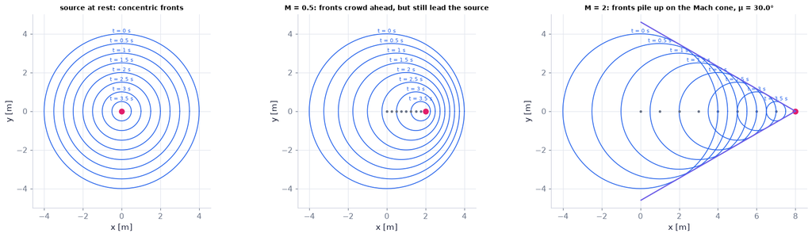

```
M = 0.0: fronts reach 0.50 ahead of the source
M = 0.5: fronts reach 0.25 ahead of the source
M = 2.0: Mach angle 30.0°
```

```python
fronts = [AC.source_wavefronts(U, 1.0, 4.0, 8, 0.5) for U in (0.0, 0.5, 2.0)]   # c = 1; fronts emitted every 0.5 s up to t = 4 s
fig = draw_wavefront_panels(fronts)                          # one panel per source speed
plt.show()
for w in fronts:                                             # the numbers behind the pictures
    print(f"M = {w['M']}: Mach angle {np.degrees(w['mu']):.1f}°" if w["M"] >= 1 else f"M = {w['M']}: fronts reach {w['ahead'][0]:.2f} ahead of the source")
```

**What you see.** Fronts emitted every half second by a point source at rest (left), at M = 0.5 (middle) and at M = 2 (right); each circle is centred where the source was when it emitted it.

**How to read it.** At rest the circles are concentric. At M = 0.5 they bunch up ahead but still enclose the source: the news gets ahead of it. At M = 2 every circle lies behind the source and they all touch two straight lines through it — the cone, at 30° to the flight path.

**What would change if…** …the source moved at exactly M = 1? Every circle would touch the source itself: the fronts pile up into a plane wall through it (μ = 90°).

```python
from matplotlib.patches import Circle                         # circle artists
n_frames = 10 if FAST else 16                                 # frames (each two-panel frame costs 1–3 s to draw)
T, dt, Nmax = 5.0, 0.5, 10                                    # total time, emission interval, most fronts shown
times = np.linspace(0.01, T, n_frames)                        # [s] (c = 1 m/s)
fig, axes = plt.subplots(1, 2, figsize=(9.6, 3.4))            # M = 0.5 and M = 2 side by side
panels = []
for ax, M in zip(axes, (0.5, 2.0)):                           # set up each panel once
    circles = [ax.add_patch(Circle((0, 0), 0.0, fill=False, color=COLORS["blue"], lw=1)) for _ in range(Nmax)]
    (src,) = ax.plot([], [], "o", color=COLORS["rose"], ms=6)  # the source
    (up,) = ax.plot([], [], color=COLORS["orange"], lw=1.5)    # the cone (upper generator)
    (dn,) = ax.plot([], [], color=COLORS["orange"], lw=1.5)    # the cone (lower generator)
    ax.set(xlim=(-5.5, 11), ylim=(-5.5, 5.5), aspect="equal", title=f"source at M = {M}")
    ax.set_xticks([]); ax.set_yticks([])
    panels.append((M, circles, src, up, dn))
def update(i):                                                # frame i
    t = times[i]
    out = []
    for M, circles, src, up, dn in panels:
        n = min(int(t / dt), Nmax)                            # fronts emitted so far (the source started at x = 0, t = 0)
        w = AC.source_wavefronts(M, 1.0, t, max(n, 1), dt)    # centres and radii of the fronts
        for k, cir in enumerate(circles):
            cir.set_visible(k < n)                            # only fronts already emitted
            if k < n:
                cir.center = (w["x_centres"][k], 0.0); cir.set_radius(w["radii"][k])
        xs = w["x_source"]; src.set_data([xs], [0.0])         # the source now
        if M > 1:                                             # the envelope: two lines at the Mach angle
            L = M * t; mu = np.arcsin(1 / M)
            up.set_data([xs, xs - L * np.cos(mu)], [0, L * np.sin(mu)]); dn.set_data([xs, xs - L * np.cos(mu)], [0, -L * np.sin(mu)])
        out += circles + [src, up, dn]
    return out   # all artists of this frame (circles, sources, Mach lines)
show_animation(animate(update, frames=n_frames, fig=fig, interval=80), player="video")   # smooth motion: video
```

[video not shown]

**Animation A4.** Two sources start at x = 0 and send out a front every half second (c = 1). Left M = 0.5, right M = 2; on the right the envelope (orange) appears by itself.

**What you see.** Growing circles of news behind a moving source; on the right, two orange lines through the source that every circle touches.

**How to read it.** Nobody draws the cone: it is just where the circles crowd together. A listener below the right-hand source hears nothing until an orange line sweeps over them — and then hears the accumulated news all at once: the boom.

**What would change if…** …the source slowed from 2 to 1.2? The cone would open from 30° to 56°: the boom arrives sooner after the aircraft passes overhead.

> 📎 **Primer — the envelope of a family of circles.** `P368` · A curve that touches every member of a family is its envelope. For circles whose centres lie on a line and whose radii grow in proportion to the distance from a point P, the envelope is the pair of tangents from P. A tangent meets the radius at its touching point at a right angle — that right angle makes the triangle.

```python
d, r = 2.0, 1.0                               # centre 2 behind the apex, radius 1
mu = np.degrees(np.arcsin(r/d))               # angle of the tangent from the apex
print(mu)                                     # 30 degrees: sin(mu) = r/d
```

```
30.000000000000004
```

#### 🧮 Derivation — The Mach angle `D25` ★ (Eq. 15.49: $\sin\mu=1/M$)

**What we want to show.** Find the half-angle of the cone behind a source that moves faster than sound.

**Assumptions.** Uniform gas; constant U > c; weak disturbances (they travel at c).

**The plan.**

1. Follow one front for a time Δt.
2. The cone touches it.
3. a right triangle.

**Tools we use** (each explained before this point): the envelope of a family of circles (primer P368)

**We start from**

$$ \text{a front emitted at } t_e:\ \ \lvert\mathbf x-\mathbf x_s(t_e)\rvert=c\,(t-t_e),\qquad \mathbf x_s(t)=(Ut,0),\ U>c $$

*In words:* A source moving at speed U through still gas of sound speed c, emitting all the time; a front emitted at one instant is a sphere growing at c from where the source was.

**Step 1 of 4 — Follow one front for a time Δt.**

$$ \text{radius}=c\,\Delta t,\qquad\text{distance to the source}=U\,\Delta t $$

- *Why we can do this:* The front grows at the sound speed from the emission point; meanwhile the source moves on at U.
- *In words:* After Δt the source is UΔt ahead of the centre of a circle of radius cΔt.

**Step 2 of 4 — Draw the cone as the common tangent.**

$$ \text{tangent}\perp\text{radius} $$

- *Why we can do this:* Every front's radius is the same fraction c/U of its distance behind the source, so the envelope is the pair of tangents from the source; a tangent is perpendicular to the radius (primer P368).
- *In words:* Source, centre and touching point form a right triangle.

**Step 3 of 4 — Read the triangle.**

$$ \sin\mu=\dfrac{c\,\Delta t}{U\,\Delta t} $$

- *Why we can do this:* μ is the angle at the source between the flight path and the tangent: opposite side cΔt, hypotenuse UΔt.
- *In words:* The sine of the half-angle is sound's distance over the source's distance.

**Step 4 of 4 — Cancel Δt.**

$$ \sin\mu=\dfrac1M\ \text{(15.49)} $$

- *Why we can do this:* $M=U/c$; the result is the same for every front, which is why the envelope is a straight cone. Needs M ≥ 1.
- *In words:* The faster the source, the narrower the cone.

**Result**

$$ \sin\mu=1/M\ \text{(15.49).} $$

**What it means.** The two-dimensional form of "no news upstream": outside the cone nothing has been heard. Mach lines are the paths along which every weak disturbance of a steady supersonic flow travels. **Fails when:** the source is strong (the front is then a shock, steeper than μ — C14) or the gas is not uniform (the cone bends).

**Check it.** Units — a number ✓. Limits — M = 1: μ = 90° (a plane front through the source); M → ∞: μ → 0. Number — M = 2: 30°. Code — the envelope of 200 computed circles has the slope tan 30°.

(μ is the Mach angle here; a viscosity in §15.6 — trap T5.)

> ⚠️ **Common confusion (traps in `D25`):** μ is measured from the direction of motion; there is no real angle for M < 1; μ is the Mach angle here, not a viscosity (trap T5).

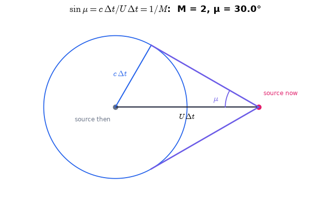

```python
fig = draw_mach_triangle(2.0)                                 # the right triangle behind sin(mu) = 1/M, for M = 2
plt.show()
```

**What you see.** The right triangle of D25 for M = 2: the source, the centre of an old front, and the point where the cone touches it.

**How to read it.** Hypotenuse UΔt, opposite side cΔt, right angle at the touching point: $\sin\mu=1/M$ = 0.5, μ = 30°.

**What would change if…** …M were 3? The opposite side would be a third of the hypotenuse: μ = 19.5°, a slender cone.

📝 **Note.** **N92 [B]** Inside the cone: the **zone of action**; outside: the **zone of silence**. The cone's generators are **Mach lines**. (Ours:) an aircraft at height h passes overhead; the boom arrives $t_{\text{delay}}=\dfrac{h\sqrt{M^2-1}}{Mc}$ (ours) later.

```python
print(AC.mach_cone_delay(1.0e4, 1.5, 295.1))                  # 10 km up, M = 1.5, c = 295 m/s: the boom arrives 25.3 s after overhead
xg = np.array([-1.0, 1.0, 3.0]); yg = np.array([1.0, 1.0, 1.0])   # three points, x measured DOWNSTREAM of the source (behind the aircraft)
print(AC.in_zone_of_action(xg, yg, 2.0))                      # ahead: False; 1 behind: False (sqrt(3) > 1); 3 behind: True
```

```
25.257742883765836
[False False  True]
```

> 📎 **Primer — hyperbolic against elliptic equations.** `P369` · Elliptic: every point influences every other (subsonic flow, Laplace's equation; reminder P201). Hyperbolic: influence travels only along special lines, the characteristics (waves; reminder P174, P227). Steady supersonic flow is hyperbolic with the downstream distance playing the part of time, and its characteristics are the Mach lines.

```python
for M in (0.5, 2.0):                          # the sign of 1 - M^2 decides the type
    print(M, 'elliptic' if 1 - M*M > 0 else 'hyperbolic')
```

```
0.5 elliptic
2.0 hyperbolic
```

#### ✏️ Tiny example: three Mach numbers

$\sin\mu=1/M$ (15.49): M = 2 → sin μ = 0.5 → μ = **30°**. M = 1.2 → sin μ = 0.833 → μ = 56.4° (a blunt cone). M = 3 → μ = 19.5° (a slender one). M = 1 → μ = 90°: a plane front. M < 1: sin μ > 1, no cone.

```python
print(np.degrees(GD.mach_angle(np.array([1.0, 1.2, 1.5, 2.0, 3.0]))))   # 90, 56.44, 41.81, 30.00, 19.47 degrees
print(GD.mach_angle(0.8))                                     # nan: no cone below Mach 1
print(GD.mach_from_angle(np.deg2rad(30.0)))                   # the inverse: 2.0
```

```
[90.     56.4427 41.8103 30.     19.4712]
nan
2.0000000000000004
```

**What does the code above do?**

`GD.mach_angle` is $\sin\mu=1/M$ (15.49) in radians (converted to degrees for printing); it returns NaN below Mach 1, and `GD.mach_from_angle` inverts it.

```python
w = AC.source_wavefronts(2.0, 1.0, 1.0, 200, 0.005)           # 200 fronts of a source at M = 2 (c = 1)
xs = np.linspace(w["x_source"] - 0.9, w["x_source"] - 0.1, 50)   # stations behind the source
y_top = [max(np.sqrt(np.clip(r**2 - (x - xc)**2, 0, None)) for xc, r in zip(w["x_centres"], w["radii"])) for x in xs]   # the envelope: highest circle at each x
slope = np.polyfit(xs, y_top, 1)[0]                           # a straight-line fit (np.polyfit, degree 1) of that edge
assert np.allclose(np.arctan(-slope), GD.mach_angle(2.0), rtol=1e-3)   # its angle is the Mach angle
print(np.degrees(np.arctan(-slope)))                          # 30.0 degrees
```

```
30.002138004164024
```

**From scratch.** Draw 200 fronts, take the highest circle above each station behind the source (the envelope), fit a straight line to it with `np.polyfit(x, y, 1)` (slope and intercept of the best line): its angle is 30.0°, the Mach angle.

#### 🎮 Interactive: Why do you hear it only after it has passed?

**Why interactive rather than a static figure:** you play time and each circle grows from where the source was; above Mach 1 the circles cross and their envelope appears by itself; you drag an observer and read "not yet … now … heard" — the delay is something you experience.

Start with the **Walkthrough**; the **Explain** tab works every number out with your settings, and the **Derivation** tab (where there is one) steps through the same derivation as above. The Mach angle μ is computed in radians and shown in degrees; the source moves to the right.

**What to try:**

- Play at M = 0.5, then M = 1, then M = 2.
- Click a circle: where was the source when it left?
- Drag the observer below the flight path and read the delay.

```python
show_viz("ch15", "mach_cone")   # full-width explainer; ⤢ Full screen for more room
```

🎮 Interactive 6/9 Why do you hear it only after it has passed? Open alone ↗

[interactive chart not shown]

**What would change if…** …the disturbance were not infinitely weak — a wedge that really turns the flow? The Mach line steepens into an oblique shock. C14.

### 🧩 Turning a supersonic stream into itself: $\tan\delta=2\cot\sigma\,\dfrac{M_1^2\sin^2\sigma-1}{M_1^2(\gamma+\cos2\sigma)+2}$ (15.53) `C14`

*The question:* A supersonic stream meets a wedge. At what angle does the shock stand — and how sharp can the wedge be before no such shock exists?

#### The problem in plain words

The nose of a supersonic aircraft, the lip of an engine intake, a bullet: each forces the air to turn. The air cannot be warned (no news upstream), so it turns all at once, through a thin sloping front. Here is the trick that makes it easy: walk along the front at just the right speed and the flow you see comes straight at the front — a *normal* shock. So an oblique shock is a normal shock on the component of the velocity normal to it; the component along it passes through untouched.

#### The idea

```
V₁ = (u₁ ⟂ shock, v ∥ shock)  ──►  V₂ = (u₂ < u₁, v unchanged)
```

The normal part is shocked: replace $M_1$ by $M_1\sin\sigma$ everywhere in C07.

> 🔁 **Tools from earlier chapters used in this block** (one line each; the full primers are in the chapters named)
- **small-angle approximation** — for an angle ε in radians, sin ε ≈ tan ε ≈ ε and cos ε ≈ 1, with errors of order ε³ and ε²; here it turns the oblique-shock formula into the weak-wave rule. *(Ch. 3, P100)*
- **`scipy.optimize.minimize_scalar` (cross-check of the maximum)** — `minimize_scalar(f, bounds=(a, b), method="bounded")` finds the minimum of a function of one variable inside a bracket; here (on −δ) it cross-checks the largest deflection a shock can give. *(Ch. 7, P170)*

📝 **Note.** **N93 [B]** The geometry: shock angle σ from the upstream direction, deflection δ; $(u_1,v)=V_1(\sin\sigma,\cos\sigma)$, $(u_2,v)=V_2(\sin(\sigma-\delta),\cos(\sigma-\delta))$.

> ⚠️ **Common confusion** (trap T13): the book's σ and δ are the β and θ of most other sources; both pairs are in the legends.

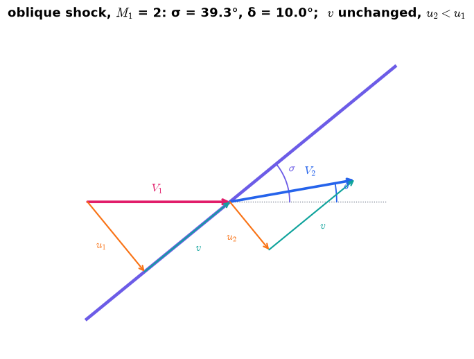

```
σ (= β elsewhere) = 39.31°, δ (= θ elsewhere) = 10.0°
```

```python
w = GD.oblique_shock(wedge["M1"], delta=wedge["delta"])       # the weak shock for our 10° wedge at Mach 2
fig = draw_shock_triangles(wedge["M1"], w["sigma"], wedge["delta"])   # velocity triangles ahead of and behind the shock
plt.show()
print(f"σ (= β elsewhere) = {np.degrees(w['sigma']):.2f}°, δ (= θ elsewhere) = {np.degrees(wedge['delta']):.1f}°")
```

**What you see.** An oblique shock at σ = 39.3° turning a Mach 2 stream through δ = 10°, with the velocity split into the part across the shock (u) and the part along it (v), ahead and behind.

**How to read it.** The along-shock part v is the same on both sides; only the across part shrinks (u₂ < u₁). That alone turns the velocity toward the shock — by δ.

**What would change if…** …σ were 90°? There would be no along part: a normal shock, no turn.

> 📎 **Primer — resolving a velocity along and across a tilted line.** `P370` · Any velocity is the sum of a part along a line and a part across it: for a line at angle σ to the velocity, across = V sin σ, along = V cos σ. An observer sliding along the line at the "along" speed sees only the "across" part — and sliding at constant speed changes no pressure, density or temperature (reminder: P96).

```python
V, sigma = 680.6, np.deg2rad(39.31)            # Mach 2 at sea level; a 39.31 degree shock
print(V*np.sin(sigma), V*np.cos(sigma))         # across 431.2 m/s (Mach 1.267), along 526.6 m/s
```

```
431.17093758539187 526.6004012358271
```

#### 🧮 Derivation — An oblique shock is a normal shock on the normal component `D26` ★★ (Eq. 15.50: $\dfrac{p_2}{p_1}=1+\dfrac{2\gamma}{\gamma+1}\left(M_1^2\sin^2\sigma-1\right)$)

**What we want to show.** Show that every jump relation of the normal shock holds for an oblique shock if the Mach numbers are replaced by their components normal to the shock.

**Assumptions.** Steady, planar, adiabatic, no forces along the shock other than pressure (which is the same on both ends of the box).

**The plan.**

1. Split both velocities along and across the shock.
2. Mass and tangential momentum show the along-component is unchanged.
3. It then drops out of the energy law.
4. What is left is the normal-shock problem.

**Tools we use** (each explained before this point): resolving a velocity along and across a tilted line (primer P370) · the Galilean shift (P96 reminder) · D13–D15

**We start from**

$$ \text{a plane shock at angle }\sigma\text{ to }V_1\text{, turning the flow through }\delta $$

*In words:* The control-volume laws of C03 for a thin box enclosing a piece of the shock.

**Step 1 of 8 — Resolve the velocities.**

$$ u_1=V_1\sin\sigma,\ v_1=V_1\cos\sigma;\qquad u_2=V_2\sin(\sigma-\delta),\ v_2=V_2\cos(\sigma-\delta) $$

- *Why we can do this:* u is across the shock, v along it; behind the shock the flow makes the angle σ − δ with the shock.
- *In words:* Each velocity is split into a part that crosses the shock and a part that slides along it.

**Step 2 of 8 — Mass through the box.**

$$ \rho_1u_1=\rho_2u_2 $$

- *Why we can do this:* Only the normal component carries mass through the shock.
- *In words:* The same as for a normal shock, with u the normal component.

**Step 3 of 8 — Momentum along the shock.**

$$ \rho_1u_1v_1=\rho_2u_2v_2\ \Rightarrow\ v_1=v_2\equiv v $$

- *Why we can do this:* The flux of tangential momentum is (mass flux) × v; no net force acts along the shock. Divide by the equal mass fluxes of step 2.
- *In words:* The shock does not change the speed along itself.

**Step 4 of 8 — Momentum across the shock, and the normal Mach numbers.**

$$ p_1+\rho_1u_1^2=p_2+\rho_2u_2^2;\qquad M_{n1}=\dfrac{u_1}{c_1}=M_1\sin\sigma,\quad M_{n2}=\dfrac{u_2}{c_2}=M_2\sin(\sigma-\delta) $$

- *Why we can do this:* The normal momentum balance involves u only; dividing step 1 by each side's sound speed gives the normal Mach numbers.
- *In words:* Across the shock, pressure plus normal momentum flux is conserved.

**Step 5 of 8 — Energy.**

$$ h_1+\tfrac12\left(u_1^2+v^2\right)=h_2+\tfrac12\left(u_2^2+v^2\right)\ \Rightarrow\ h_1+\tfrac12u_1^2=h_2+\tfrac12u_2^2 $$

- *Why we can do this:* $h_2+\tfrac12u_2^2-h_1-\tfrac12u_1^2=Q$ (15.22) with Q = 0 and the full speed; the same $\tfrac12v^2$ stands on both sides and cancels.
- *In words:* The energy law also involves only the normal component.

**Step 6 of 8 — Recognise the normal-shock problem; pressure.**

$$ \dfrac{p_2}{p_1}=1+\dfrac{2\gamma}{\gamma+1}\left(M_1^2\sin^2\sigma-1\right)\ \text{(15.50)} $$

- *Why we can do this:* Steps 2, 4, 5 are the three jump laws $\rho_1u_1=\rho_2u_2$ (15.35), $p_1-p_2=-\rho_1u_1^2+\rho_2u_2^2$ (15.36), $h_1+\tfrac12u_1^2=h_2+\tfrac12u_2^2$ (15.37) for $(u_1,u_2)$, so $\dfrac{p_2}{p_1}=1+\dfrac{2\gamma}{\gamma+1}\left(M_1^2-1\right)$ (15.39) holds with $M_1\to M_{n1}$: an observer sliding along the shock at v sees a normal shock.
- *In words:* The pressure jump of a normal shock at the normal Mach number.

**Step 7 of 8 — Density, and the geometry.**

$$ \dfrac{\rho_2}{\rho_1}=\dfrac{(\gamma+1)M_1^2\sin^2\sigma}{(\gamma-1)M_1^2\sin^2\sigma+2}=\dfrac{u_1}{u_2}=\dfrac{\tan\sigma}{\tan(\sigma-\delta)}\ \text{(15.51)} $$

- *Why we can do this:* $\dfrac{\rho_2}{\rho_1}=\dfrac{u_1}{u_2}=\dfrac{(\gamma+1)M_1^2}{(\gamma-1)M_1^2+2}$ (15.41) with $M_{n1}$; and from step 1 with equal v: $u_1=v\tan\sigma$, $u_2=v\tan(\sigma-\delta)$.
- *In words:* The density ratio equals a ratio of two tangents — this ties the shock angle to the turn.

**Step 8 of 8 — Downstream Mach number.**

$$ M_2^2\sin^2(\sigma-\delta)=\dfrac{(\gamma-1)M_1^2\sin^2\sigma+2}{2\gamma M_1^2\sin^2\sigma+1-\gamma}\ \text{(15.52)} $$

- *Why we can do this:* $M_2^2=\dfrac{(\gamma-1)M_1^2+2}{2\gamma M_1^2+1-\gamma}$ (15.40) with both normal Mach numbers of step 4.
- *In words:* The *normal* Mach number behind is subsonic; $M_2$ itself is that divided by sin(σ − δ), and may exceed 1.

**Result**

$$ \begin{array}{l}\dfrac{p_2}{p_1}=1+\dfrac{2\gamma}{\gamma+1}\left(M_1^2\sin^2\sigma-1\right)\ \text{(15.50),}\ \dfrac{\rho_2}{\rho_1}=\dfrac{(\gamma+1)M_1^2\sin^2\sigma}{(\gamma-1)M_1^2\sin^2\sigma+2}=\dfrac{\tan\sigma}{\tan(\sigma-\delta)} \\ \text{(15.51),}\ M_2^2\sin^2(\sigma-\delta)=\dfrac{(\gamma-1)M_1^2\sin^2\sigma+2}{2\gamma M_1^2\sin^2\sigma+1-\gamma}\ \text{(15.52).}\end{array} $$

**What it means.** All the tables and formulas of the normal shock serve for oblique shocks with $M_1\sin\sigma$. The flow turns *toward* the shock because only its normal component is slowed. **Fails when:** the shock is curved (then v varies along it and the flow behind is rotational).

**Check it.** Units — numbers ✓. Limits — σ = 90°: the normal shock; σ = μ ($M_1\sin\sigma=1$): no jump — a Mach wave. Number — $M_1$ = 2, σ = 39.31°: $M_{n1}$ = 1.267, $p_2/p_1$ = 1.707, density ratio 1.458 = tan 39.31°/tan 29.31° ✓, $M_2$ = 0.803/0.4896 = 1.641. Code — `ch15.tangential_momentum_sympy()`.

📝 **Notes taught inside `D26`:** **N94 [B]** the normal Mach numbers $M_{n1}=M_1\sin\sigma,\ \ M_{n2}=M_2\sin(\sigma-\delta)$ (unnumbered, §15.9) (step 4) · **N95 [B]** $\dfrac{p_2}{p_1}=1+\dfrac{2\gamma}{\gamma+1}\left(M_1^2\sin^2\sigma-1\right)$ (15.50) (step 6) · **N96 [B]** $\dfrac{\rho_2}{\rho_1}=\dfrac{(\gamma+1)M_1^2\sin^2\sigma}{(\gamma-1)M_1^2\sin^2\sigma+2}=\dfrac{\tan\sigma}{\tan(\sigma-\delta)}$ (15.51) (step 7) · **N97 [B]** $M_2^2\sin^2(\sigma-\delta)=\dfrac{(\gamma-1)M_1^2\sin^2\sigma+2}{2\gamma M_1^2\sin^2\sigma+1-\gamma}$ (15.52) (step 8; ⚠️ trap T13: $M_2$ needs the division by $\sin(\sigma-\delta)$)

> ⚠️ **Common confusion (traps in `D26`):** The mass flux uses the normal component only; $M_2$ needs the division by sin(σ − δ) (trap T13); σ and δ are β and θ in most other books.

```python
tm = ch15.tangential_momentum_sympy()                         # sympy: mass and tangential momentum force v1 = v2
print(tm["v2"], "| residual:", tm["residual"])                # v2 equals v1; residual 0
```

```
v_1 | residual: 0
```

> 📎 **Primer — the tangent subtraction formula.** `P371` · $\tan(\sigma-\delta)=\dfrac{\tan\sigma-\tan\delta}{1+\tan\sigma\tan\delta}$, and the double angle $\cos2\sigma=1-2\sin^2\sigma$ (reminder: P341, ch14).

```python
s, d = np.deg2rad(39.31), np.deg2rad(10.0)
print(np.tan(s - d), (np.tan(s) - np.tan(d))/(1 + np.tan(s)*np.tan(d)))   # 0.5613 both
print(np.cos(2*s), 1 - 2*np.sin(s)**2)                                    # 0.1972 both
```

```
0.5614033464653208 0.5614033464653206
0.19731514915291049 0.19731514915291049
```

#### 🧮 Derivation — Deflection against shock angle `D27` ★★ (Eq. 15.53: $\tan\delta=2\cot\sigma\,\dfrac{M_1^2\sin^2\sigma-1}{M_1^2(\gamma+\cos2\sigma)+2}$)

**What we want to show.** Find the turn δ produced by a shock at angle σ.

**Assumptions.** As D26.

**The plan.**

1. Expand tan(σ − δ).
2. Collect tan δ.
3. Insert the density ratio.
4. Tidy with a double angle.

**Tools we use** (each explained before this point): the tangent subtraction formula (primer P371)

**We start from**

$$ \begin{array}{l}\text{the last equality of}\ \dfrac{\rho_2}{\rho_1}=\dfrac{(\gamma+1)M_1^2\sin^2\sigma}{(\gamma-1)M_1^2\sin^2\sigma+2}=\dfrac{\tan\sigma}{\tan(\sigma-\delta)}\ \text{(15.51),} \\ \dfrac{\tan\sigma}{\tan(\sigma-\delta)}=\dfrac{\rho_2}{\rho_1}\equiv\hat\rho\ \text{.}\end{array} $$

**Step 1 of 8 — Solve for the downstream tangent.**

$$ \tan(\sigma-\delta)=\dfrac{\tan\sigma}{\hat\rho} $$

- *Why we can do this:* Multiply both sides by $\tan(\sigma-\delta)$ and divide by $\hat\rho$ (a density ratio, never zero); this isolates the only factor that contains δ.
- *In words:* The flow leaves at a flatter angle to the shock, flatter by the density ratio.

**Step 2 of 8 — Expand the left side.**

$$ \dfrac{\tan\sigma-\tan\delta}{1+\tan\sigma\tan\delta}=\dfrac{\tan\sigma}{\hat\rho} $$

- *Why we can do this:* The subtraction formula (primer P371). Now tan δ is explicit.
- *In words:* An equation with tan δ in two places.

**Step 3 of 8 — Cross-multiply.**

$$ \hat\rho\left(\tan\sigma-\tan\delta\right)=\tan\sigma\left(1+\tan\sigma\tan\delta\right) $$

- *Why we can do this:* Both denominators are positive for 0 < δ < σ < 90°.
- *In words:* No fractions.

**Step 4 of 8 — Collect tan δ.**

$$ \tan\delta\left(\hat\rho+\tan^2\sigma\right)=\left(\hat\rho-1\right)\tan\sigma $$

- *Why we can do this:* Move the two terms with tan δ to one side.
- *In words:* tan δ appears once.

**Step 5 of 8 — Solve.**

$$ \tan\delta=\dfrac{\left(\hat\rho-1\right)\tan\sigma}{\hat\rho+\tan^2\sigma} $$

- *Why we can do this:* Divide. Already a usable result: no compression ($\hat\rho=1$), no turn.
- *In words:* The turn in terms of the density ratio and the shock angle.

**Step 6 of 8 — Insert the density ratio.**

$$ \tan\delta=\dfrac{2\,(m-1)\tan\sigma}{(\gamma+1)\,m+\left[(\gamma-1)\,m+2\right]\tan^2\sigma},\qquad m\equiv M_1^2\sin^2\sigma $$

- *Why we can do this:* From $\dfrac{\rho_2}{\rho_1}=\dfrac{(\gamma+1)M_1^2\sin^2\sigma}{(\gamma-1)M_1^2\sin^2\sigma+2}=\dfrac{\tan\sigma}{\tan(\sigma-\delta)}$ (15.51), $\hat\rho=\dfrac{(\gamma+1)m}{(\gamma-1)m+2}$, so $\hat\rho-1=\dfrac{2(m-1)}{(\gamma-1)m+2}$; multiply top and bottom by $(\gamma-1)m+2$.
- *In words:* Everything in $M_1$, σ and γ.

**Step 7 of 8 — Multiply top and bottom by cos²σ/sin²σ.**

$$ \tan\delta=2\cot\sigma\,\dfrac{M_1^2\sin^2\sigma-1}{(\gamma+1)M_1^2\cos^2\sigma+(\gamma-1)M_1^2\sin^2\sigma+2} $$

- *Why we can do this:* $\tan\sigma\cos^2\sigma/\sin^2\sigma=\cot\sigma$; $m/\sin^2\sigma=M_1^2$; $\tan^2\sigma\cos^2\sigma/\sin^2\sigma=1$. Multiplying top and bottom of a fraction by the same non-zero factor leaves it unchanged; this puts it in the book's shape.
- *In words:* The book's shape, except for the denominator.

**Step 8 of 8 — Gather the denominator with a double angle.**

$$ \tan\delta=2\cot\sigma\,\dfrac{M_1^2\sin^2\sigma-1}{M_1^2(\gamma+\cos2\sigma)+2}\ \text{(15.53)} $$

- *Why we can do this:* $(\gamma+1)\cos^2\sigma+(\gamma-1)\sin^2\sigma=\gamma+(\cos^2\sigma-\sin^2\sigma)=\gamma+\cos2\sigma$. These are the identities cos² + sin² = 1 and cos 2σ = cos²σ − sin²σ; they shorten the denominator.
- *In words:* The turn as a function of the shock angle, for a given upstream Mach number.

**Result**

$$ \tan\delta=2\cot\sigma\,\dfrac{M_1^2\sin^2\sigma-1}{M_1^2(\gamma+\cos2\sigma)+2}\ \text{(15.53).} $$

**What it means.** Between its two zeros δ rises to a maximum and falls again: for each turn below the maximum there are two shock angles (weak and strong), and above it none — the shock detaches. **Fails when:** δ exceeds the maximum (no straight attached shock exists).

**Check it.** Units — numbers ✓. Zeros — δ = 0 where $M_1\sin\sigma=1$ (σ = μ) and where cot σ = 0 (σ = 90°). Number — $M_1$ = 2, σ = 39.31°: 2 × 1.2213 × 0.6056/8.389 = 0.1763 → 10.0°; σ = 45°: 2 × 1 × 1/7.6 → 14.74°. Code — `GD.deflection_angle`.

> ⚠️ **Common confusion (traps in `D27`):** Collect tan δ before solving; the formula gives δ from σ — the inverse needs a root-finder on each side of the maximum (primer P360); "weak" and "strong" are names of roots (trap T13).

#### ✏️ Tiny example: a 10° wedge at Mach 2

γ = 1.4. Trial: σ = 39.31° (sin σ = 0.6336, sin² σ = 0.4014, cos 2σ = 0.1972, cot σ = 1.2213).

1. $\tan\delta=2\cot\sigma\,\dfrac{M_1^2\sin^2\sigma-1}{M_1^2(\gamma+\cos2\sigma)+2}$ (15.53): tan δ = 2 × 1.2213 × (4 × 0.4014 − 1)/(4 × (1.4 + 0.1972) + 2) = 2.4426 × 0.6056/8.389 = 0.1763 → δ = **10.0°** ✓.
2. Normal Mach number: $M_{n1}$ = 2 × 0.6336 = **1.267**.
3. $\dfrac{p_2}{p_1}=1+\dfrac{2\gamma}{\gamma+1}\left(M_1^2\sin^2\sigma-1\right)$ (15.50): $p_2/p_1$ = 1 + 1.1667 × (1.6056 − 1) = **1.707**.
4. $M_2^2=\dfrac{(\gamma-1)M_1^2+2}{2\gamma M_1^2+1-\gamma}$ (15.40) on 1.267: $M_{n2}$ = 0.803; divide by sin(39.31° − 10°) = 0.4896: $M_2$ = **1.64** — still supersonic.
5. The other solution of $\tan\delta=2\cot\sigma\,\dfrac{M_1^2\sin^2\sigma-1}{M_1^2(\gamma+\cos2\sigma)+2}$ (15.53) for the same 10°: σ = 83.7°, $p_2/p_1$ = 4.44, $M_2$ = 0.60 — nearly a normal shock.

```python
w = GD.oblique_shock(2.0, delta=wedge["delta"])                         # weak root (the default branch)
s = GD.oblique_shock(2.0, delta=wedge["delta"], branch="strong")        # strong root
for name, d in (("weak", w), ("strong", s)):
    print(name, f"σ = {np.degrees(d['sigma']):.2f}°", {k: round(float(d[k]), 4) for k in ("Mn1", "p_ratio", "rho_ratio", "T_ratio", "M2", "p0_ratio")})
print({k: round(float(v), 4) for k, v in GD.oblique_shock_components(2.0, w["sigma"]).items()})   # the split velocities, normal Mach numbers
mx = GD.max_deflection(2.0)                                   # the largest turn at Mach 2
print(f"δ_max = {np.degrees(mx['delta_max']):.2f}° at σ = {np.degrees(mx['sigma_max']):.2f}°")   # 22.97° at 64.67°
try:                                                          # a 25° wedge at Mach 2 …
    GD.oblique_shock(2.0, delta=np.deg2rad(25.0))
except ValueError as err:                                     # … has no attached shock
    print("ValueError:", err)
print(GD.detachment_mach(np.deg2rad(10.0)))                   # the slowest stream that keeps a shock attached to a 10° wedge: 1.421
```

```
weak σ = 39.31° {'Mn1': 1.2671, 'p_ratio': 1.7066, 'rho_ratio': 1.4584, 'T_ratio': 1.1702, 'M2': 1.6405, 'p0_ratio': 0.9846}
strong σ = 83.70° {'Mn1': 1.9879, 'p_ratio': 4.4438, 'rho_ratio': 2.6487, 'T_ratio': 1.6777, 'M2': 0.6037, 'p0_ratio': 0.7265}
{'Mn1': 1.2671, 'Mt1': 1.5474, 'Mn2': 0.8032, 'M2': 1.6405, 'delta': 0.1745, 'u1_over_V1': 0.6336, 'v_over_V1': 0.7737, 'u2_over_V1': 0.4344, 'V2_over_V1': 0.8873, 'c2_over_c1': 1.0817}
δ_max = 22.97° at σ = 64.67°
ValueError: detached: delta = 25.0000 deg exceeds delta_max = 22.9735 deg at M1 = 2; no attached oblique shock
1.42097584637072
```

**What does the code above do?**

1. The weak shock: σ = 39.31°, $M_{n1}$ = 1.267, pressure × 1.707, density × 1.458, temperature × 1.170, $M_2$ = 1.641, and only 1.5 % of the stagnation pressure lost. The strong one: σ = 83.70°, pressure × 4.44, $M_2$ = 0.604.
2. `GD.oblique_shock_components` lists the pieces of D26: the normal and tangential parts and both normal Mach numbers.
3. The largest turn at Mach 2 is 22.97°, at σ = 64.67°. Ask for 25° and the function raises "detached".
4. Turned round: a 10° wedge keeps its shock attached only above Mach 1.421.

```python
g, M1, delta = 1.4, 2.0, np.deg2rad(10.0)                     # gas, Mach number, wedge half-angle
tan_delta = lambda s: 2/np.tan(s)*(M1**2*np.sin(s)**2 - 1)/(M1**2*(g + np.cos(2*s)) + 2)   # (15.53)
mu = np.arcsin(1 / M1)                                        # the Mach angle: tan(delta) = 0 there
grid = np.linspace(mu + 1e-6, np.pi / 2 - 1e-6, 20001)       # shock angles between the two zeros
s_max = grid[np.argmax(tan_delta(grid))]                      # grid search for the largest deflection
f = lambda s: tan_delta(s) - np.tan(delta)                    # zero where the shock gives 10°
s_weak = brentq(f, mu + 1e-9, s_max)                          # left of the maximum: weak
s_strong = brentq(f, s_max, np.pi / 2 - 1e-9)                 # right of it: strong
assert np.allclose([s_weak, s_strong], [w["sigma"], s["sigma"]], atol=1e-8)   # same roots as the library
print(np.degrees([s_weak, s_max, s_strong]))                  # 39.31, ≈ 64.7, 83.70 degrees
```

```
[39.3139 64.668  83.7001]
```

**From scratch.** $\tan\delta=2\cot\sigma\,\dfrac{M_1^2\sin^2\sigma-1}{M_1^2(\gamma+\cos2\sigma)+2}$ (15.53) in one line; a grid search finds the angle of the largest turn, and one bracketed root on each side of it gives the weak and the strong shock — the two roots of P360 again.

📝 **Note.** **N98 [B]** (The closed form of $\delta_{\max}$ is ours; result given, not derived.) For δ below a maximum there are two shocks: **weak** (smaller σ, usually supersonic behind) and **strong** (larger σ, subsonic behind); δ = 0 at σ = μ (a Mach wave) and at σ = 90° (a normal shock).

> ⚠️ (trap T13) "weak" and "strong" name the two roots, not their size: the "weak" shock for 20° at Mach 2 nearly triples the pressure ($p_2/p_1$ = 2.84).

```python
from scipy.optimize import minimize_scalar                    # minimum of a function of one variable in a bracket
res = minimize_scalar(lambda s_: -GD.deflection_angle(2.0, s_), bounds=(np.arcsin(0.5), np.pi / 2), method="bounded")   # maximise delta
print(np.degrees(-res.fun), np.degrees(GD.max_deflection(2.0)["delta_max"]))   # 22.97 both: a numerical cross-check of the closed form
print(GD.oblique_shock(2.0, delta=np.deg2rad(20.0))["p_ratio"])   # the "weak" shock for 20°: p2/p1 = 2.84
```

```
22.973531760923258 22.97353176093794
2.8428627050361586
```

```python
def curve(M1):                                                # delta against sigma for one upstream Mach number
    c = GD.oblique_shock_curve(M1)                            # (15.53) on 400 shock angles, with its special points
    return {"δ(σ), (15.53)": (np.degrees(c["sigma"]), np.degrees(c["delta"])),   # the curve, in degrees
            "largest turn": ([np.degrees(c["sigma_max"])], [np.degrees(c["delta_max"])]),   # its maximum
            "sonic point (M₂ = 1)": ([np.degrees(c["sigma_sonic"])], [np.degrees(c["delta_sonic"])])}   # where the flow behind is sonic
fig = slider_figure(curve, "M₁", np.linspace(1.2, 5.0, 20), xlabel="shock angle σ (= β elsewhere) [°]",   # slider over M1
                    ylabel="deflection δ (= θ elsewhere) [°]", title="Two shock angles for every turn below the largest",   # both conventions in the labels
                    xrange=[0, 90], yrange=[0, 48], modes={"largest turn": "markers", "sonic point (M₂ = 1)": "markers"})   # fixed axes; dots
fig.show()   # display
```

[interactive chart not shown]

**Figure F8.** Slider: the upstream Mach number, from 1.2 to 5. Each curve is $\tan\delta=2\cot\sigma\,\dfrac{M_1^2\sin^2\sigma-1}{M_1^2(\gamma+\cos2\sigma)+2}$ (15.53); the dots mark the largest turn and the point where the flow behind becomes exactly sonic.

**What you see.** The deflection against the shock angle for the chosen upstream Mach number, with the largest-turn point and the sonic point.

**How to read it.** Draw a horizontal line at your wedge angle: it cuts the curve twice (weak on the left, strong on the right) or not at all. The largest turn is 22.97° at Mach 2, 34.07° at Mach 3, and creeps toward 45.6° for very fast streams. Between the sonic point and the maximum the weak shock already leaves a subsonic flow behind.

**What would change if…** …γ were 5/3? The largest turn at Mach 2 would drop (to about 19°): monatomic gases detach sooner.

📝 **Note.** **N99 [B]** A wedge takes the weak solution; a blunt nose always has a detached shock.

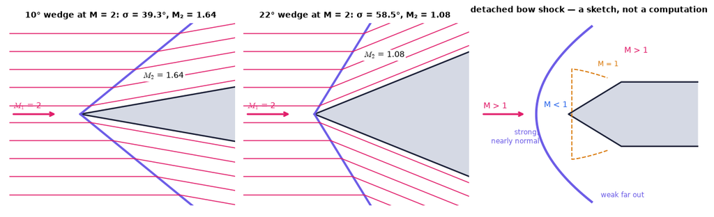

```python
fig, (a, b, c) = plt.subplots(1, 3, figsize=(11.0, 3.4))      # three wedges
for ax, deg in ((a, 10.0), (b, 22.0)):                        # an easy wedge and a nearly detached one
    wf = ch15.wedge_flow(2.0, np.deg2rad(deg))                # the numbers: sigma, M2, p_ratio, attached, subsonic_behind …
    draw_wedge_streamlines(2.0, np.deg2rad(deg), wf["sigma"], ax=ax)   # the helper only draws them
    ax.set_title(f"{deg:.0f}° wedge at M = 2: σ = {np.degrees(wf['sigma']):.1f}°, M₂ = {wf['M2']:.2f}", fontsize=9)
draw_bow_shock_sketch(ax=c)                                   # the blunt case
c.set_title("detached bow shock — a sketch, not a computation", fontsize=9)
plt.show()
```

**What you see.** Left and middle: streamlines through the attached weak shock on a 10° and a 22° wedge at Mach 2. Right: a sketch of the detached bow shock ahead of a body too blunt for an attached shock.

**How to read it.** At 10° the shock leans back at 39° and the flow behind is still supersonic ($M_2$ = 1.64). At 22° — just below the 23° limit — the shock stands up (σ ≈ 58°) and the flow behind is only just supersonic ($M_2$ = 1.08). Beyond the limit the shock leaves the nose and curves: normal on the axis, strong near it, weak far out.

**What would change if…** …the Mach number were raised to 3 for the 22° wedge? The shock would lean back again (σ ≈ 40°) with a supersonic flow behind it.

> ▶️ **Live cell.** The widget below needs a running Python kernel. On the web page it is frozen — open this notebook in Colab (button at the top) or run it locally to drag the sliders.

```python
def show(M1=2.0, delta_deg=10.0):                             # one wedge
    d = np.deg2rad(delta_deg)                                 # half-angle [rad]
    try:   # the exact method raises when the lower shock detaches
        wk = GD.oblique_shock(M1, delta=d); st = GD.oblique_shock(M1, delta=d, branch="strong")   # both roots
        print(f"weak: σ = {np.degrees(wk['sigma']):.2f}°, p2/p1 = {wk['p_ratio']:.3f}, M2 = {wk['M2']:.3f} | "
              f"strong: σ = {np.degrees(st['sigma']):.2f}°, p2/p1 = {st['p_ratio']:.3f}, M2 = {st['M2']:.3f}")
        draw_wedge_streamlines(M1, d, wk["sigma"])            # the picture with the weak root
    except ValueError:                                        # beyond the largest turn
        print("detached: no attached shock for this wedge")
        draw_bow_shock_sketch()
    plt.show()
live(show, M1=(1.2, 5.0, 0.05), delta_deg=(1.0, 40.0, 0.5))   # two sliders (need a running kernel)
```

▶️ **Live cell.** These sliders need a running Python kernel, so they are frozen on this page. Press **Open in Colab** at the top (or run the notebook locally) to use them.

📝 **Note.** **N100 [C]** At a corner the speed is finite in supersonic flow (zero or infinite in subsonic flow — Ch. 6 corner flows, C09), and a supersonic field can be built marching downstream: the hyperbolic property of N92.

> 📎 **Primer — the Mach triangle.** `P372` · A right triangle with hypotenuse M and opposite side 1 has the Mach angle μ: $\sin\mu=1/M$, so $\cos\mu=\sqrt{M^2-1}/M$ and $\cot\mu=\sqrt{M^2-1}$. Every $\sqrt{M^2-1}$ of §15.9–§15.10 is this triangle's third side.

```python
M = 2.0
mu = np.arcsin(1/M)                             # Mach angle: 30 degrees
print(1/np.tan(mu), np.sqrt(M*M - 1))           # cot(mu) = sqrt(M^2 - 1) = 1.732
```

```
1.732050807568877 1.7320508075688772
```

#### 🧮 Derivation — The weak-wave rule `D28` ★★ (Eq. 15.55: $\dfrac{p_2-p_1}{p_1}=\dfrac{\gamma M_1^2}{\sqrt{M_1^2-1}}\,\delta$)

**What we want to show.** Find the pressure rise produced by a very small turn of a supersonic stream.

**Assumptions.** δ ≪ 1 (in radians); the weak root; $M_1$ not close to 1.

**The plan.**

1. Express the numerator of the deflection formula by the pressure jump.
2. Let the turn go to zero: the shock becomes a Mach wave.
3. Evaluate each factor there.

**Tools we use** (each explained before this point): the Mach triangle (primer P372) · small-angle approximation (P100 reminder)

**We start from**

$$ \dfrac{p_2}{p_1}=1+\dfrac{2\gamma}{\gamma+1}\left(M_1^2\sin^2\sigma-1\right)\ \text{(15.50) and}\ \tan\delta=2\cot\sigma\,\dfrac{M_1^2\sin^2\sigma-1}{M_1^2(\gamma+\cos2\sigma)+2}\ \text{(15.53).} $$

**Step 1 of 8 — Solve the pressure relation for the numerator.**

$$ M_1^2\sin^2\sigma-1=\dfrac{\gamma+1}{2\gamma}\,\dfrac{p_2-p_1}{p_1} $$

- *Why we can do this:* $\dfrac{p_2}{p_1}=1+\dfrac{2\gamma}{\gamma+1}\left(M_1^2\sin^2\sigma-1\right)$ (15.50) rearranged. This combination is the numerator of $\tan\delta=2\cot\sigma\,\dfrac{M_1^2\sin^2\sigma-1}{M_1^2(\gamma+\cos2\sigma)+2}$.
- *In words:* How far the normal Mach number is above 1 is the pressure jump, up to a factor.

**Step 2 of 8 — Insert it.**

$$ \tan\delta=2\cot\sigma\,\dfrac{\gamma+1}{2\gamma}\left(\dfrac{p_2-p_1}{p_1}\right)\dfrac{1}{M_1^2(\gamma+\cos2\sigma)+2} $$

- *Why we can do this:* Replace the numerator $M_1^2\sin^2\sigma-1$ of $\tan\delta=2\cot\sigma\,\dfrac{M_1^2\sin^2\sigma-1}{M_1^2(\gamma+\cos2\sigma)+2}$ (15.53) by its equal from step 1; swapping a quantity for an equal one keeps the line exact and brings the pressure jump into the turn formula.
- *In words:* The turn is proportional to the pressure jump.

**Step 3 of 8 — Rewrite the double angle.**

$$ \tan\delta=2\cot\sigma\,\dfrac{\gamma+1}{2\gamma}\left(\dfrac{p_2-p_1}{p_1}\right)\dfrac{1}{M_1^2\left(\gamma+1-2\sin^2\sigma\right)+2}\ \text{(15.54)} $$

- *Why we can do this:* The identity $\cos2\sigma=1-2\sin^2\sigma$ changes nothing (still exact); it writes the denominator in $\sin\sigma$, the quantity whose limit step 5 supplies.
- *In words:* The same, ready for the limit.

**Step 4 of 8 — Small turn.**

$$ \tan\delta\approx\delta $$

- *Why we can do this:* δ ≪ 1 rad (≈): the error is of order δ³.
- *In words:* A small angle equals its tangent.

**Step 5 of 8 — The shock becomes a Mach wave.**

$$ \sin\sigma\to\sin\mu_1=\dfrac{1}{M_1} $$

- *Why we can do this:* As δ → 0 the pressure jump → 0, so by step 1 $M_1\sin\sigma\to1$ (the weak root).
- *In words:* An infinitely weak shock lies along the Mach line.

**Step 6 of 8 — Its cotangent.**

$$ \cot\sigma\to\cot\mu_1=\sqrt{M_1^2-1} $$

- *Why we can do this:* In the Mach triangle (primer P372) the side opposite μ is 1 and the hypotenuse M, so by Pythagoras the adjacent side is $\sqrt{M^2-1}$ and $\cot\mu_1=\sqrt{M_1^2-1}$; σ → μ₁ carries it over.
- *In words:* This is where the square root comes from.

**Step 7 of 8 — The denominator.**

$$ M_1^2\left(\gamma+1-2\sin^2\sigma\right)+2\ \to\ (\gamma+1)M_1^2 $$

- *Why we can do this:* By step 5, $M_1^2\sin^2\sigma\to1$, so $M_1^2\cdot2\sin^2\sigma\to2$, which cancels the $+2$; only $(\gamma+1)M_1^2$ survives.
- *In words:* A simple limit.

**Step 8 of 8 — Assemble and solve for the pressure jump.**

$$ \dfrac{p_2-p_1}{p_1}=\dfrac{\gamma M_1^2}{\sqrt{M_1^2-1}}\,\delta\ \text{(15.55)} $$

- *Why we can do this:* $\delta=2\sqrt{M_1^2-1}\,\dfrac{\gamma+1}{2\gamma}\,\dfrac{p_2-p_1}{p_1}\,\dfrac{1}{(\gamma+1)M_1^2}$; the factors γ + 1 and 2 cancel.
- *In words:* A small turn into the flow raises the pressure in proportion to the turn.

**Result**

$$ \begin{array}{l}\tan\delta=2\cot\sigma\,\dfrac{\gamma+1}{2\gamma}\left(\dfrac{p_2-p_1}{p_1}\right)\dfrac{1}{M_1^2\left(\gamma+1-2\sin^2\sigma\right)+2}\ \text{(15.54) and} \\ \dfrac{p_2-p_1}{p_1}=\dfrac{\gamma M_1^2}{\sqrt{M_1^2-1}}\,\delta\ \text{(15.55).}\end{array} $$

**What it means.** To first order pressure responds linearly to the local turn — and, because the entropy change is third order (D17), the same line holds for small expansions with δ < 0 (N103). This one line is the whole of §15.10. **Fails when:** the turn is not small, or $M_1\to1$ ($\sqrt{M_1^2-1}\to0$).

**Check it.** Units — δ in radians; both sides numbers ✓. Number — $M_1$ = 2, δ = 2° = 0.0349: 1.4 × 4/1.732 × 0.0349 = 0.1129 (exact shock 0.1180). How small is small (trap T16): the rule is 1.1 % low at 0.5°, 10.5 % low at 5°, 20 % low at 10°, 39 % low at 20°. Code — `GD.weak_wave_error`, `ch15.weak_wave_sympy()`.

📝 **Notes taught inside `D28`:** **N101 [B]** $\tan\delta=2\cot\sigma\,\dfrac{\gamma+1}{2\gamma}\left(\dfrac{p_2-p_1}{p_1}\right)\dfrac{1}{M_1^2\left(\gamma+1-2\sin^2\sigma\right)+2}$ (15.54) (steps 1–3) · **N102 [B]** $\dfrac{p_2-p_1}{p_1}=\dfrac{\gamma M_1^2}{\sqrt{M_1^2-1}}\,\delta$ (15.55) (steps 4–8)

> ⚠️ **Common confusion (traps in `D28`):** Three replacements, one per step; δ in radians, positive when the wall turns *into* the flow (trap T14); the rule underestimates compressions and overestimates expansions.

📝 **Note.** **N102 [B], continued**

> ⚠️ **Common confusion** (trap T16): how small is "small"? The cell below compares the linear rule $\dfrac{p_2-p_1}{p_1}=\dfrac{\gamma M_1^2}{\sqrt{M_1^2-1}}\,\delta$ (15.55) with the exact weak shock at $M_1$ = 2. **The rule reads LOW**: about 1 % at 0.5°, 4 % at 2°, 10 % at 5°, 20 % at 10° and 39 % at 20° (equivalently, at 5° the exact value is 12 % above the rule). And the rule fails as $M\to1$: $\sqrt{M^2-1}\to0$.

```python
rows = []                                                     # linear rule against the exact weak shock at M1 = 2
for deg in (0.5, 2.0, 5.0, 10.0, 20.0):
    e = GD.weak_wave_error(2.0, np.deg2rad(deg))              # dict: linear, exact, ratio (exact/linear), rel_error (linear/exact - 1)
    rows.append((deg, e["linear"], e["exact"], -100 * e["rel_error"]))   # rel_error = linear/exact - 1 < 0: the rule is low
print(pd.DataFrame(rows, columns=["δ [°]", "linear (15.55)", "exact shock", "rule low by [%]"]).round(4).to_string(index=False))
print(ch15.weak_wave_sympy()["residual_15_55"])               # sympy: the small-delta limit of (15.54) is (15.55) -> 0
```

```
 δ [°]  linear (15.55)  exact shock  rule low by [%]
   0.5          0.0282       0.0285           1.1029
   2.0          0.1129       0.1180           4.3454
   5.0          0.2821       0.3154          10.5452
  10.0          0.5643       0.7066          20.1372
  20.0          1.1286       1.8429          38.7591
```

```
0
```

#### 🎮 Interactive: One wedge, how many shocks?

**Why interactive rather than a static figure:** you open the wedge angle and the two solution dots on the δ–σ curve run toward each other, merge at the maximum and vanish — and the picture switches to a detached bow shock; the merger of two roots is a motion, best seen moving.

Start with the **Walkthrough**; the **Explain** tab works every number out with your settings, and the **Derivation** tab (where there is one) steps through the same derivation as above. Station 1 is upstream; σ and δ (β and θ in most other books) are computed in radians and shown in degrees.

**What to try:**

- Open the wedge from 2° to 23° at Mach 2 and watch the two dots.
- Click a streamline: which velocity component did the shock change?
- Switch to the strong root: how far is it from a normal shock?

```python
show_viz("ch15", "oblique_shock_wedge")   # full-width explainer; ⤢ Full screen for more room
```

🎮 Interactive 7/9 One wedge, how many shocks? Open alone ↗

[interactive chart not shown]

**What would change if…** …the wall turned *away* from the stream? There is no expansion shock (C08). The stream fans out instead. C15.

### 🧩 Turning away, one Mach wave at a time: $\nu(M)=\sqrt{\dfrac{\gamma+1}{\gamma-1}}\tan^{-1}\sqrt{\dfrac{\gamma-1}{\gamma+1}\left(M^2-1\right)}-\tan^{-1}\sqrt{M^2-1}$ (15.56) `C15`

*The question:* How does a supersonic stream get round a corner that bends away from it — and how fast is it afterwards?

#### The problem in plain words

Behind the shoulder of a bullet, at the lip of a rocket nozzle in thin air, over the top of a tilted supersonic wing, the wall falls away from the stream. A slow flow would simply follow, or separate. A supersonic one turns through a *fan* of infinitely many weak waves spreading from the corner. Each wave turns the stream a little and speeds it up a little; nothing is lost. Add the little turns up and you get one function, ν(M), and every such turn becomes a subtraction.

#### The idea

```
 M₁ ──────────►  ╲  ╲   ╲    ╲     (rays of the fan, all from the corner)
════════════════●╲   ╲    ╲    ╲
                  ╲═══════════════►  M₂ > M₁ (wall turned away)
 first ray at μ₁ to the old wall · last ray at μ₂ to the new wall · turn = ν(M₂) − ν(M₁)
```

> 🔁 **Tools from earlier chapters used in this block** (one line each; the full primers are in the chapters named)
- **substitution in an integral** — replace the integration variable by a new one and convert the differential and the limits as well; here t = √(M² − 1) removes the square root from the Prandtl–Meyer integral. *(Ch. 3, P106)*
- **`scipy.integrate.quad`** — `quad(f, a, b)` integrates a function numerically and returns the value and an error estimate; here it evaluates the Prandtl–Meyer integral directly, as a check of its closed form. *(Ch. 3, P87)*

📝 **Note.** **N105 [B]** **The fan:** all Mach lines start at the corner; the flow is isentropic; along a streamline the pressure falls smoothly, along the wall it steps at the corner.

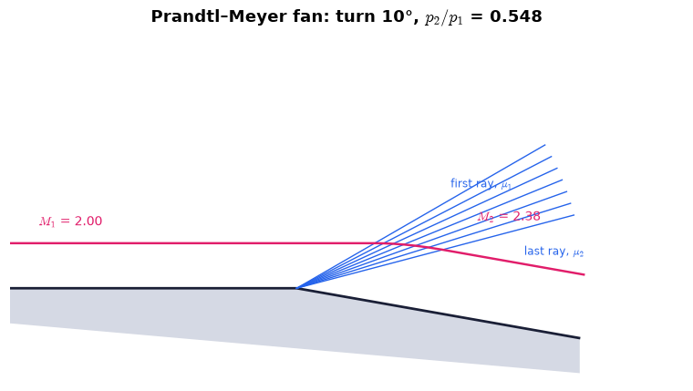

```
M: 2.000 -> 2.385; first ray at 30.0°, last at 24.8° to its wall; p2/p1 = 0.548
```

```python
fan = ch15.expansion_fan(2.0, np.deg2rad(10.0))               # Mach 2 turned 10° away (the book's delta = -10°)
fig = draw_fan(fan)                                           # rays and one streamline coloured by Mach number
plt.show()
print(f"M: {fan['M'][0]:.3f} -> {fan['M2']:.3f}; first ray at {np.degrees(fan['mu'][0]):.1f}°, last at {np.degrees(fan['mu'][-1]):.1f}° to its wall; p2/p1 = {fan['p2_over_p1']:.3f}")
```

**What you see.** A centred expansion fan at a 10° convex corner in a Mach 2 stream: seven rays from the corner and one streamline that bends smoothly through them.

**How to read it.** The first ray stands at μ₁ = 30° to the upstream wall, the last at μ₂ = 24.8° to the downstream wall; between them the Mach number climbs from 2 to 2.385 and the pressure drops to 55 % — smoothly along the streamline, but in one step along the wall at the corner.

**What would change if…** …the turn were 20°? The fan would open wider and the stream would leave at Mach 2.83 with 27 % of its pressure.

#### 🧮 Derivation — The Prandtl–Meyer differential relation `D29` ★★ (Eq. unnumbered, §15.9: $d\delta=-\dfrac{\sqrt{M^2-1}}{M}\dfrac{dM}{1+\frac12(\gamma-1)M^2}$)

**What we want to show.** Find how much the Mach number changes when a supersonic stream turns through one very weak wave.

**Assumptions.** An infinitely weak wave, hence isentropic and at the Mach angle (step 4); adiabatic, perfect gas (step 7).

**The plan.**

1. Make the turn infinitesimal.
2. Get the speed change per unit turn.
3. Convert the speed change into a Mach-number change using constant stagnation temperature.

**Tools we use** (each explained before this point): first-order expansion (P26 reminder) · the Mach triangle (primer P372) · logarithmic differentiation (P52 reminder) · D08

**We start from**

$$ v_1=v_2\qquad\text{(the velocity component along the wave is the same on both sides — D26 step 3)} $$

*In words:* Across a wave at angle σ the speed along the wave is unchanged (D26 step 3); step 1 writes this with the flow speeds and angles.

**Step 1 of 9 — Start from the unchanged tangential speed.**

$$ V_1\cos\sigma=V_2\cos(\sigma-\delta) $$

- *Why we can do this:* D26 step 3 with $v=V\cos(\text{angle to the wave})$.
- *In words:* The stream keeps its speed along the wave.

**Step 2 of 9 — Make the turn small.**

$$ \cos(\sigma-d\delta)\approx\cos\sigma+\sin\sigma\,d\delta $$

- *Why we can do this:* First-order Taylor expansion in the small angle dδ (≈); the derivative of cos is −sin.
- *In words:* A small turn changes the cosine in proportion.

**Step 3 of 9 — Keep first order.**

$$ 0=dV\cos\sigma+V\sin\sigma\,d\delta\ \Rightarrow\ d\delta=-\dfrac{dV}{V}\cot\sigma $$

- *Why we can do this:* Put $V_1=V$, $V_2=V+dV$; the product $dV\,d\delta$ is second order and dropped.
- *In words:* Turning into the wave (dδ > 0) slows the stream; turning away speeds it up.

**Step 4 of 9 — Put the wave at the Mach angle.**

$$ d\delta=-\dfrac{dV}{V}\sqrt{M^2-1} $$

- *Why we can do this:* An infinitely weak wave is a Mach wave: σ = μ, and cot μ = $\sqrt{M^2-1}$ (primer P372).
- *In words:* The speed change per unit turn is fixed by the Mach number.

**Step 5 of 9 — Split the speed change.**

$$ \dfrac{dV}{V}=\dfrac{dM}{M}+\dfrac{dc}{c} $$

- *Why we can do this:* Take the logarithm of $V=Mc$, $\ln V=\ln M+\ln c$ (allowed: all three are positive), and differentiate; this splits the speed change into a Mach-number part and a sound-speed part, each of which steps 6–7 supply.
- *In words:* Speed changes through the Mach number and through the sound speed.

**Step 6 of 9 — Sound speed from temperature.**

$$ \dfrac{dc}{c}=\dfrac12\dfrac{dT}{T} $$

- *Why we can do this:* $c=\sqrt{\gamma RT}$: the logarithm of a square root.
- *In words:* Sound speed changes half as fast as temperature.

**Step 7 of 9 — Temperature from constant $T_0$.**

$$ \dfrac{dT}{T}=-\dfrac{(\gamma-1)M\,dM}{1+\frac{\gamma-1}{2}M^2} $$

- *Why we can do this:* $T=T_0/\Theta$ with $T_0$ fixed (adiabatic): $dT/T=-d\Theta/\Theta$ and $d\Theta=(\gamma-1)M\,dM$.
- *In words:* As the Mach number rises the gas cools.

**Step 8 of 9 — Combine steps 5–7.**

$$ \dfrac{dV}{V}=\dfrac{dM}{M}\cdot\dfrac{1}{1+\frac{\gamma-1}{2}M^2} $$

- *Why we can do this:* $\dfrac{dM}{M}\left[1-\dfrac{\frac{\gamma-1}{2}M^2}{\Theta}\right]=\dfrac{dM}{M}\,\dfrac1\Theta$. Substituting steps 6 and 7 into step 5 and putting the bracket on one denominator is ordinary algebra.
- *In words:* The speed rises more slowly than the Mach number, because the sound speed falls.

**Step 9 of 9 — Insert into step 4.**

$$ d\delta=-\dfrac{\sqrt{M^2-1}}{M}\,\dfrac{dM}{1+\frac12(\gamma-1)M^2}\ \text{(unnumbered, §15.9)} $$

- *Why we can do this:* Substitution. We put step 8 into step 4; it ties the turn to the Mach-number change alone, ready to integrate (D30).
- *In words:* A small turn away from the flow (dδ < 0) raises the Mach number by a definite amount.

**Result**

$$ \begin{array}{l}d\delta=-\dfrac{\sqrt{M^2-1}}{M}\dfrac{dM}{1+\frac12(\gamma-1)M^2}\ \text{(unnumbered, §15.9) — so that}\ d\delta+d\nu=0\ \text{with}\ d\nu\ \text{the} \\ \text{integrand of}\ \nu(M)=\displaystyle\int_1^M\dfrac{\sqrt{M^2-1}}{1+\frac12(\gamma-1)M^2}\dfrac{dM}{M}\ \text{(15.56).}\end{array} $$

**What it means.** Each Mach wave of a fan does this small job; adding them up is the integral of D30. **Fails when:** the turn is a finite compression — the waves cross and a shock (not isentropic) forms.

**Check it.** Units — radians on both sides ✓. Sign — dδ < 0 (expansion) ⇒ dM > 0. Number — at M = 2: dM = −dδ × 2 × 1.8/1.732 = 2.078 per radian = 0.0363 per degree; ten steps of 1° from Mach 2 give ≈ 2.38 (exact 2.385). Code — `ch15.fan_staircase`.

📝 **Notes taught inside `D29`:** **N106 [B]** $d\delta=-\dfrac{\sqrt{M^2-1}}{M}\dfrac{dM}{1+\frac12(\gamma-1)M^2}$ (unnumbered, §15.9)

> ⚠️ **Common confusion (traps in `D29`):** The sign: δ > 0 is a turn *into* the flow (trap T14); $dc/c=\tfrac12dT/T$; dT comes from constant $T_0$, not constant T; exact for an expansion of any size, for a compression only until Mach lines cross.

```python
pm = ch15.prandtl_meyer_sympy()                               # sympy: the integrand, the closed form and their consistency
print(pm["integrand"], "| d(closed form)/dM - integrand:", pm["derivative_residual"], "| nu(1) =", pm["value_at_1"])
```

```
sqrt(M**2 - 1)/(M*(M**2*(gamma/2 - 1/2) + 1)) | d(closed form)/dM - integrand: 0 | nu(1) = 0
```

> 📎 **Primer — arctangent integrals.** `P373` · $\displaystyle\int\dfrac{dt}{1+a^2t^2}=\dfrac1a\tan^{-1}(at)$: the antiderivative of "one over one plus a square" is an arctangent, with the scaling a divided out. Reached here after a substitution (reminder P106) and a split into partial fractions (reminder P219).

```python
import sympy as sp
t, a = sp.symbols('t a', positive=True)
print(sp.integrate(1/(1 + a**2*t**2), t))            # atan(a*t)/a
print(sp.diff(sp.atan(a*t)/a, t))                    # 1/(a**2*t**2 + 1): differentiate back
```

```
atan(a*t)/a
1/(a**2*t**2 + 1)
```

#### 🧮 Derivation — The Prandtl–Meyer function in closed form `D30` ★★★ (Eq. 15.56: $\nu(M)=\sqrt{\dfrac{\gamma+1}{\gamma-1}}\tan^{-1}\sqrt{\dfrac{\gamma-1}{\gamma+1}\left(M^2-1\right)}-\tan^{-1}\sqrt{M^2-1}$)

**What we want to show.** Add up infinitely many small turns: integrate the differential relation from Mach 1 to M.

**Assumptions.** Constant γ > 1; M ≥ 1.

**The plan.**

1. Substitute $t=\sqrt{M^2-1}$.
2. The integrand becomes a ratio of polynomials in t.
3. Split it into two simple fractions.
4. Each integrates to an arctangent.
5. Put M back.

**Tools we use** (each explained before this point): substitution in an integral (P106 reminder) · partial fractions (P219 reminder) · arctangent integrals (primer P373)

**We start from**

$$ \nu(M)=\displaystyle\int_1^M\dfrac{\sqrt{M^2-1}}{1+\frac12(\gamma-1)M^2}\dfrac{dM}{M}\ \text{(15.56, integral form)} $$

*In words:* The total turning needed to bring a sonic stream to Mach number M; by D29, $\delta+\nu(M)=\text{const}$ along the wall

**Step 1 of 10 — Substitute.**

$$ t\equiv\sqrt{M^2-1}\quad(M^2=1+t^2) $$

- *Why we can do this:* The square root is what makes the integral awkward; naming it removes it. t runs from 0 (M = 1) upward.
- *In words:* t is the cotangent of the Mach angle.

**Step 2 of 10 — Convert the measure.**

$$ \dfrac{dM}{M}=\dfrac{t\,dt}{1+t^2} $$

- *Why we can do this:* Differentiate $M^2=1+t^2$: $2M\,dM=2t\,dt$; divide by $M^2=1+t^2$.
- *In words:* A small relative change of M, in terms of t.

**Step 3 of 10 — Convert the bracket.**

$$ 1+\tfrac{\gamma-1}{2}M^2=\tfrac{\gamma+1}{2}\left(1+\lambda^2t^2\right),\qquad\lambda^2\equiv\dfrac{\gamma-1}{\gamma+1} $$

- *Why we can do this:* Put $M^2=1+t^2$ into the bracket and collect: $1+\tfrac{\gamma-1}{2}(1+t^2)=\tfrac{\gamma+1}{2}+\tfrac{\gamma-1}{2}t^2$; factoring out $\tfrac{\gamma+1}{2}$ exposes the form $1+\lambda^2t^2$, whose integral is an arctangent.
- *In words:* The temperature bracket, in t (λ² = 1/6 for air).

**Step 4 of 10 — Assemble the integral in t.**

$$ \nu=\displaystyle\int_0^{t}\dfrac{2}{\gamma+1}\,\dfrac{t^2}{(1+t^2)(1+\lambda^2t^2)}\,dt $$

- *Why we can do this:* Numerator $\sqrt{M^2-1}=t$ times step 2; denominator from step 3; limits M = 1 → t = 0.
- *In words:* A ratio of polynomials — no roots left.

**Step 5 of 10 — Split into partial fractions.**

$$ \dfrac{t^2}{(1+t^2)(1+\lambda^2t^2)}=\dfrac{1}{1-\lambda^2}\left[\dfrac{1}{1+\lambda^2t^2}-\dfrac{1}{1+t^2}\right] $$

- *Why we can do this:* Put the bracket on a common denominator: its numerator is $(1+t^2)-(1+\lambda^2t^2)=(1-\lambda^2)t^2$.
- *In words:* One hard fraction is the difference of two easy ones.

**Step 6 of 10 — Simplify the prefactor.**

$$ \dfrac{2}{\gamma+1}\cdot\dfrac{1}{1-\lambda^2}=1\ \Rightarrow\ \nu=\displaystyle\int_0^t\left[\dfrac{1}{1+\lambda^2t^2}-\dfrac{1}{1+t^2}\right]dt $$

- *Why we can do this:* $1-\lambda^2=\dfrac{(\gamma+1)-(\gamma-1)}{\gamma+1}=\dfrac{2}{\gamma+1}$, so the two constants are reciprocals and their product is exactly 1; the integrand becomes a plain difference of two simple fractions.
- *In words:* The constants cancel exactly.

**Step 7 of 10 — Integrate the first fraction.**

$$ \displaystyle\int_0^t\dfrac{dt}{1+\lambda^2t^2}=\dfrac1\lambda\tan^{-1}(\lambda t) $$

- *Why we can do this:* The arctangent integral with scaling λ (primer P373); differentiate back to check.
- *In words:* An arctangent, stretched by 1/λ.

**Step 8 of 10 — Integrate the second.**

$$ \displaystyle\int_0^t\dfrac{dt}{1+t^2}=\tan^{-1}t $$

- *Why we can do this:* The arctangent integral of primer P373, $\int_0^t dt/(1+a^2t^2)=\tan^{-1}(at)/a$, with $a=1$.
- *In words:* A plain arctangent.

**Step 9 of 10 — Apply the lower limit.**

$$ \nu=\dfrac1\lambda\tan^{-1}(\lambda t)-\tan^{-1}t\quad(\text{both vanish at }t=0) $$

- *Why we can do this:* $\tan^{-1}0=0$: the lower limit contributes nothing, which is what makes ν(1) = 0.
- *In words:* ν in terms of t.

**Step 10 of 10 — Put M back.**

$$ \nu(M)=\sqrt{\dfrac{\gamma+1}{\gamma-1}}\tan^{-1}\sqrt{\dfrac{\gamma-1}{\gamma+1}\left(M^2-1\right)}-\tan^{-1}\sqrt{M^2-1}\ \text{(15.56)} $$

- *Why we can do this:* $1/\lambda=\sqrt{(\gamma+1)/(\gamma-1)}$ and $t=\sqrt{M^2-1}$. Undoing the substitution of step 1 is allowed because t and M are in one-to-one correspondence for M ≥ 1.
- *In words:* The Prandtl–Meyer function: the angle a sonic stream must turn to reach Mach M.

**Result**

$$ \nu(M)=\sqrt{\dfrac{\gamma+1}{\gamma-1}}\tan^{-1}\sqrt{\dfrac{\gamma-1}{\gamma+1}\left(M^2-1\right)}-\tan^{-1}\sqrt{M^2-1}\ \text{(15.56) (in radians).} $$

**What it means.** Every isentropic turn of a supersonic stream is a subtraction: ν after = ν before + the turn away from the flow. The finite limit as M → ∞ is the largest possible turn: all thermal energy has become speed (N38). **Fails when:** the turn is a compression strong enough for Mach lines to cross (a shock), or γ varies.

**Check it.** Units — radians ✓. Limits — ν(1) = 0; M → ∞: $\nu\to\left(\sqrt{(\gamma+1)/(\gamma-1)}-1\right)\dfrac\pi2$ = 130.45° for γ = 1.4. Number — M = 2: 2.449 × 35.26° − 60° = 26.38°. Derivative — dν/dM equals the integrand (sympy and `quad`).

```python
import sympy as sp                                   # symbolic algebra
g = sp.symbols("gamma", positive=True)               # ratio of specific heats (> 1)
M = sp.symbols("M", positive=True)                   # Mach number (> 1 inside the fan)
t = sp.symbols("t", positive=True)                   # step 1: t = sqrt(M^2 - 1)
lam2 = (g-1)/(g+1)                                   # step 3: lambda^2
integrand_M = sp.sqrt(M**2 - 1)/(1 + (g-1)/2*M**2)/M # the integrand of (15.56) in M
integrand_t = sp.simplify(integrand_M.subs(M, sp.sqrt(1 + t**2))*t/sp.sqrt(1 + t**2))   # steps 2-4: times dM/dt = t/M
assert sp.simplify(integrand_t - 2/(g+1)*t**2/((1 + t**2)*(1 + lam2*t**2))) == 0        # step 4
split = 1/(1 + lam2*t**2) - 1/(1 + t**2)             # steps 5-6: partial fractions, prefactor exactly 1
assert sp.simplify(integrand_t - split) == 0       # the two simple fractions add back to the integrand
lam = sp.sqrt(lam2)                                  # lambda itself
nu_t = sp.atan(lam*t)/lam - sp.atan(t)               # steps 7-8: the two arctangent integrals
assert sp.simplify(sp.diff(nu_t, t) - split) == 0    # differentiate back: we recover the integrand
assert nu_t.subs(t, 0) == 0                          # step 9: the lower limit M = 1 (t = 0) contributes nothing
nu = sp.sqrt((g+1)/(g-1))*sp.atan(sp.sqrt((g-1)/(g+1)*(M**2 - 1))) - sp.atan(sp.sqrt(M**2 - 1))   # Eq. (15.56)
resid = sp.diff(nu, M) - integrand_M                 # step 10: d(nu)/dM must equal the integrand
vals = [abs(sp.N(resid.subs({g: gv, M: Mv}))) for gv in (1.4, sp.Rational(5, 3)) for Mv in (1.2, 2, 5)]   # the residual at six (gamma, M) pairs
assert max(vals) < 1e-12                             # numerically zero at six (gamma, M) pairs
print(sp.N(nu.subs({g: 1.4, M: 2})*180/sp.pi, 8), "|", sp.N((sp.sqrt(6) - 1)*90, 8))   # nu(2) and the M -> infinity limit, degrees
```

```
26.379761
```

```
 | 130.45408
```

(ν is the Prandtl–Meyer function here; a kinematic viscosity in §15.6 — trap T5.)

> ⚠️ **Common confusion (traps in `D30`):** ν is in radians; the two arctangents have different scalings; forgetting that the prefactor cancels to 1 (step 6); ν is the Prandtl–Meyer function here, not a viscosity (trap T5).

📝 **Note.** **N107 [B]** **How it is used:** $\delta_1+\nu(M_1)=\delta_2+\nu(M_2)$ (unnumbered, §15.9), so $\nu(M_2)=\delta_1-\delta_2+\nu(M_1)$.

> ⚠️ **Common confusion** (trap T14): the book counts δ positive when the wall turns **into** the flow; our `turn=` (and most tables) count the **expansion** positive: turn = −δ. Both numbers are in every legend.

#### ✏️ Tiny example: Mach 2 turned 10° away

γ = 1.4; $\sqrt{(\gamma+1)/(\gamma-1)}$ = √6 = 2.449.

1. $\nu(M)=\sqrt{\dfrac{\gamma+1}{\gamma-1}}\tan^{-1}\sqrt{\dfrac{\gamma-1}{\gamma+1}\left(M^2-1\right)}-\tan^{-1}\sqrt{M^2-1}$ (15.56) at M = 2: $\sqrt{M^2-1}$ = 1.732; first term 2.449 × atan(1.732/2.449) = 2.449 × atan(0.7071) = 2.449 × 35.26° = 86.38°; second atan(1.732) = 60°; **ν(2) = 26.38°**.
2. Turn +10° (the book's δ = −10°): ν₂ = 36.38°.
3. Invert (root-finder): **M₂ = 2.385**.
4. Isentropic, so $p_0$ is unchanged: $p_2/p_1$ = [(1 + 0.2 × 4)/(1 + 0.2 × 2.385²)]^3.5 = (1.8/2.1375)^3.5 = **0.548**.
5. Fan: first ray at $\mu_1$ = 30° to the old wall, last at $\mu_2$ = 24.8° to the new wall.

```python
print(np.degrees(GD.prandtl_meyer(np.array([1.0, 1.5, 2.0, 3.0]))))   # (15.56): 0, 11.905, 26.380, 49.757 degrees
print(np.degrees(GD.prandtl_meyer_max()))                     # the largest possible turn from Mach 1: 130.45°
t = GD.prandtl_meyer_turn(2.0, np.deg2rad(10.0))              # turn = +10° (expansion) = the book's delta = -10°
print({k: round(float(v), 4) for k, v in t.items() if k in ("M2", "p_ratio", "T_ratio")}, "mu2 =", round(np.degrees(t["mu2"]), 2),
      "°, book's delta =", round(np.degrees(t["delta_book"]), 1), "°")
print(GD.mach_from_prandtl_meyer(np.deg2rad(36.38)))          # inverse: 2.385
```

```
[ 0.     11.9052 26.3798 49.7573]
130.45407685048605
{'M2': 2.3849, 'p_ratio': 0.548, 'T_ratio': 0.8421} mu2 = 24.79 °, book's delta = -10.0 °
2.3848969837710694
```

**What does the code above do?**

1. `GD.prandtl_meyer` is $\nu(M)=\sqrt{\dfrac{\gamma+1}{\gamma-1}}\tan^{-1}\sqrt{\dfrac{\gamma-1}{\gamma+1}\left(M^2-1\right)}-\tan^{-1}\sqrt{M^2-1}$ (15.56) in radians: 26.38° at Mach 2.
2. `GD.prandtl_meyer_max()` is the limit as M → ∞: (√6 − 1) × 90° = 130.45° — a stream starting at Mach 1 can turn at most that far, when all its heat has become speed (N38).
3. `GD.prandtl_meyer_turn(2.0, 10°)` gives $M_2$ = 2.3849, $p_2/p_1$ = 0.5480, $T_2/T_1$ = 0.8421, $\mu_2$ = 24.79°, and reports the book's δ = −10° beside our turn = +10°.

```python
nu_quad = quad(lambda M: np.sqrt(M * M - 1) / (1 + 0.2 * M * M) / M, 1.0, 2.0)[0]   # (15.56, integral form) by quad
assert np.allclose(nu_quad, GD.prandtl_meyer(2.0))            # = the closed form
M, n = 2.0, 100                                               # march 100 small turns of 0.1°
dturn = np.deg2rad(10.0) / n                                  # each turn [rad] (expansion: d(delta) = -dturn)
for _ in range(n):                                            # (unnumbered, §15.9): dM = -d(delta) M (1 + 0.2 M²)/sqrt(M² - 1)
    M += dturn * M * (1 + 0.2 * M * M) / np.sqrt(M * M - 1)
assert np.allclose(M, t["M2"], rtol=2e-3)                     # the staircase lands on the exact answer
print(np.degrees(nu_quad), M, [round(ch15.fan_staircase(2.0, np.deg2rad(10.0), N)["M"][-1], 4) for N in (1, 3, 7, 21, 100)])
```

```
26.379760813416326 2.3846313243561954 [np.float64(2.3628), np.float64(2.3768), np.float64(2.3813), np.float64(2.3837), np.float64(2.3846)]
```

**From scratch.** Two routes: `quad` integrates $\nu(M)=\displaystyle\int_1^M\dfrac{\sqrt{M^2-1}}{1+\frac12(\gamma-1)M^2}\dfrac{dM}{M}$ (15.56, integral form) directly (26.380°), and a loop takes 100 small Mach-wave steps of $d\delta=-\dfrac{\sqrt{M^2-1}}{M}\dfrac{dM}{1+\frac12(\gamma-1)M^2}$ (unnumbered, §15.9) — the integral as a limit of sums. `ch15.fan_staircase` does the same with N waves: 2.363, 2.377, 2.381, 2.384, 2.3846 for N = 1, 3, 7, 21, 100, closing on the exact 2.3849.

📝 **Note.** **N104 [B]** Mach lines from a curved wall. Along each Mach line the flow direction and Mach number are constant (a simple wave — the steady twin of N22's steepening).

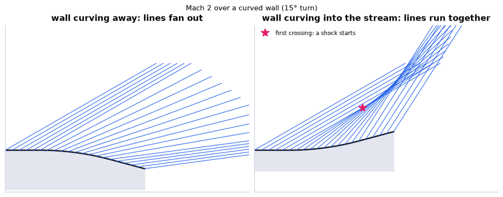

```python
x = np.linspace(-0.5, 1.5, 41)                                # wall stations [m]
ramp = lambda s: np.deg2rad(15.0) * np.clip(s, 0.0, 1.0)      # wall angle grows from 0 to 15° between x = 0 and 1
fig, axes = plt.subplots(1, 2, figsize=(9.6, 3.8))            # away from the stream / into it
for ax, sign, name in ((axes[0], -1, "wall curving away: lines fan out"), (axes[1], +1, "wall curving into the stream: lines run together")):
    cw = ch15.curved_wall_mach_lines(2.0, lambda s: sign * ramp(s), x)   # theta > 0 into the flow (the book's sign)
    ax.fill_between(cw["x_wall"], cw["y_wall"], cw["y_wall"].min() - 0.3, color=COLORS["grid"])   # the wall
    ax.plot(cw["x_wall"], cw["y_wall"], color=COLORS["ink"])
    for xw, yw, ang in zip(cw["x_wall"][::2], cw["y_wall"][::2], cw["line_angle"][::2]):   # every second Mach line
        ax.plot([xw, xw + 2.5 * np.cos(ang)], [yw, yw + 2.5 * np.sin(ang)], color=COLORS["blue"], lw=0.8)
    if cw["first_crossing"] is not None:                      # compression: where the first two lines meet
        ax.plot(*cw["first_crossing"], "*", color=COLORS["rose"], ms=12, label="first crossing: a shock starts")
        ax.legend(fontsize=8, loc="upper left")
    ax.set(xlim=(-0.5, 3.0), ylim=(-0.6, 1.8), aspect="equal", title=name); ax.set_xticks([]); ax.set_yticks([])
fig.suptitle("Mach 2 over a curved wall (15° turn)", fontsize=10); plt.show()
```

**What you see.** Mach lines leaving a wall that curves through 15°: away from a Mach 2 stream (left) and into it (right).

**How to read it.** Turning away, each Mach line leans further downstream than the one before (higher Mach number, smaller μ, and a wall pointing down): they spread — an expansion fan spread along the wall. Turning into the stream they lean the other way and cross; at the star the flow would have two Mach numbers at once, so a shock must begin there.

**What would change if…** …the bend were sharpened into a corner? On the left all lines would start at one point: the centred fan of N105. On the right the crossing would move onto the wall: an oblique shock from the corner (C14).

📝 **Note.** **N103 [B]** Weak expansions obey the weak-wave rule too. They share value and slope at δ = 0 because the entropy change is third order: $\dfrac{S_2-S_1}{C_v}\cong\dfrac{\gamma^2-1}{12\gamma^2}\left(\dfrac{p_2-p_1}{p_1}\right)^3$ (15.44b) — so the rule holds for weak expansions too, with the sign of δ reversed.

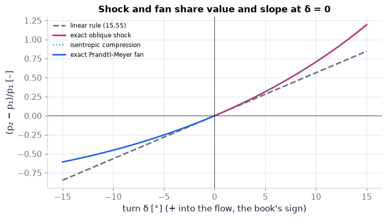

```
[0.7066, 0.7052, 0.5643, -0.452]
```

```python
deg = np.linspace(-15.0, 15.0, 121)                           # turns from -15° (expansion) to +15° (compression), the book's sign
d = np.deg2rad(deg)   # the same turns in radians
shock = [GD.oblique_shock(2.0, delta=v)["p_ratio"] - 1 if v > 0 else np.nan for v in d]          # exact weak shock (delta > 0)
fan_ = [GD.prandtl_meyer_turn(2.0, -v)["p_ratio"] - 1 if v <= 0 else np.nan for v in d]          # exact fan (delta < 0)
isen = [GD.prandtl_meyer_turn(2.0, -v)["p_ratio"] - 1 if v > 0 else np.nan for v in d]           # isentropic compression (for comparison)
fig, ax = plt.subplots(figsize=(6.8, 3.8))   # one panel
ax.plot(deg, GD.weak_wave_pressure(2.0, d), color=COLORS["muted"], ls="--", label="linear rule (15.55)")   # the straight line
ax.plot(deg, shock, color=COLORS["rose"], lw=2, label="exact oblique shock")   # compression by a shock
ax.plot(deg, isen, color=COLORS["teal"], ls=":", lw=1.5, label="isentropic compression")   # compression without a shock
ax.plot(deg, fan_, color=COLORS["blue"], lw=2, label="exact Prandtl–Meyer fan")   # expansion
ax.axhline(0, color=COLORS["ink"], lw=0.6); ax.axvline(0, color=COLORS["ink"], lw=0.6)   # axes through the origin
ax.set(xlabel="turn δ [°] (+ into the flow, the book's sign)", ylabel="(p₂ − p₁)/p₁ [–]",   # labels with units and sign
       title="Shock and fan share value and slope at δ = 0")   # the message
ax.legend(fontsize=8); savefig(fig, "ch15", "c15_weak_wave"); plt.show()   # legend, save, display
print([round(float(v), 4) for v in (GD.oblique_shock(2.0, delta=np.deg2rad(10))["p_ratio"] - 1,   # the four quoted numbers:
       GD.prandtl_meyer_turn(2.0, np.deg2rad(-10))["p_ratio"] - 1, GD.weak_wave_pressure(2.0, np.deg2rad(10)),   # shock, isentropic, line …
       GD.prandtl_meyer_turn(2.0, np.deg2rad(10))["p_ratio"] - 1)])   # +10°: shock 0.7066, isentropic 0.7052, line 0.5643; -10°: fan -0.4520
```

**What you see.** The relative pressure change against the turn at Mach 2: the exact shock (rose, δ > 0), the exact fan (blue, δ < 0), an isentropic compression for comparison (teal dotted) and the straight line $\dfrac{p_2-p_1}{p_1}=\dfrac{\gamma M_1^2}{\sqrt{M_1^2-1}}\,\delta$ (15.55) (grey dashed).

**How to read it.** All curves leave the origin together: same value, same slope. At +10° the shock (0.707) and the isentropic compression (0.705) are almost the same — the entropy difference is third order — and both are above the line (0.564). At −10° the fan (−0.452) lies above the line (−0.564): the rule underestimates compressions and overestimates expansions.

**What would change if…** …$M_1$ were 1.2? The line's slope $\gamma M^2/\sqrt{M^2-1}$ would be 3.0 instead of 3.2, but the curves would bend away much sooner — and the shock detaches above 3.9°.

```python
M = np.geomspace(1.0, 10.0, 300)                              # Mach numbers (log-spaced)
fig = slider_figure(lambda g: {"ν(M), (15.56)": (M, np.degrees(GD.prandtl_meyer(M, g))),   # nu(M) in degrees
                               "limit as M → ∞": (M, np.degrees(GD.prandtl_meyer_max(g)) * np.ones_like(M))},   # its limit, as a flat line
                    "γ", [1.2, 1.3, 1.4, 5 / 3], xlabel="Mach number M [–] (log axis)", ylabel="ν [°]",   # four gases
                    title="The Prandtl–Meyer function and the largest possible turn")   # the message
fig.update_xaxes(type="log", range=[0, 1])                    # log axis from 1 to 10
fig.show()   # display
```

[interactive chart not shown]

**Figure F9b.** Slider: γ = 1.2, 1.3, 1.4 or 5/3, in $\nu(M)=\sqrt{\dfrac{\gamma+1}{\gamma-1}}\tan^{-1}\sqrt{\dfrac{\gamma-1}{\gamma+1}\left(M^2-1\right)}-\tan^{-1}\sqrt{M^2-1}$ (15.56).

**What you see.** ν(M) in degrees against the Mach number on a logarithmic axis, with its limit as M → ∞ dashed.

**How to read it.** Read a turn as a horizontal distance between two ν values: from Mach 2 (26.4°) a 10° turn reaches 36.4°, i.e. Mach 2.385. The limit is 130.5° for air but 90° for a monatomic gas.

**What would change if…** …γ → 1? The limit $(\sqrt{(\gamma+1)/(\gamma-1)}-1)\cdot90°$ runs away: a gas with many internal degrees of freedom can turn very far.

#### 🎮 Interactive: How does a supersonic stream turn a corner?

**Why interactive rather than a static figure:** you build the turn from 1, 3, 7, 21, then infinitely many Mach waves and watch the staircase of Mach number settle onto ν(M): the integral as a limit of sums, made with your own hands.

Start with the **Walkthrough**; the **Explain** tab works every number out with your settings, and the **Derivation** tab (where there is one) steps through the same derivation as above. ν, μ and the turn are computed in radians and shown in degrees; the code counts an expansion turn positive (the book's δ is its negative).

**What to try:**

- Set N = 1, 3, 7, 21, ∞ and compare $M_2$.
- Reverse the turn: where do the Mach lines cross?
- Start at $M_1$ = 1: how far can the stream turn?

```python
show_viz("ch15", "prandtl_meyer_fan")   # full-width explainer; ⤢ Full screen for more room
```

🎮 Interactive 8/9 How does a supersonic stream turn a corner? Open alone ↗

[interactive chart not shown]

**What would change if…** …a thin plate were tilted in the stream — a fan on one side, a weak shock on the other? Two pressures, and their difference is lift. C16.

## 15.10 Thin Airfoil Theory in Supersonic Flow

**What is this section about?** Lift and drag of a thin plate in a supersonic stream from the weak-wave rule alone: two pressure levels, a lift — and a drag that needs no viscosity.

### 🧩 Lift and wave drag of a flat plate: $C_L\cong\dfrac{4\alpha}{\sqrt{M_\infty^2-1}},\ \ C_D\cong\dfrac{4\alpha^2}{\sqrt{M_\infty^2-1}}$ (15.59) `C16`

*The question:* How does a thin wing make lift above Mach 1 — and why does that lift always cost drag, even without friction?

> 🔁 **Recap — d'Alembert's paradox and the Kutta condition** (Ch. 6 C07; Ch. 14 C02). **d'Alembert's paradox:** in steady, inviscid, subsonic flow a body feels no drag at all. **The Kutta condition:** potential theory allows a wing any circulation; the real one is the circulation that makes the flow leave the sharp trailing edge smoothly, and it gives the lift $C_L\simeq2\pi(\alpha+\beta)$ (14.12) (slope 2π per radian). Neither carries over above Mach 1 — the plate below has drag without friction, and needs no Kutta condition.

#### The problem in plain words

Chapter 14's wing made lift by circulation, needed a sharp trailing edge to choose it, and in two dimensions had no drag at all. A supersonic wing is simpler and harsher. Each surface feels only its own slope: the top, turned away from the stream, sits at one lower pressure; the bottom, turned into it, at one higher pressure. The difference pushes at right angles to the plate. Tilt the plate by α and that push leans back by α: every newton of lift costs α newtons of drag — carried away by the waves, not by friction.

#### The idea

```
          p₂ < p∞   (fan above the leading edge)
    ════════════════  plate at α  ════════════════
          p₃ > p∞   (shock below)
force = (p₃ − p₂) b, normal to the plate  →  L = force × cos α,  D = force × sin α
```

📝 **Note.** **N108 [B]** $\dfrac{p-p_\infty}{p_\infty}=\dfrac{\gamma M_\infty^2\,\delta}{\sqrt{M_\infty^2-1}}$ (15.57) is $\dfrac{p_2-p_1}{p_1}=\dfrac{\gamma M_1^2}{\sqrt{M_1^2-1}}\,\delta$ (15.55) written with free-stream values (Ackeret's linear theory). As a pressure coefficient (ours): $C_p=2\delta/\sqrt{M_\infty^2-1}$.

> 🔁 **Recap — Pressure coefficient** (Ch. 4 C15; P359 in C04). $C_p=(p-p_\infty)/(\tfrac12\rho_\infty U_\infty^2)$, and in a gas $\tfrac12\rho U^2=\tfrac12\gamma pM^2$ (primer P359), so $C_p=\dfrac{2}{\gamma M_\infty^2}\dfrac{p-p_\infty}{p_\infty}$.

```python
print(ch15.ackeret_pressure(plate["alpha"], plate["M_inf"]))  # (15.57) for a 2° slope at Mach 2: (p - p_inf)/p_inf = 0.1129 (the angle comes first)
print(ch15.ackeret_cp(plate["alpha"], plate["M_inf"]))        # as a pressure coefficient: 2 delta/sqrt(M² - 1) = 0.0403
```

```
0.1128586271079069
0.04030665253853818
```

#### 🧮 Derivation — The flat plate in supersonic flow `D31` ★ (Eq. 15.59: $C_L\cong\dfrac{4\alpha}{\sqrt{M_\infty^2-1}},\ \ C_D\cong\dfrac{4\alpha^2}{\sqrt{M_\infty^2-1}}$)

**What we want to show.** Find the lift and drag of a thin flat plate at a small angle of attack in a supersonic stream.

**Assumptions.** α ≪ 1 rad; $M_\infty$ not near 1; inviscid; two-dimensional.

**The plan.**

1. Write the rule with free-stream values.
2. Apply it to each surface.
3. The pressure difference is a force normal to the plate.
4. Resolve it.
5. Make coefficients.

**Tools we use** (each explained before this point): D28 · resolving a force (Ch. 14 recap) · small-angle approximation (P100 reminder) · dynamic pressure in a gas (primer P359)

**We start from**

$$ \dfrac{p_2-p_1}{p_1}=\dfrac{\gamma M_1^2}{\sqrt{M_1^2-1}}\,\delta\ \text{(15.55), the weak-wave rule.} $$

**Step 1 of 7 — Write the rule with free-stream values.**

$$ \dfrac{p-p_\infty}{p_\infty}=\dfrac{\gamma M_\infty^2\,\delta}{\sqrt{M_\infty^2-1}}\ \text{(15.57)} $$

- *Why we can do this:* $\dfrac{p_2-p_1}{p_1}=\dfrac{\gamma M_1^2}{\sqrt{M_1^2-1}}\,\delta$ (15.55) with station 1 = the free stream; δ is the surface's local inclination, positive when it turns into the flow. (The book's "found from (15.47)" — a slip: (15.47) is the friction differential $-\dfrac{dp}{p_1}=\dfrac{1+(\gamma-1)M^2}{1-M^2}\,df$, nothing to do with a plate — means this equation.)
- *In words:* Each piece of surface feels a pressure set by its own slope alone.

**Step 2 of 7 — Upper surface.**

$$ \dfrac{p_2-p_\infty}{p_\infty}=-\dfrac{\gamma M_\infty^2\alpha}{\sqrt{M_\infty^2-1}} $$

- *Why we can do this:* With the nose up, the upper surface falls *away* from the stream: δ = −α (an expansion fan at the leading edge).
- *In words:* Suction on top, uniform along the chord.

**Step 3 of 7 — Lower surface, and the difference.**

$$ \dfrac{p_3-p_\infty}{p_\infty}=+\dfrac{\gamma M_\infty^2\alpha}{\sqrt{M_\infty^2-1}},\qquad\dfrac{p_3-p_2}{p_\infty}=\dfrac{2\alpha\gamma M_\infty^2}{\sqrt{M_\infty^2-1}} $$

- *Why we can do this:* The lower surface turns *into* the stream: δ = +α (a weak shock); subtract step 2.
- *In words:* Overpressure below; the two surfaces differ by twice the single-surface change.

**Step 4 of 7 — Resolve the pressure force.**

$$ L=(p_3-p_2)\,b\cos\alpha,\qquad D=(p_3-p_2)\,b\sin\alpha $$

- *Why we can do this:* Pressure acts normal to the plate, whose chord is b; the plate is tilted by α from the stream, so its normal is tilted by α from the lift direction.
- *In words:* The push is square to the plate; most of it is lift, a fraction sin α is drag.

**Step 5 of 7 — Small angle.**

$$ L\cong\dfrac{2\alpha\gamma M_\infty^2p_\infty b}{\sqrt{M_\infty^2-1}},\qquad D\cong\dfrac{2\alpha^2\gamma M_\infty^2p_\infty b}{\sqrt{M_\infty^2-1}}\ \text{(15.58)} $$

- *Why we can do this:* cos α ≈ 1 and sin α ≈ α (≈), with step 3.
- *In words:* Lift grows like α, drag like α².

**Step 6 of 7 — Write the dynamic pressure with the Mach number.**

$$ \tfrac12\rho_\infty U_\infty^2=\tfrac12\gamma p_\infty M_\infty^2 $$

- *Why we can do this:* $\rho U^2=\gamma pM^2$ (primer P359). It makes $p_\infty$ and $M_\infty^2$ cancel.
- *In words:* The reference pressure of the coefficients.

**Step 7 of 7 — Divide.**

$$ C_L=\dfrac{L}{(1/2)\rho_\infty U_\infty^2b}\cong\dfrac{4\alpha}{\sqrt{M_\infty^2-1}},\qquad C_D=\dfrac{D}{(1/2)\rho_\infty U_\infty^2b}\cong\dfrac{4\alpha^2}{\sqrt{M_\infty^2-1}}\ \text{(15.59)} $$

- *Why we can do this:* Step 5 over step 6 times b.
- *In words:* Lift slope 4/√(M² − 1); and $C_D=\alpha\,C_L$.

**Result**

$$ \begin{array}{l}\dfrac{p-p_\infty}{p_\infty}=\dfrac{\gamma M_\infty^2\,\delta}{\sqrt{M_\infty^2-1}}\ \text{(15.57);} \\ \dfrac{p_2-p_\infty}{p_\infty}=-\dfrac{\gamma M_\infty^2\alpha}{\sqrt{M_\infty^2-1}},\ \ \dfrac{p_3-p_\infty}{p_\infty}=+\dfrac{\gamma M_\infty^2\alpha}{\sqrt{M_\infty^2-1}}\ \text{(unnumbered,} \\ \text{§15.10);}\ L\cong\dfrac{2\alpha\gamma M_\infty^2p_\infty b}{\sqrt{M_\infty^2-1}},\ \ D\cong\dfrac{2\alpha^2\gamma M_\infty^2p_\infty b}{\sqrt{M_\infty^2-1}}\ \text{(15.58);} \\ C_L\cong\dfrac{4\alpha}{\sqrt{M_\infty^2-1}},\ \ C_D\cong\dfrac{4\alpha^2}{\sqrt{M_\infty^2-1}}\ \text{(15.59).}\end{array} $$

**What it means.** Lift without a Kutta condition and drag without viscosity: the waves carry momentum and energy away (wave drag). The slope 4/√(M² − 1) replaces Chapter 14's 2π. **Fails when:** $M_\infty\to1$ (the coefficient diverges; the lower shock detaches), α is large, or the section is thick (then thickness adds drag — N112).

**Check it.** Units — lift and drag per unit span: Pa × m = N/m ✓; coefficients are numbers ✓. Limit — α = 0: no force. Number — α = 2° = 0.0349, $M_\infty$ = 2: $C_L$ = 0.0806, $C_D$ = 0.00281, L/D = 28.6. Exact (shock below, fan above): 0.08064 and 0.002816. At 10°: linear 0.403 against exact 0.4075 — 1.1 % low, although each surface pressure is 20–25 % off.

📝 **Notes taught inside `D31`:** **N109 [B]** the two surface pressures from $\dfrac{p-p_\infty}{p_\infty}=\dfrac{\gamma M_\infty^2\,\delta}{\sqrt{M_\infty^2-1}}$ (15.57) (steps 1–3) · **N110 [B]** $L\cong\dfrac{2\alpha\gamma M_\infty^2p_\infty b}{\sqrt{M_\infty^2-1}},\ \ D\cong\dfrac{2\alpha^2\gamma M_\infty^2p_\infty b}{\sqrt{M_\infty^2-1}}$ (15.58), the normal force resolved into lift and drag (steps 4–5; ⚠️ trap T15: b is the **chord** here)

> ⚠️ **Common confusion (traps in `D31`):** Which surface turns into the flow (trap T15); the force is normal to the plate, so $D=L\tan\alpha$; b is the chord; the book's "found from (15.47)" — a slip: (15.47) is the friction differential $-\dfrac{dp}{p_1}=\dfrac{1+(\gamma-1)M^2}{1-M^2}\,df$, nothing to do with a plate — where $\dfrac{p-p_\infty}{p_\infty}=\dfrac{\gamma M_\infty^2\,\delta}{\sqrt{M_\infty^2-1}}$ (15.57) is meant (slip #13); how small is small (trap T16).

> ⚠️ **slip #13 — the book prints** that the plate pressures are "found from (15.47)" — the friction differentials $-\dfrac{dp}{p_1}=\dfrac{1+(\gamma-1)M^2}{1-M^2}\,df,\ \ \dfrac{du}{u}=-\dfrac{d\rho}{\rho}=\dfrac{p_1}{p}\dfrac{df}{1-M^2}$ (15.47, numerator sign corrected), which have nothing to do with a plate; **the correct form is** from $\dfrac{p-p_\infty}{p_\infty}=\dfrac{\gamma M_\infty^2\,\delta}{\sqrt{M_\infty^2-1}}$ (15.57)

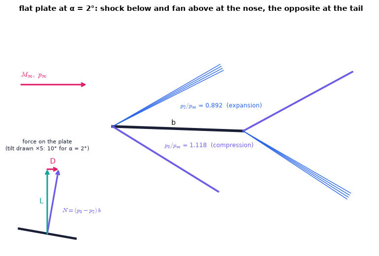

```
{'p2': 0.892, 'p3': 1.118, 'M2': 2.0733, 'M3': 1.9281}
```

```python
pat = ch15.flat_plate_wave_pattern(plate["alpha"], plate["M_inf"])   # the four waves and the states between them
fig = draw_plate_waves(pat)                                   # the plate, its four waves, the two pressure levels; inset: force N -> lift L + drag D
plt.show()
print({k: round(float(pat[k]), 4) for k in ("p2", "p3", "M2", "M3")})   # upper 0.892, lower 1.118 (over p_inf); M 2.073 above, 1.928 below
```

**What you see.** A flat plate (black, chord b) at 2° in a Mach 2 stream: an expansion fan (thin blue rays) above and a shock (thick purple line) below at the leading edge, a shock above and a fan below at the trailing edge, and the two pressure levels (blue label above the plate, purple below). **Inset, lower left:** the force on the plate — the normal force $N=(p_3-p_2)\,b$ (purple arrow, at right angles to the plate) split into lift L (teal, vertical) and wave drag D (rose, horizontal, downstream). In the inset the tilt is drawn **five times too large** (10° for α = 2°); at the true 2° the drag arrow would be only 3.5 % of the lift arrow and invisible.

**How to read it.** The upper surface sits at 0.892 $p_\infty$ and the lower at 1.118 $p_\infty$, each uniform along the chord. The force is normal to the plate, so it leans back by the tilt: in the inset the purple arrow, the teal leg and the rose leg form a right triangle. The angle α sits at the bottom, between the teal (L) and purple (N) arrows where both start on the plate; the right angle is at the tip of the teal arrow, where the rose leg begins. So D = N sin α ≈ αL. The trailing-edge waves bring both streams back to $p_\infty$.

**What would change if…** …α were 0? No waves of either kind (a plate of zero thickness at zero incidence does not disturb the stream): no lift, no drag.

#### ✏️ Tiny example: 2° at Mach 2

α = 2° = 0.0349 rad, $M_\infty$ = 2, $\sqrt{M_\infty^2-1}$ = 1.732.

1. $\dfrac{p-p_\infty}{p_\infty}=\dfrac{\gamma M_\infty^2\,\delta}{\sqrt{M_\infty^2-1}}$ (15.57): each surface differs from $p_\infty$ by 1.4 × 4 × 0.0349/1.732 = **11.3 %** (up below, down above).
2. $C_L\cong\dfrac{4\alpha}{\sqrt{M_\infty^2-1}},\ \ C_D\cong\dfrac{4\alpha^2}{\sqrt{M_\infty^2-1}}$ (15.59): $C_L$ = 4 × 0.0349/1.732 = **0.0806**.
3. $C_D$ = 4 × 0.0349²/1.732 = **0.00281**.
4. $C_D/C_L$ = α = 0.0349: L/D = 28.6.
5. Slope: 4/1.732 = 2.31 per radian — against Ch. 14's 2π = 6.28 for the same plate in slow flow.

```python
for deg in (2.0, 10.0):                                       # our plate, then a large incidence
    a_ = np.deg2rad(deg)
    lin = ch15.flat_plate_supersonic(a_, plate["M_inf"], method="linear")            # (15.57)-(15.59)
    ex = ch15.flat_plate_supersonic(a_, plate["M_inf"], method="shock_expansion")    # exact: oblique shock below, fan above
    print(f"{deg:4.1f}°: linear CL {lin['CL']:.5f} CD {lin['CD']:.6f} p_up {lin['p_upper']:.4f} p_low {lin['p_lower']:.4f} | "
          f"exact CL {ex['CL']:.5f} CD {ex['CD']:.6f} p_up {ex['p_upper']:.4f} p_low {ex['p_lower']:.4f}")
print(ch15.ackeret_flat_plate(plate["alpha"], plate["M_inf"]))   # CL, CD, L/D and the lift slope 4/sqrt(M² - 1) = 2.309
L_per_span = 0.5 * 1.4 * plate["p_inf"] * plate["M_inf"]**2 * plate["b"] * ch15.ackeret_flat_plate(plate["alpha"], plate["M_inf"])["CL"]
print(f"lift per metre of span for a 1 m chord at sea-level pressure: {L_per_span/1e3:.1f} kN/m")   # (15.58)
```

```
 2.0°: linear CL 0.08061 CD 0.002814 p_up 0.8871 p_low 1.1129 | exact CL 0.08065 CD 0.002816 p_up 0.8920 p_low 1.1180
10.0°: linear CL 0.40307 CD 0.070348 p_up 0.4357 p_low 1.5643 | exact CL 0.40750 CD 0.071854 p_up 0.5480 p_low 1.7066
{'CL': 0.08061330507707636, 'CD': 0.002813935189019287, 'L_over_D': 28.64788975654116, 'lift_slope': 2.3094010767585034}
lift per metre of span for a 1 m chord at sea-level pressure: 22.9 kN/m
```

**What does the code above do?**

1. At 2° the linear theory gives $C_L$ = 0.08061 and $C_D$ = 0.002814; the exact shock–expansion answer is 0.08064 and 0.002816 — the same to 0.05 %.
2. At 10° each surface's pressure *change* is 20–25 % off (linear ±0.564 against the exact +0.707 below and −0.452 above), yet the lift is only 1.1 % off. **The relative error of a single surface is first order in α** (it grows in proportion to α: the shock below is under-predicted, the fan above over-predicted), but those leading errors cancel in the difference $p_3-p_2$, so **the relative error of $C_L$ and $C_D$ is second order in α** — which is why 2° agrees to 0.05 % and 10° still to about 1 %.
3. `ch15.ackeret_flat_plate` returns the lift slope 2.309 per radian.
4. $L\cong\dfrac{2\alpha\gamma M_\infty^2p_\infty b}{\sqrt{M_\infty^2-1}},\ \ D\cong\dfrac{2\alpha^2\gamma M_\infty^2p_\infty b}{\sqrt{M_\infty^2-1}}$ (15.58) with our chord and pressure: about 23 kN of lift per metre of span.

```python
g, M, alpha = 1.4, plate["M_inf"], plate["alpha"]             # gas, Mach number, incidence [rad]
dp = g * M**2 * alpha / np.sqrt(M**2 - 1)                     # (15.57): each surface's relative pressure change
p3, p2 = 1 + dp, 1 - dp                                       # lower and upper pressures over p_inf
qinf = 0.5 * g * M**2                                         # dynamic pressure over p_inf (primer P359)
CN_mine = (p3 - p2) / qinf                                    # normal-force coefficient
CL_mine, CD_mine = CN_mine, CN_mine * alpha                   # cos(alpha) ≈ 1, sin(alpha) ≈ alpha: D31 step 5
lin = ch15.flat_plate_supersonic(alpha, M, method="linear")
assert np.allclose([CL_mine, CD_mine], [lin["CL"], lin["CD"]])   # = the linear method
ack = ch15.ackeret_flat_plate(alpha, M)
assert np.allclose([CL_mine, CD_mine], [ack["CL"], ack["CD"]])   # = (15.59)
ex = ch15.flat_plate_supersonic(alpha, M, method="shock_expansion")
pl = GD.oblique_shock(M, delta=alpha)["p_ratio"]              # exact lower surface: weak oblique shock through alpha
pu = GD.prandtl_meyer_turn(M, alpha)["p_ratio"]               # exact upper surface: Prandtl–Meyer turn of alpha
CN = (pl - pu) / qinf                                         # exact normal-force coefficient
assert np.allclose([CN * np.cos(alpha), CN * np.sin(alpha)], [ex["CL"], ex["CD"]])   # = the shock–expansion method
print(CL_mine, CD_mine, CN * np.cos(alpha), CN * np.sin(alpha))
```

```
0.08061330507707631 0.002813935189019286 0.0806471206527759 0.002816259510488755
```

**From scratch.** Six lines of D31 reproduce the linear method and $C_L\cong\dfrac{4\alpha}{\sqrt{M_\infty^2-1}},\ \ C_D\cong\dfrac{4\alpha^2}{\sqrt{M_\infty^2-1}}$ (15.59); four more — an oblique shock below, a Prandtl–Meyer turn above — reproduce the exact shock–expansion answer.

📝 **Note.** **N111 [B]** Wave drag exists in inviscid supersonic flow: d'Alembert's paradox (Ch. 6 C07) does not apply, because waves carry energy away — like a ship's bow waves. No Kutta condition is needed (Ch. 14 C02), yet the flow has circulation. The theory fails as $M_\infty\to1$.

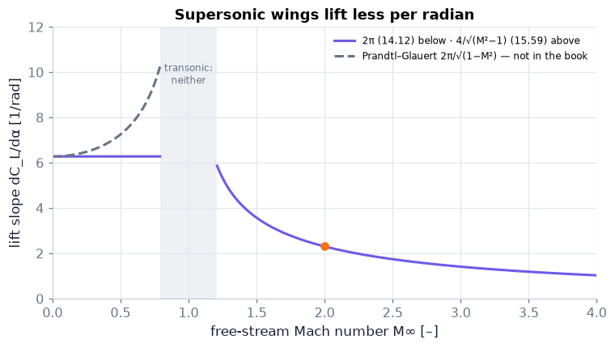

```
[6.2832 2.3094] 1.1854470610572836
```

```python
M = np.linspace(0.0, 4.0, 401)                                # free-stream Mach numbers
fig, ax = plt.subplots(figsize=(6.8, 3.8))   # one panel
ax.plot(M, ch15.lift_slope_vs_mach(M), color=COLORS["accent"], lw=2, label="2π (14.12) below · 4/√(M²−1) (15.59) above")   # NaN in the gap
Msub = M[M < 0.8]                                              # subsonic part
ax.plot(Msub, 2 * np.pi / np.sqrt(1 - Msub**2), color=COLORS["muted"], ls="--", label="Prandtl–Glauert 2π/√(1−M²) — not in the book")
ax.axvspan(0.8, 1.2, color=COLORS["grid"], alpha=0.6)         # the transonic gap: neither theory
ax.text(1.0, 9.5, "transonic:\nneither", ha="center", fontsize=8, color=COLORS["muted"])
ax.plot(2.0, 4 / np.sqrt(3), "o", color=COLORS["orange"])     # our plate: 2.309
ax.set(xlim=(0, 4), ylim=(0, 12), xlabel="free-stream Mach number M∞ [–]", ylabel="lift slope dC_L/dα [1/rad]",
       title="Supersonic wings lift less per radian")
ax.legend(fontsize=8); savefig(fig, "ch15", "c16_lift_slope"); plt.show()
print(ch15.lift_slope_vs_mach(np.array([0.5, 2.0])), np.sqrt(1 + (4 / (2 * np.pi))**2))   # 2π, 2.309; the slopes would be equal at 1.185
```

**What you see.** The lift slope per radian against the Mach number: 2π of $C_L\simeq2\pi(\alpha+\beta)$ (14.12) on the subsonic side (with the Prandtl–Glauert correction, not in the book, dashed), $4/\sqrt{M_\infty^2-1}$ of $C_L\cong\dfrac{4\alpha}{\sqrt{M_\infty^2-1}},\ \ C_D\cong\dfrac{4\alpha^2}{\sqrt{M_\infty^2-1}}$ (15.59) on the supersonic side, and a gap around Mach 1.

**How to read it.** At Mach 2 the slope is 2.31 per radian — 37 % of the low-speed 2π. The two theories would give the same slope at Mach 1.185, but both fail near Mach 1 (the shaded band), where the flow is a mixture of the two kinds.

**What would change if…** …$M_\infty$ were 1.1? The linear theory would promise a slope of 8.7 per radian — above 2π — because $\sqrt{M^2-1}\to0$; that is the theory failing, not the wing improving.

📝 **Note.** **N112 [B]** (Ours; result given, not derived.) A thin section of any shape: $C_p=\pm\dfrac{2\theta}{\sqrt{M_\infty^2-1}},\ \ C_D=\dfrac{4}{\sqrt{M_\infty^2-1}}\left[\alpha^2+\overline{\theta_c^2}+\overline{\theta_t^2}\right]$ (ours), where θ is the local surface slope and the bars are chord averages of the squared camber-line and thickness slopes. **Lift depends on the incidence only; thickness and camber buy nothing but drag.**

```python
yu = lambda x: 0.025 * (1 - np.abs(2 * x - 1))                # a 5 % diamond: half-thickness 0.025 c at mid-chord
yl = lambda x: -yu(x)                                         # symmetric lower surface
dia = ch15.ackeret_airfoil(yu, yl, 0.0, 2.0)                  # linear theory for any thin shape, at zero incidence
print(round(dia["CL"], 6), round(dia["CD"], 6), round(dia["CD_thickness"], 6), 4 * 0.05**2 / np.sqrt(3))   # 0, 0.00577 (about twice the 2° plate's 0.00281: the diamond's slopes are 2.86°), no lift
```

```
0.0 0.005772 0.005772 0.005773502691896259
```

📝 **Note.** **N113 [C]** Supersonic sections are thin with sharp leading edges; a rounded nose brings the detached shock of N99 (C14) and its drag.

```python
alphas = np.deg2rad(np.linspace(0.0, 12.0, 25))               # incidences 0 … 12°
def exact_or_nan(a_, M, key):                                 # the exact coefficient, NaN once the lower shock detaches
    try:   # the exact method raises when the lower shock detaches
        return ch15.flat_plate_supersonic(a_, M, method="shock_expansion")[key]   # exact coefficient
    except ValueError:                                        # "detached: …"
        return np.nan   # nothing to plot
def plate_curves(M):                                          # four curves for one Mach number
    lin = [ch15.flat_plate_supersonic(a_, M, method="linear") for a_ in alphas]   # (15.59)
    ex = [(exact_or_nan(a_, M, "CL"), exact_or_nan(a_, M, "CD")) if a_ < GD.max_deflection(M)["delta_max"] else (np.nan, np.nan)   # exact (C_L, C_D)
          for a_ in alphas]                                   # exact pair, skipped beyond the largest turn
    return {"C_L linear (15.59)": (np.degrees(alphas), [d["CL"] for d in lin]),   # linear lift
            "C_L exact (shock–expansion)": (np.degrees(alphas), [e[0] for e in ex]),   # exact lift
            "10 C_D linear (15.59)": (np.degrees(alphas), [10 * d["CD"] for d in lin]),   # linear drag × 10
            "10 C_D exact": (np.degrees(alphas), [10 * e[1] for e in ex])}   # exact drag × 10
Ms = ([1.2, 1.5, 2.0, 2.5, 3.0, 4.0] if FAST else                                # Mach numbers on the slider; 2.0 (our plate) is one
      [1.2, 1.3, 1.4, 1.6, 1.8, 2.0, 2.25, 2.5, 2.75, 3.0, 3.5, 4.0])
fig = slider_figure(plate_curves, "M∞", Ms, xlabel="incidence α [°]", ylabel="coefficient [–]",   # slider over the Mach number
                    title="Linear theory against the exact plate (exact curves stop where the shock detaches)", yrange=[0, 2.5],   # the message
                    active=Ms.index(2.0))                     # open on Mach 2, the case read below
fig.show()   # display
```

[interactive chart not shown]

**Figure F9a.** Slider: the free-stream Mach number, from 1.2 to 4 (12 positions; it opens on Mach 2). Linear theory against the exact shock–expansion answer; the drag is multiplied by 10 to share the axis.

**What you see.** Lift and ten times the drag coefficient against incidence, linear and exact, for the chosen Mach number.

**How to read it.** At Mach 2 the pairs lie on top of each other up to about 6° and stay within a few per cent to 12°. Slide toward Mach 1.2: the curves steepen, the exact ones bend away early, and they stop where the lower shock detaches (about 4° at Mach 1.2).

**What would change if…** …you halved the incidence? Lift halves, drag quarters: $C_D=\alpha C_L$ — fly a supersonic wing at small α.

#### 🎮 Interactive: How can there be drag without friction?

**Why interactive rather than a static figure:** you tilt the plate: the fan and the shock swap sides at α = 0 and the force arrow, always normal to the plate, leans back by exactly α — the drag bar grows as α², the lift bar as α; seeing the two bars grow at different rates is the point.

Start with the **Walkthrough**; the **Explain** tab works every number out with your settings, and the **Derivation** tab (where there is one) steps through the same derivation as above. The incidence α is computed in radians and shown in degrees; b is the chord, and pressures are over the free-stream p∞.

**What to try:**

- Tilt from 0 to 10°: compare how the two bars grow.
- Slide $M_\infty$ toward 1: which bars run away?
- Switch to a diamond at zero incidence: drag without lift.

```python
show_viz("ch15", "supersonic_flat_plate")   # full-width explainer; ⤢ Full screen for more room
```

🎮 Interactive 9/9 How can there be drag without friction? Open alone ↗

[interactive chart not shown]

**What would change if…** …the "gas" were blood and the "duct" an elastic artery? The pulse is a pressure wave of exactly the kind C02 solved, $p'(x,t)=f(x-ct)+g(x+ct)$ (15.15), with a wave speed set by the wall — and a collapsible tube chokes like the nozzle of C09. Chapter 16.

*↪ **S01** The chapter's exercises are not reproduced. The results they hold are taught above: the initial-value form (N21), the particle velocity (D04), the small-Mach expansions (N32), the area ratio (D10), the weak shock (D17), the maximum speed (N38), the strong shock (R17), the two sets of differentials (D22, D23), the choked mass flow (D11), the choking limits (D24), the thin section (N112) and the oblique-shock components (D26). (Slips #16 and #17 concern the wording of one exercise and a loss quoted in another; nothing of either is published here.) **S02** Sources: the reference list at the end of the book's chapter; our public sources (NACA Report 1135 and the pages cited in the analysis) are in `reference/ch15/SOURCES.md`.*

## ✅ What should have clicked

- **C01** Sound is what the laws of mass and momentum become when the disturbance is weak: one wave equation $\dfrac1{c^2}\left(\dfrac{\partial}{\partial t}+U_j\dfrac{\partial}{\partial x_j}\right)^2p'-\dfrac{\partial^2p'}{\partial x_j\partial x_j}=0$ (15.12) with the speeds U ± c.
- **C02** Any plane sound is one shape going right plus one going left, $p'(x,t)=f(x-ct)+g(x+ct)$ (15.15); the air moves with a compression and against a rarefaction, $u_1'(x,t)=\dfrac1{\rho_0c}\left(f(x-ct)-g(x+ct)\right)$ (15.16).
- **C03** A duct flow is three budgets between two stations, and the energy budget $h_2+\tfrac12u_2^2-h_1-\tfrac12u_1^2=Q$ (15.22) holds even across friction and shocks.
- **C04** $\dfrac{T_0}{T}=1+\dfrac{\gamma-1}{2}M^2$ (15.28): $T_0$ is what an adiabatic flow keeps; $p_0$ is what it loses when entropy is made.
- **C05** The area a flow needs, $\dfrac{A}{A^*}=\dfrac1M\left[\dfrac{2}{\gamma+1}\left(1+\dfrac{\gamma-1}{2}M^2\right)\right]^{(1/2)(\gamma+1)/(\gamma-1)}$ (15.31), is least at Mach 1, so each area belongs to two Mach numbers and a throat passes only so much.
- **C06** Above Mach 1 the gas thins faster than it speeds up, so a supersonic nozzle widens: $\dfrac{du}{u}=-\dfrac{1}{1-M^2}\dfrac{dA}{A}$ (15.34).
- **C07** Across a shock the three laws leave one solution besides 'nothing', fixed by $M_1$ alone: $\dfrac{p_2}{p_1}=1+\dfrac{2\gamma}{\gamma+1}\left(M_1^2-1\right)$ (15.39).
- **C08** Only the supersonic-to-subsonic jump makes entropy, $\dfrac{S_2-S_1}{C_v}=\ln\left[\dfrac{p_2}{p_1}\left(\dfrac{\rho_1}{\rho_2}\right)^{\gamma}\right]$ (15.43); its price is stagnation pressure.
- **C09** When the exit is sonic the nozzle cannot hear the back pressure and the mass flow stops rising at $\dot m_{\max}=p_0A^*\sqrt{\dfrac{\gamma}{RT_0}}\left(\dfrac{2}{\gamma+1}\right)^{(\gamma+1)/(2(\gamma-1))}$ (ours).
- **C10** With a sonic throat the back pressure only chooses where a shock stands.
- **C11** Friction and heat in a straight duct reduce to one number A and a quadratic for $M_2^2$: $M_2^2=\dfrac{-(1-2A\gamma)\pm\left[1-2A(\gamma+1)\right]^{1/2}}{(\gamma-1)-2A\gamma^2}$ (15.46).
- **C12** The same $1-M^2$ makes friction and heat push every duct flow toward Mach 1 and choke it: $-\dfrac{dp}{p_1}=\dfrac{1+(\gamma-1)M^2}{1-M^2}\,df,\ \ \dfrac{du}{u}=-\dfrac{d\rho}{\rho}=\dfrac{p_1}{p}\dfrac{df}{1-M^2}$ (15.47, numerator sign corrected), $\dfrac{dT}{T_1}=\left(\dfrac{1-\gamma M^2}{1-M^2}\right)dq,\ \ \dfrac{u\,du}{h_1}=\dfrac{(\gamma-1)M^2}{1-M^2}\,dq$ (15.48, second relation's sign corrected).
- **C13** The Mach cone is the edge of all the circles of old news: $\sin\mu=1/M$ (15.49).
- **C14** An oblique shock is a normal shock on the normal component, $\tan\delta=2\cot\sigma\,\dfrac{M_1^2\sin^2\sigma-1}{M_1^2(\gamma+\cos2\sigma)+2}$ (15.53): two shocks per turn, a largest turn.
- **C15** A supersonic stream turns away through a fan, and $\nu(M)=\sqrt{\dfrac{\gamma+1}{\gamma-1}}\tan^{-1}\sqrt{\dfrac{\gamma-1}{\gamma+1}\left(M^2-1\right)}-\tan^{-1}\sqrt{M^2-1}$ (15.56) keeps the count.
- **C16** On a thin plate the push is normal to the plate, so lift costs α times itself in wave drag: $C_L\cong\dfrac{4\alpha}{\sqrt{M_\infty^2-1}},\ \ C_D\cong\dfrac{4\alpha^2}{\sqrt{M_\infty^2-1}}$ (15.59).

**What later chapters build on**

- Ch. 16 — pulse waves in arteries are $p'(x,t)=f(x-ct)+g(x+ct)$ (15.15) with a wall-compliance wave speed; flow limitation in collapsible tubes is choking (C09) with a tube law in place of the gas law.

**Not taught here (and where to find it)**

- the 1-D Euler solver through breaking (N114; the backup explainer)
- the shock-structure derivations (stated only: N66–N69)
- the Riemann-invariant derivation (N22)
- non-perfect gases and expansion shocks (N90)
- the method of characteristics in two dimensions

← All chapters

← PreviousNext →

Code and explanations: shammun/fluidpy (MIT). The book is not reproduced here; equations are cited by number.